# Group Modeling: PBS Utah Major Donor Prediction

Authors

Erin Bednarik

Benjamin Hogan

Samantha Huang

Kate Klinger

Published

November 11, 2026

## 1 Introduction

### 1.1 Business Problem

Congress eliminated federal funding for public broadcasting in 2025, leaving PBS Utah with an estimated recurring shortfall of about $2 million per year. Major donors, who give $1,200 or more in a fiscal year, are about 0.3% of donors but give about 8% of individual donor revenue. PBS Utah has no reliable, data-driven way to find which current non-major donors are most likely to become major donors, or at what giving level. Its major gift officers also want to know which current major donors are at risk of dropping below $1,200, since about 57% of major donors in the course data fall below that level the following year.

The project delivers two ranked lists that development staff can work through: a prospect list of non-major donors most likely to become major donors, split into an immediate-priority segment (12 months) and a long-term nurture segment (3 to 5 years), and a risk list of current major donors most likely to drop. The officer cultivation program can work about 1,000 donors a year, so that is the list size the prospect model is first judged at; the list-size curve later in the notebook treats the size as something to read off the data rather than assume.

### 1.2 Analytic Problem

The setup follows the group EDA and the revised business problem statement.

- **Unit of analysis.** One person at the end of fiscal year t (June 30), a donor-year. A donor-year is eligible for the prospect list if the person gave in FY t and was not a major donor in FY t. Former major donors stay in and are flagged. Every feature uses only information dated on or before June 30 of FY t.
- **Primary target.** Becoming a major donor in FY t+1: $1,200 or more of the person’s own giving and soft credits, or a couple reaching $1,200 together.
- **Secondary targets.** Becoming a major donor within 3 and within 5 years, the giving tier reached in the conversion year ($1,200, $2,000, or $5,000 and up), and, for current major donors, falling below $1,200 the next year.
- **A rare outcome.** The FY2022 to FY2024 test cohorts each hold about 31,000 to 33,000 eligible donors but only 134 converters between them, 59 of whom had never been major donors. Predicting “no” for everyone would be more than 99.8% accurate, so models are judged on how well they rank, not on accuracy.
- **Success measure.** Recall at a list of 1,000: the share of next-year converters on each year’s list, with precision, lift, and calibration alongside, for all eligible donors and for never-major donors.
- **The bar.** Ranking donors by their FY t giving already puts 75.4% of test-cohort converters in the top 1,000, and 59.6% of never-major converters. A model has to beat that ranking and also clear a simple rule that lists every former major donor and everyone who gave $500 or more. After the first draft, a third bar was added: the best list an officer could build by hand, former major donors first and then last year’s giving with ties broken by years of giving (decision D23).

### 1.3 About the Data

The course data are a synthetic release built to follow the structure of PBS Utah’s donor systems, and most of its tables were generated from PBS Utah’s records. Results from this data validate methods, not findings about PBS Utah’s donors. We present every result as evidence that a method works and every recommendation as a test PBS Utah can run on its own records. The data release notes list four differences that matter for modeling:

- **The cultivation and officer portfolio tables were invented** as a proof of concept for records PBS Utah could begin keeping. Simulated contact was written into the outcome and shifts conversion toward donors selected for cultivation from FY2023 on, which overlaps our test years. We therefore also report results for donors not selected for cultivation and for cohorts before the program, and we treat the officer-selection benchmark as illustrative.
- **Age has no planted relationship** with conversion, so the model’s age term says nothing about PBS Utah’s donors.
- **Second one-time gifts within a year** occur at about twice PBS Utah’s rate, which affects how a year’s largest gift relates to its total.
- **The move from the legacy system to Unite** falls at FY2021 here but in May 2020 in PBS Utah’s records, so the era rules in Data Preparation would need resetting on the real data.

### 1.4 Purpose of This Notebook

Each of us completed an individual modeling notebook. All four reached a penalized logistic regression or a simple ranking, but on different populations, training windows, and test designs, so their headline numbers could not be compared. We compared the four, agreed on the 22 decisions below, and this notebook applies them in a single pass on the group EDA’s shared data. It brings in the strongest piece of each individual notebook:

- **Erin:** the untuned logistic regression as the simplest candidate, the breakdown of each list into former and never-major donors, and a saved model that always scores with the contact flags switched off.
- **Benjamin:** the validation code, the practice of setting decision rules before results, the checks prompted by the data release notes, the 3 and 5 year projections, and the tier comparison.
- **Kate:** log-dollar and giving-band features for the $600 cluster, the 3-year total benchmark, the count of converters each list finds that the other misses, the two-level tier indicator, and the coverage audit of the final list.
- **Samantha:** the tuned ridge regression, the separate retention workflow, and its evaluation at the list sizes officers can work.

The individual notebooks remain in each member’s repository. The appendix describes the team’s use of AI tools and each member’s contributions.

**What this notebook is for.** The data are synthetic, so no number in it is a fact about PBS Utah’s donors. What it hands PBS Utah is a procedure: a way to find out, on its own records, whether a model improves on what staff could do without one, how long each list should be, and which call to make next. Every result below is a worked example of that procedure. After the first complete draft, our instructor’s review led to six amendments (decisions D23 to D28), each dated and handled under the rules we set in advance: a stronger rule as the bar for each list, a ranking by expected dollars, the list size read off a curve of return against size for prospects and for retention, and the two curves side by side in dollars per name. On this release the rules did as well as the models at every job, and the notebook says so. That is the finding that travels, because the same procedure on real data will say whichever is true there.

### 1.5 Agreed Decisions

The group EDA’s fifteen decisions carry over unchanged. The table lists the decisions we added or settled for modeling, each explained where it first matters.

Modeling decisions added to the group EDA’s fifteen

| # | Topic | Agreed rule |
| --- | --- | --- |
| D1 | Data build | The group EDA’s shared build script for every model |
| D2 | Household rule | A couple reaching $1,200 only together counts as one major donor, as confirmed by PBS Utah |
| D3 | Eligible donors | Gave in FY t and not major; former majors flagged; lapsed donors reported separately |
| D4 | Ties at the cutoff | Split evenly, so results do not depend on row order |
| D5 | Main test | Rolling FY2022 to FY2024; FY2025 checked once after the model is chosen, then added to final training |
| D6 | Pre-program check | FY2018 to FY2021, before the cultivation program, reported but not used to choose |
| D7 | Training window | FY2021 onward; FY2014 onward as a sensitivity check |
| D8 | How a model wins | Paired couple-clustered bootstrap; a more complex model must show a gain whose 95% interval is above zero |
| D9 | Prospect model | The four logistic variants compared under one rule set in advance |
| D10 | Inputs | Backtested with all inputs; final model on the giving-history use list unless more inputs win |
| D11 | Contact flags | Used in training only and switched off when scoring |
| D12 | Reporting groups | All eligible, never-major, no-contact, and donors not selected for cultivation |
| D13 | Benchmarks | Prior-year giving (the bar), former major or $500, RFV, threshold rules, a 3-year total ranking, random, and officer selection (illustrative) |
| D14 | Framing | Results are methods to validate on PBS Utah’s records |
| D15 | 3 to 5 year outcome | Giving-history models on earlier cohorts, reported as projections |
| D16 | Giving tier | Three tiers scored exact and within one; displayed as an expected mix with a two-level indicator |
| D17 | Calibration | Reported, with an expected-converter range for staff |
| D18 | Dashboard segments | Immediate priority: top 1,000 by the 12 month model. Long-term nurture: ranked by the 3 to 5 year model |
| D19 | Retention | A risk ranking of current major donors with dollars at risk, as a second workflow |
| D20 | Former major donors | Kept in the prospect model and reported separately |
| D21 | Final model | Saved, checked, and always scored with the contact flags switched off |
| D22 | Households in the list | Person-level list with a couple flag |
| D23 | Officer rule benchmark (amendment, November 11) | Former major donors first, then everyone else by FY t giving, ties broken by years with a gift: the best list an officer could build unaided. Reported against the bar and the selected model under the … |
| D24 | Retention rule benchmark (amendment, November 11) | First-time major donors first, then the lowest givers: the best stewardship list an officer could build unaided. Reported against the R6 benchmark and the risk model under the same paired test at 25 a… |
| D28 | The next call (amendment, November 11) | Both lists in dollars per name worked, block by block, with the retention side at several save rates, so officer time can be ordered across the two lists |
| D27 | Retention curve (amendment, November 11) | Droppers and next-year giving lost, accumulated along each stewardship ranking, including dollars at risk from the model and from a tenure lookup table, so stewardship capacity is read off the same ki… |
| D26 | List size as an output (amendment, November 11) | Converters and conversion-year dollars accumulated along each ranking’s list, with the marginal return per 250 names, on the test and pre-program cohorts, so PBS Utah can set the list size where the r… |
| D25 | Ranking by expected giving (amendment, November 11) | Probability times the expected conversion-year giving of past converters in the same prior-year band, as expected increase (minus current giving) and expected total, compared with the probability rank… |

### 1.6 Rules Set Before the Results

With only 134 test converters, a few lucky hits can separate two models, and it is easy to choose an option after seeing which one looks best. We wrote these rules before running any comparison, including what happens when the results cannot tell the options apart.

Decision rules written before any comparison was run

| Rule | Covers | Rule as written |
| --- | --- | --- |
| R1 | Prospect model | Candidates in order of simplicity: untuned L2 logistic regression, tuned L2 (ridge), tuned L1, tuned L2 with log-dollar and giving-band terms, then tree models as a reference. Start from the simplest.… |
| R2 | Inputs | The final model uses the giving-history use list unless the version with all inputs wins under the R1 test. |
| R3 | Checks | The FY2025 check, the pre-program test, the not-selected group, the FY2014 window, and the version without contact flags are reported and cannot change the model. |
| R4 | 3 and 5 year outcomes | The selected model’s family is reported; an explainable boosting machine replaces it only under the R1 test. |
| R5 | Giving tier | The most-common-tier rule stands unless a more complex approach’s gain in exact accuracy has a 95% interval above zero. |
| R6 | Retention | The risk model is recommended only if it beats ranking the lowest givers first on paired draws at the top 25 donors per year. The top 50 and ROC AUC are reported alongside. |
| R7 | Calibration | Probabilities are recalibrated only if the pooled ratio of predicted to observed conversions on the test cohorts falls outside 0.8 to 1.25. Staff always see a range of expected converters. |

**Amendments after the results.** After the first complete draft, our instructor asked whether prior-year giving is really the most a development officer could do without a model, and suggested a stronger rule (decision D23). The same question applies to retention, where the R6 benchmark was the lowest givers first, so a stronger stewardship rule was added too (decision D24). He also asked that the lists be ordered by expected dollars rather than probability alone (decision D25), and that the list size be read off a curve of return against list size rather than fixed at 1,000 (decision D26), with the same curve for retention (decision D27) and the two put side by side in dollars per name (decision D28). Adding a benchmark after seeing the results is exactly what the rules above guard against, so the amendment is handled in the open: it is dated, it is reported with the same paired test as every other comparison, and it cannot change which model was selected under R1. If the selected model does not measurably beat the rule, the rule is the recommendation, in the spirit of R1, where the simpler option stays unless something beats it.

## 2 Data Preparation

```python
import sys
import time
from pathlib import Path

import numpy as np
import pandas as pd
import polars as pl
from plotnine import *

# the shared build script lives one folder up, next to the group EDA
sys.path.insert(0, str(Path("..").resolve()))
import build_panel as bp

RAW = Path("../../tables")      # the course data release, outside the repository
CACHE = Path("../data_cache")    # the same Parquet cache the group EDA uses

build_start = time.perf_counter()
raw = bp.load_tables(RAW, CACHE)                 # raw tables, typed and snake-cased
clean, audit = bp.clean_tables(raw)              # the agreed cleaning rules
del raw                                          # only the cleaned tables are used from here; frees about 0.8 GB
person_years = bp.build_person_years(clean)      # one row per person per fiscal year, household rule applied
cohorts = bp.build_cohorts(person_years)         # eligible and lapsed donors at each snapshot
build_seconds = time.perf_counter() - build_start

# formatting helpers for numbers written into the text
def n(x):
    return f"{x:,.0f}"

def pct(x, d=1):
    return f"{100 * x:.{d}f}%"

def pp(x, d=1):
    # a difference between two shares, in percentage points (a rounded zero shows without a minus sign)
    out = f"{100 * x:.{d}f}"
    return out[1:] if out.startswith("-") and float(out) == 0 else out

def fixed_fmt(v, d):
    # a number with d decimals, without a minus sign on a rounded zero
    out = f"{v:,.{d}f}"
    return out[1:] if out.startswith("-") and float(out.replace(",", "")) == 0 else out

def usd(x):
    return f"${x:,.0f}"

HEADER_NAMES = {"t": "FY t", "fy": "FY", "n_unique": "Distinct values"}
HEADER_WORDS = (("_fy_t_", "_FY t_"), ("_fy_", "_FY_"), ("_auc_", "_AUC_"), ("_rfv_", "_RFV_"), ("_ci_", "_CI_"))

def readable(col):
    # snake_case column name to a readable table header
    if col in HEADER_NAMES:
        return HEADER_NAMES[col]
    text = f"_{col}_"
    for old, new in HEADER_WORDS:
        text = text.replace(old, new)
    text = text.strip("_").replace("_", " ")
    return text[0].upper() + text[1:]

def show(df, pct_cols=(), pct_digits=1, caption=None, digits=2, fixed=None):
    # render a polars frame as a captioned html table, keeping year columns free of separators;
    # fixed maps a column to its own number of decimals when it differs from digits
    out = df.with_columns([
        pl.col(c).map_elements(lambda v: f"{100 * v:.{pct_digits}f}%", return_dtype=pl.String) for c in pct_cols
    ] + [pl.col(c).map_elements(lambda v, d=d: fixed_fmt(v, d), return_dtype=pl.String) for c, d in (fixed or {}).items()])
    year_cols = ("fy", "t", "cohort", "test_cohort", "first_training_cohort", "last_training_cohort")
    out = out.with_columns([pl.col(c).cast(pl.String) for c in out.columns if c in year_cols])
    out = out.rename({c: readable(c) for c in out.columns})
    int_cols = [c for c, dt in out.schema.items() if dt.is_integer()]
    frame_pd = out.to_pandas()
    frame_pd[int_cols] = frame_pd[int_cols].astype("Int64")   # keep whole numbers whole when a column has gaps
    styled = frame_pd.style.format(thousands=",", precision=digits, na_rep="").hide(axis="index")
    return styled.set_caption(caption) if caption else styled

_ = theme_set(theme_minimal() + theme(figure_size=(8, 4)))  # assign so the old theme is not printed
```

The shared build produces 572,487 person-years and 2,209,529 cohort rows in 7 seconds, the same panel the group EDA uses.

### 2.1 Feature Table

The models need one row per eligible donor-year with every feature measured at June 30 of FY t. The eligible donors at a given FY t are the same for every outcome window, so we keep one row per donor-year and store the 12 month, 3 year, and 5 year outcomes as separate target columns, left empty when a window runs past FY2026. Lapsed donors are left out, as decision 2 of the group EDA set. We build every cohort from FY1999, not only the FY2021 onward window the main model trains on, because the pre-program check and the longer outcomes need earlier cohorts. The FY2026 donors are built the same way, without outcomes, for the lists in the last section.

Each step below is written as a function of the cleaned tables, so the leakage check at the end of this section can rerun the same code on data cut back to an earlier date.

```python
ENGAGEMENT_START = 2021   # first fiscal year of solicitation, Passport, and soft credit records
UNITE_START = 2021        # first fiscal year of Unite payments; legacy gifts end in FY2020
SNAPSHOT_FY = 2026        # the constituent snapshot (age) describes FY2026

def base_features(rows, clean, py):
    """Giving history, solicitation, Passport, constituent fields, and cultivation flags at June 30 of FY t."""
    gifts = bp.individual_gifts(clean)
    rows = (
        rows.join(bp.giving_features(rows, py, gifts), on=["constituent_id", "t"], how="left")
        .with_columns(change_from_last_year=pl.col("prior_total") - pl.col("prev_total"),
                      largest_gift_share=pl.col("largest_gift_t") / pl.col("prior_total"))
        .drop("recurring_amt", "recurring_payments")
    )
    # solicitation and Passport records start in FY2021, so earlier cohorts are missing, not zero
    sol = bp.solicitation_features(rows, bp.solicitation_by_year(clean))
    pas = bp.passport_features(rows, clean["passport"])
    engagement = [c for c in sol.columns + pas.columns if c not in ("constituent_id", "t")]
    rows = (rows.join(sol, on=["constituent_id", "t"], how="left").join(pas, on=["constituent_id", "t"], how="left")
            .with_columns([pl.when(pl.col("t") >= ENGAGEMENT_START).then(pl.col(c)).alias(c) for c in engagement]))
    # constituent fields the group EDA kept, with the snapshot age shifted back to FY t
    con = clean["constituents"].select("constituent_id", "age", "gender", "address_state", "spouse_constituent_id",
                                       "primary_constituent_type")
    rows = rows.join(con, on="constituent_id", how="left").with_columns(
        age_at_t=pl.col("age") - (SNAPSHOT_FY - pl.col("t")),
        gender=pl.col("gender").fill_null("Unknown"),
        lives_in_utah=pl.col("address_state") == "UT",
        spouse_on_file=pl.col("spouse_constituent_id").is_not_null(),
    ).drop("age", "address_state", "spouse_constituent_id", "primary_constituent_type")
    # cultivation: selected in FY t, then contacted or held out during FY t+1
    cult = clean["cultivation"].select(constituent_id="synthetic_id", t="fiscal_year", cult_contacted="contacted")
    assert cult.select("constituent_id", "t").is_unique().all()
    return rows.join(cult, on=["constituent_id", "t"], how="left").with_columns(
        selected=pl.col("cult_contacted").is_not_null(),
        contacted=pl.col("cult_contacted").fill_null(False),
        held_out=pl.col("cult_contacted").is_not_null() & ~pl.col("cult_contacted").fill_null(True),
    ).drop("cult_contacted")

def gift_flags_by_year(clean, py):
    """Sustaining and gift-type flags per person-year from Unite (FY2021 on) and from the legacy system (before)."""
    unite = py.filter(pl.col("fy") >= UNITE_START).select(
        "constituent_id", "fy", sustainer_y=pl.col("recurring_payments") > 0,
        monthly_y=pl.when(pl.col("recurring_payments") > 0).then(pl.col("recurring_amt") / pl.col("recurring_payments")),
        upgrade_y="upgrade_gift", additional_y="additional_gift")
    legacy = (clean["legacy"].with_columns(fy=bp.fiscal_year("gift_date"), sustaining=pl.col("gift_kind") == "Sustaining")
              .group_by(constituent_id="constituent_id_1", fy="fy")
              .agg(sustainer_y=pl.col("sustaining").any(),
                   monthly_y=pl.col("payment_amount").filter(pl.col("sustaining")).mean(),
                   upgrade_y=(pl.col("gift_type") == "Upgrade").any(),
                   additional_y=(pl.col("gift_type") == "Additional").any()))
    flags = pl.concat([unite, legacy], how="vertical_relaxed")
    assert flags.select("constituent_id", "fy").is_unique().all()
    return flags

def era_features(rows, clean, py):
    """Sustainer and gift-type features from both gift systems; soft credits missing where not yet recorded."""
    flags = gift_flags_by_year(clean, py)
    prev = flags.select("constituent_id", t=pl.col("fy") + 1, sustainer_prev="sustainer_y")
    return (
        rows.drop("sustainer", "monthly_amount", "upgrade_gift", "additional_gift")
        .join(flags.rename({"fy": "t"}), on=["constituent_id", "t"], how="left")
        .join(prev, on=["constituent_id", "t"], how="left")
        .with_columns(
            sustainer=pl.col("sustainer_y").fill_null(False),
            monthly_amount=pl.col("monthly_y"),
            upgrade_gift=pl.col("upgrade_y").fill_null(False),
            additional_gift=pl.col("additional_y").fill_null(False),
            new_sustainer=pl.col("sustainer_y").fill_null(False) & ~pl.col("sustainer_prev").fill_null(False),
            soft_in_t=pl.when(pl.col("t") >= UNITE_START).then(pl.col("soft_in_t")),
            soft_before=pl.when(pl.col("t") > UNITE_START).then(pl.col("soft_before")),
        )
        .drop("sustainer_y", "monthly_y", "upgrade_y", "additional_y", "sustainer_prev")
    )

GIVING_BANDS = [(100, 250), (250, 600), (600, 1200)]   # Kate's bands; under $100 is the reference

def engineered_features(rows, clean, py):
    """Former-major detail, lifetime giving, giving bands, couple giving, and recency."""
    keys = rows.select("constituent_id", "t")
    history = (keys.join(py.select("constituent_id", "fy", "total", "major"), on="constituent_id", how="inner")
               .filter(pl.col("fy") < pl.col("t"))
               .group_by("constituent_id", "t")
               .agg(major_years_before=pl.col("major").sum(),
                    last_major_fy=pl.col("fy").filter(pl.col("major")).max(),
                    largest_total_before=pl.col("total").max(),
                    lifetime_before=pl.col("total").sum(),
                    years_ever_given=(pl.col("total") > 0).sum()))
    late_gift = (bp.individual_gifts(clean).filter(pl.col("date").dt.month().is_in([4, 5, 6]))
                 .select("constituent_id", t=bp.fiscal_year("date")).unique().with_columns(gift_last_quarter=pl.lit(True)))
    spouse = py.select("constituent_id", t="fy", spouse_total_t="spouse_total")
    return (
        rows.join(history, on=["constituent_id", "t"], how="left")
        .join(late_gift, on=["constituent_id", "t"], how="left")
        .join(spouse, on=["constituent_id", "t"], how="left")
        .with_columns(
            major_years_before=pl.col("major_years_before").fill_null(0).cast(pl.Int64),
            years_since_last_major=pl.col("t") - pl.col("last_major_fy"),
            largest_total_before=pl.col("largest_total_before").fill_null(0.0),
            lifetime_giving=pl.col("lifetime_before").fill_null(0.0) + pl.col("prior_total"),
            years_ever_given=pl.col("years_ever_given").fill_null(0).cast(pl.Int64) + 1,
            spouse_total_t=pl.col("spouse_total_t").fill_null(0.0),
            gift_last_quarter=pl.col("gift_last_quarter").fill_null(False),
            **{f"band_{lo}_{hi - 1}": pl.col("prior_total").is_between(lo, hi, closed="left") for lo, hi in GIVING_BANDS},
        )
        .with_columns(
            couple_total_t=pl.col("prior_total") + pl.col("spouse_total_t"),
            # a sustainer's recent payment reflects the payment schedule, which differs between the two systems
            gift_last_quarter=pl.when(~pl.col("sustainer")).then(pl.col("gift_last_quarter")),
            days_since_last_gift=pl.when(~pl.col("sustainer")).then(pl.col("days_since_last_gift")),
        )
        .drop("last_major_fy", "lifetime_before")
    )

def known_zeros(rows):
    """From FY2021 on, no Passport record means no titles or genres viewed; the record flag marks it."""
    return rows.with_columns([pl.when((pl.col("t") >= ENGAGEMENT_START) & pl.col(c).is_null()).then(0).otherwise(pl.col(c)).alias(c)
                              for c in ("titles", "genres")])

def build_features(rows, clean, py):
    for step in (base_features, era_features, engineered_features):
        rows = step(rows, clean, py)
    return known_zeros(rows).sort("t", "constituent_id")
```

```python
active = cohorts.filter(pl.col("segment") == "active")
rows = active.filter(pl.col("window") == 1).select("constituent_id", "couple_id", "t", "prior_total", "former_major", y_12m="converted")
for w, name in ((3, "y_3yr"), (5, "y_5yr")):
    rows = rows.join(active.filter(pl.col("window") == w).select("constituent_id", "t", pl.col("converted").alias(name)),
                     on=["constituent_id", "t"], how="left")
frame = build_features(rows, clean, person_years)
assert frame.height == rows.height and frame.select("constituent_id", "t").is_unique().all()
assert (frame["contacted"] & frame["held_out"]).sum() == 0
assert ((frame["major_years_before"] > 0) == frame["former_major"]).all()   # agrees with the shared build's flag

# FY2026 donors, built the same way, for the lists at the end (no outcome yet)
earlier_major = person_years.filter(pl.col("major") & (pl.col("fy") < 2026))["constituent_id"].implode()
rows_2026 = (person_years.filter((pl.col("fy") == 2026) & ~pl.col("major"))
             .select("constituent_id", "couple_id", t=pl.lit(2026, dtype=pl.Int32), prior_total="total")
             .with_columns(former_major=pl.col("constituent_id").is_in(earlier_major)))
frame_2026 = build_features(rows_2026, clean, person_years)
assert frame_2026.height == rows_2026.height

ERAS = ["FY1999 to FY2013", "FY2014 to FY2020", "FY2021 (training)", "FY2022 to FY2024 (test)", "FY2025 (check)", "FY2026 (to score)"]
era = (pl.when(pl.col("t") < 2014).then(pl.lit(ERAS[0])).when(pl.col("t") < 2021).then(pl.lit(ERAS[1]))
       .when(pl.col("t") == 2021).then(pl.lit(ERAS[2])).when(pl.col("t") <= 2024).then(pl.lit(ERAS[3]))
       .when(pl.col("t") == 2025).then(pl.lit(ERAS[4])).otherwise(pl.lit(ERAS[5])).cast(pl.Enum(ERAS)))
era_table = (
    pl.concat([frame, frame_2026], how="diagonal_relaxed").group_by(era=era)
    .agg(cohorts=pl.col("t").n_unique(), donor_years=pl.len(),
         # blank, not zero, where the outcome window has not closed
         **{name: pl.when(pl.col(col).is_not_null().any()).then(expr.sum())
            for name, col, expr in (("converters_12m", "y_12m", pl.col("y_12m")),
                                    ("never_major_12m", "y_12m", pl.col("y_12m") & ~pl.col("former_major")),
                                    ("converters_3yr", "y_3yr", pl.col("y_3yr")),
                                    ("converters_5yr", "y_5yr", pl.col("y_5yr")))},
         has_engagement=pl.col("solicitations").is_not_null().mean())
    .sort("era")
)
et = {r["era"]: r for r in era_table.iter_rows(named=True)}
show(era_table, pct_cols=["has_engagement"], pct_digits=0,
     caption="Donor-years by period: converters at each outcome window and engagement coverage")
```

Table 1: Donor-years by period: converters at each outcome window and engagement coverage

| Era | Cohorts | Donor years | Converters 12m | Never major 12m | Converters 3yr | Converters 5yr | Has engagement |
| --- | --- | --- | --- | --- | --- | --- | --- |
| FY1999 to FY2013 | 15 | 225,196 | 246 | 151 | 552 | 763 | 0% |
| FY2014 to FY2020 | 7 | 145,766 | 276 | 167 | 672 | 923 | 0% |
| FY2021 (training) | 1 | 30,843 | 55 | 29 | 114 | 169 | 100% |
| FY2022 to FY2024 (test) | 3 | 97,190 | 134 | 59 | 229 |  | 100% |
| FY2025 (check) | 1 | 32,886 | 81 | 44 |  |  | 100% |
| FY2026 (to score) | 1 | 38,219 |  |  |  |  | 100% |

The table holds 531,881 donor-years with outcomes and 38,219 FY2026 donors to score. The main model trains from FY2021, where every input exists. The FY2014 to FY2020 cohorts serve the training window sensitivity and the pre-program test, and the cohorts back to FY1999 serve the 3 and 5 year outcomes, which need training years whose long windows had closed.

### 2.2 Two Gift Systems

Gifts before FY2021 come from the legacy system and later gifts from Unite. The shared build takes sustainer status, the monthly sustainer amount, and upgrade and additional gifts from Unite only, which was all the group EDA needed. For the earlier cohorts used here, those features would read “no” for every donor. The legacy table records the same things (each gift is one-time or sustaining, and its type includes upgrades and additional gifts), so `era_features` rebuilds them from both systems. Soft credits only exist from FY2021, so they are left missing where they could not have been recorded. A new-sustainer flag (sustaining in FY t but not FY t-1) is added; it does not use payment counts, since legacy sustainers show two to six payments a year and Unite sustainers eleven or twelve.

```python
# the Unite part of the rebuilt features must equal the shared build's own features
own = bp.giving_features(frame.filter(pl.col("t") >= UNITE_START), person_years, bp.individual_gifts(clean))
check = frame.filter(pl.col("t") >= UNITE_START).join(own.select("constituent_id", "t", "recurring_payments", "upgrade_gift", "additional_gift"),
                                                      on=["constituent_id", "t"], suffix="_build")
assert (check["sustainer"] == (check["recurring_payments"].fill_null(0) > 0)).all()
assert (check["upgrade_gift"] == check["upgrade_gift_build"].fill_null(False)).all()
assert (check["additional_gift"] == check["additional_gift_build"].fill_null(False)).all()

by_era = (frame.group_by(system=pl.when(pl.col("t") < UNITE_START).then(pl.lit("legacy, FY1999 to FY2020")).otherwise(pl.lit("Unite, FY2021 to FY2025")))
          .agg(sustainer=pl.col("sustainer").mean(), median_monthly_amount=pl.col("monthly_amount").median(),
               upgrade_gift=pl.col("upgrade_gift").mean(), additional_gift=pl.col("additional_gift").mean())
          .sort("system"))
sust_t = dict(frame.group_by("t").agg(pl.col("sustainer").mean()).iter_rows())
show(by_era, pct_cols=["sustainer", "upgrade_gift", "additional_gift"], caption="Sustaining and gift-type features in the two gift systems")
```

Table 2: Sustaining and gift-type features in the two gift systems

| System | Sustainer | Median monthly amount | Upgrade gift | Additional gift |
| --- | --- | --- | --- | --- |
| Unite, FY2021 to FY2025 | 65.2% | 6.00 | 2.1% | 16.4% |
| legacy, FY1999 to FY2020 | 33.5% | 6.00 | 2.1% | 18.9% |

The rebuilt Unite values match the shared build exactly. The two systems agree where the concepts overlap, with the same median monthly amount and a similar share of upgrade gifts. The share of donors who sustain is lower in the legacy era overall, but it grows steadily, from 14% in FY1999 to 62% in FY2020 and 69% in FY2025, with no jump at the switch. Recency is left empty for sustainers in every year, because a sustainer’s recent payment follows the payment schedule, and the two systems record that schedule differently.

### 2.3 Feature Groups

The registry below lists every feature with its group and its status. The status follows the group EDA’s feature table: “use” features form the main input set, “test” features are the ones the EDA expected to add little, “engineered” features are added here, and the cultivation flags are used in training only. Constituent type, which the EDA reserved for a sensitivity check, is left out, and so are the snapshot fields the EDA found to encode later giving.

```python
FEATURES = {
    # the group EDA's use list
    "prior_total": ("giving history", "use", "Giving in FY t: own payments, soft credits, and legacy gifts"),
    "former_major": ("giving history", "use", "Major donor in any earlier fiscal year"),
    "years_last5": ("giving history", "use", "Fiscal years with a gift, FY t-4 to FY t"),
    "years_since_first_gift": ("giving history", "use", "Years from the first fiscal year with a gift to FY t"),
    "legacy_years": ("giving history", "use", "Fiscal years with a legacy-system gift"),
    "change_from_last_year": ("giving history", "use", "FY t giving minus FY t-1 giving"),
    "two_years_before": ("giving history", "use", "Total giving in FY t-2 and FY t-1"),
    "largest_gift_share": ("giving history", "use", "Largest single gift as a share of FY t giving"),
    "sustainer": ("giving history", "use", "Made a recurring or sustaining payment in FY t"),
    "monthly_amount": ("giving history", "use", "Average sustaining payment in FY t (empty for non-sustainers)"),
    "soft_before": ("giving history", "use", "Received a soft credit before FY t (empty through FY2021)"),
    "age_at_t": ("person", "use", "Age at June 30 of FY t (no planted effect in this release)"),
    "gender": ("person", "use", "Female, Male, or Unknown"),
    # the group EDA's test list
    "days_since_last_gift": ("giving history", "test", "Days from the last gift to June 30 of FY t (empty for sustainers)"),
    "upgrade_gift": ("giving history", "test", "Made an upgrade gift in FY t"),
    "additional_gift": ("giving history", "test", "Made an additional gift in FY t"),
    "soft_in_t": ("giving history", "test", "Received a soft credit in FY t (empty before FY2021)"),
    "solicitations": ("solicitation", "test", "Solicitations in FY t"),
    "responses": ("solicitation", "test", "Responses dated in FY t"),
    "solicitations_3yr": ("solicitation", "test", "Solicitations in FY t-2 to FY t"),
    "by_mail": ("solicitation", "test", "Solicited by mail in FY t"),
    "by_email": ("solicitation", "test", "Solicited by email in FY t"),
    "by_digital": ("solicitation", "test", "Solicited through digital channels in FY t"),
    "by_phone_or_in_person": ("solicitation", "test", "Solicited by phone or in person in FY t"),
    "titles": ("Passport", "test", "Passport titles viewed in FY t"),
    "genres": ("Passport", "test", "Passport genres viewed in FY t"),
    "share_watched": ("Passport", "test", "Average share of each title watched (empty when no record)"),
    "viewed_t": ("Passport", "test", "Has a Passport record in FY t"),
    "viewed_by_t": ("Passport", "test", "Has a Passport record in any year up to FY t"),
    "lives_in_utah": ("person", "test", "Address in Utah"),
    "spouse_on_file": ("person", "test", "Has a spouse record"),
    # engineered here
    "prev_total": ("giving history", "engineered", "Giving in FY t-1"),
    "largest_gift_t": ("giving history", "engineered", "Largest single gift in FY t"),
    "lifetime_giving": ("giving history", "engineered", "All giving through FY t"),
    "years_ever_given": ("giving history", "engineered", "Fiscal years with a gift through FY t"),
    "major_years_before": ("former major detail", "engineered", "Fiscal years as a major donor before FY t"),
    "years_since_last_major": ("former major detail", "engineered", "Years since the last major year (empty if never major)"),
    "largest_total_before": ("former major detail", "engineered", "Largest annual total before FY t"),
    "new_sustainer": ("giving history", "engineered", "Sustains in FY t but did not in FY t-1"),
    "gift_last_quarter": ("giving history", "engineered", "Gave between April 1 and June 30 of FY t (empty for sustainers)"),
    "spouse_total_t": ("couple", "engineered", "Spouse's giving in FY t"),
    "couple_total_t": ("couple", "engineered", "Own plus spouse's giving in FY t"),
    "band_100_249": ("giving bands", "band", "Gave $100 to $249 in FY t"),
    "band_250_599": ("giving bands", "band", "Gave $250 to $599 in FY t"),
    "band_600_1199": ("giving bands", "band", "Gave $600 to $1,199 in FY t"),
    # cultivation, training only
    "contacted": ("cultivation", "training only", "Selected in FY t and contacted in FY t+1 (off when scoring)"),
    "held_out": ("cultivation", "training only", "Selected in FY t and held out of contact (off when scoring)"),
}
assert all(f in frame.columns for f in FEATURES)

def features_with(*statuses):
    return [f for f, (_, s, _) in FEATURES.items() if s in statuses]

USE_LIST = features_with("use", "training only")                       # the main input set (R2)
ALL_INPUTS = features_with("use", "test", "engineered", "training only")  # every input, for the R2 test
DOLLAR_FEATURES = ["prior_total", "prev_total", "change_from_last_year", "two_years_before", "largest_gift_t", "monthly_amount",
                   "lifetime_giving", "largest_total_before", "spouse_total_t", "couple_total_t"]
registry = pl.DataFrame([{"feature": f, "group": g, "status": s, "definition": d} for f, (g, s, d) in FEATURES.items()])
status_n = dict(registry.group_by("status").len().iter_rows())
show(registry, caption="Every model input, with its group and status")
```

Table 3: Every model input, with its group and status

| Feature | Group | Status | Definition |
| --- | --- | --- | --- |
| prior_total | giving history | use | Giving in FY t: own payments, soft credits, and legacy gifts |
| former_major | giving history | use | Major donor in any earlier fiscal year |
| years_last5 | giving history | use | Fiscal years with a gift, FY t-4 to FY t |
| years_since_first_gift | giving history | use | Years from the first fiscal year with a gift to FY t |
| legacy_years | giving history | use | Fiscal years with a legacy-system gift |
| change_from_last_year | giving history | use | FY t giving minus FY t-1 giving |
| two_years_before | giving history | use | Total giving in FY t-2 and FY t-1 |
| largest_gift_share | giving history | use | Largest single gift as a share of FY t giving |
| sustainer | giving history | use | Made a recurring or sustaining payment in FY t |
| monthly_amount | giving history | use | Average sustaining payment in FY t (empty for non-sustainers) |
| soft_before | giving history | use | Received a soft credit before FY t (empty through FY2021) |
| age_at_t | person | use | Age at June 30 of FY t (no planted effect in this release) |
| gender | person | use | Female, Male, or Unknown |
| days_since_last_gift | giving history | test | Days from the last gift to June 30 of FY t (empty for sustainers) |
| upgrade_gift | giving history | test | Made an upgrade gift in FY t |
| additional_gift | giving history | test | Made an additional gift in FY t |
| soft_in_t | giving history | test | Received a soft credit in FY t (empty before FY2021) |
| solicitations | solicitation | test | Solicitations in FY t |
| responses | solicitation | test | Responses dated in FY t |
| solicitations_3yr | solicitation | test | Solicitations in FY t-2 to FY t |
| by_mail | solicitation | test | Solicited by mail in FY t |
| by_email | solicitation | test | Solicited by email in FY t |
| by_digital | solicitation | test | Solicited through digital channels in FY t |
| by_phone_or_in_person | solicitation | test | Solicited by phone or in person in FY t |
| titles | Passport | test | Passport titles viewed in FY t |
| genres | Passport | test | Passport genres viewed in FY t |
| share_watched | Passport | test | Average share of each title watched (empty when no record) |
| viewed_t | Passport | test | Has a Passport record in FY t |
| viewed_by_t | Passport | test | Has a Passport record in any year up to FY t |
| lives_in_utah | person | test | Address in Utah |
| spouse_on_file | person | test | Has a spouse record |
| prev_total | giving history | engineered | Giving in FY t-1 |
| largest_gift_t | giving history | engineered | Largest single gift in FY t |
| lifetime_giving | giving history | engineered | All giving through FY t |
| years_ever_given | giving history | engineered | Fiscal years with a gift through FY t |
| major_years_before | former major detail | engineered | Fiscal years as a major donor before FY t |
| years_since_last_major | former major detail | engineered | Years since the last major year (empty if never major) |
| largest_total_before | former major detail | engineered | Largest annual total before FY t |
| new_sustainer | giving history | engineered | Sustains in FY t but did not in FY t-1 |
| gift_last_quarter | giving history | engineered | Gave between April 1 and June 30 of FY t (empty for sustainers) |
| spouse_total_t | couple | engineered | Spouse's giving in FY t |
| couple_total_t | couple | engineered | Own plus spouse's giving in FY t |
| band_100_249 | giving bands | band | Gave $100 to $249 in FY t |
| band_250_599 | giving bands | band | Gave $250 to $599 in FY t |
| band_600_1199 | giving bands | band | Gave $600 to $1,199 in FY t |
| contacted | cultivation | training only | Selected in FY t and contacted in FY t+1 (off when scoring) |
| held_out | cultivation | training only | Selected in FY t and held out of contact (off when scoring) |

The registry holds 47 features: 13 from the group EDA’s use list, 18 from its test list, 11 engineered here, three giving-band flags, and the two cultivation flags. Two engineered groups come from individual notebooks: the former-major detail and lifetime giving from Benjamin’s and Kate’s, and the giving bands from Kate’s, which let a linear model step up at $100, $250, and $600 the way giving actually clusters. Only Kate’s candidate model uses the bands, together with a signed log of the dollar amounts, so that R1 compares the bands as she proposed them.

### 2.4 Missing Values

Every gap in the table is one of two kinds. Some values cannot exist for a donor: a monthly amount for someone who does not sustain, years since the last major year for someone never major, or recency for a sustainer. Another feature already marks those donors, so the gap carries no extra information. Other values were not recorded yet: solicitation, Passport, and soft credits before FY2021. Those gaps only reach the older cohorts used by the sensitivity checks and the longer outcomes.

```python
NOT_RECORDED = "not recorded before FY2021"
REASONS = {
    "monthly_amount": ("not applicable", "Not a sustainer in FY t"),
    "days_since_last_gift": ("not applicable", "Sustainer"),
    "gift_last_quarter": ("not applicable", "Sustainer"),
    "years_since_last_major": ("not applicable", "Never a major donor"),
    "share_watched": ("not applicable", "No Passport record in FY t"),
    "soft_before": (NOT_RECORDED, "Soft credits start in FY2021, so earlier ones are unknown through the FY2021 cohort"),
    "soft_in_t": (NOT_RECORDED, "Soft credits start in FY2021"),
    **{c: (NOT_RECORDED, "Solicitation records start in FY2021")
       for c in ("solicitations", "responses", "solicitations_3yr", "by_mail", "by_email", "by_digital", "by_phone_or_in_person")},
    **{c: (NOT_RECORDED, "Passport records start in FY2021") for c in ("titles", "genres", "viewed_t", "viewed_by_t")},
}
period = (pl.when(pl.col("t") < UNITE_START).then(pl.lit("before")).when(pl.col("t") == UNITE_START).then(pl.lit("fy2021"))
          .otherwise(pl.lit("after")))
gaps = frame.group_by(period=period).agg([pl.col(f).is_null().mean() for f in FEATURES])
gp = {r["period"]: r for r in gaps.iter_rows(named=True)}
with_gaps = {f for f in FEATURES if any(gp[p][f] > 0 for p in gp)}
assert with_gaps == set(REASONS), with_gaps ^ set(REASONS)                 # every gap has a documented reason
assert all(gp["after"][f] == 0 for f, (k, _) in REASONS.items() if k == NOT_RECORDED)   # none reach FY2022 on
assert frame_2026.select([pl.col(f).is_null().any() for f, (k, _) in REASONS.items() if k == NOT_RECORDED]).row(0) == (False,) * sum(
    k == NOT_RECORDED for k, _ in REASONS.values())

missing = pl.DataFrame([{"feature": f, "kind": k, "reason": r, "missing_FY1999_to_FY2020": gp["before"][f],
                         "missing_FY2021": gp["fy2021"][f], "missing_FY2022_to_FY2025": gp["after"][f]} for f, (k, r) in REASONS.items()])
show(missing, pct_cols=["missing_FY1999_to_FY2020", "missing_FY2021", "missing_FY2022_to_FY2025"], pct_digits=0,
     caption="Features with gaps: why each is missing and how often")
```

Table 4: Features with gaps: why each is missing and how often

| Feature | Kind | Reason | Missing FY1999 to FY2020 | Missing FY2021 | Missing FY2022 to FY2025 |
| --- | --- | --- | --- | --- | --- |
| monthly_amount | not applicable | Not a sustainer in FY t | 67% | 41% | 33% |
| days_since_last_gift | not applicable | Sustainer | 33% | 59% | 67% |
| gift_last_quarter | not applicable | Sustainer | 33% | 59% | 67% |
| years_since_last_major | not applicable | Never a major donor | 100% | 99% | 99% |
| share_watched | not applicable | No Passport record in FY t | 100% | 50% | 50% |
| soft_before | not recorded before FY2021 | Soft credits start in FY2021, so earlier ones are unknown through the FY2021 cohort | 100% | 100% | 0% |
| soft_in_t | not recorded before FY2021 | Soft credits start in FY2021 | 100% | 0% | 0% |
| solicitations | not recorded before FY2021 | Solicitation records start in FY2021 | 100% | 0% | 0% |
| responses | not recorded before FY2021 | Solicitation records start in FY2021 | 100% | 0% | 0% |
| solicitations_3yr | not recorded before FY2021 | Solicitation records start in FY2021 | 100% | 0% | 0% |
| by_mail | not recorded before FY2021 | Solicitation records start in FY2021 | 100% | 0% | 0% |
| by_email | not recorded before FY2021 | Solicitation records start in FY2021 | 100% | 0% | 0% |
| by_digital | not recorded before FY2021 | Solicitation records start in FY2021 | 100% | 0% | 0% |
| by_phone_or_in_person | not recorded before FY2021 | Solicitation records start in FY2021 | 100% | 0% | 0% |
| titles | not recorded before FY2021 | Passport records start in FY2021 | 100% | 0% | 0% |
| genres | not recorded before FY2021 | Passport records start in FY2021 | 100% | 0% | 0% |
| viewed_t | not recorded before FY2021 | Passport records start in FY2021 | 100% | 0% | 0% |
| viewed_by_t | not recorded before FY2021 | Passport records start in FY2021 | 100% | 0% | 0% |

18 features have gaps, each with a documented reason, and no “not recorded” gap reaches the FY2022 to FY2025 cohorts or the FY2026 donors. Age and gender are complete; gender is Unknown for 17% of donor-years and stays its own level, as in the group EDA. How a gap reaches a model is set in the validation code: tree models take missing values directly, and every other model gets the training-fold median plus a missing-value indicator, both learned inside each training fold.

### 2.5 Leakage Check

Rather than inspect each feature for a date filter in the right place, we test the whole build. For three cohorts we cut every cleaned table back to what it held on June 30 of FY t, rebuild the eligible donors and every feature from scratch with the same functions, and require an exact match with the full table. The cohorts are FY2012 (legacy era), FY2021 (the switch to Unite), and FY2023 (every source, including cultivation). The constituent snapshot exists in one version only, which is why age is shifted back and the leaking snapshot fields are dropped, and the cultivation flags record contact in FY t+1, which is why they are training-only; both are left out of the comparison.

```python
from datetime import date

from polars.testing import assert_frame_equal

def cut_back(clean, end):
    # the cleaned tables as they stood on a given date
    c = dict(clean)
    c["payments"] = clean["payments"].filter(pl.col("credit_date") <= end)
    c["soft_credits"] = clean["soft_credits"].filter(pl.col("credit_date") <= end)
    c["legacy"] = clean["legacy"].filter(pl.col("gift_date") <= end)
    c["passport"] = clean["passport"].filter(pl.col("fiscal_year") <= end.year)
    late = pl.col("responded_date") > end
    c["campaign_members"] = (clean["campaign_members"].filter(pl.col("campaign_start_date") <= end)
                             .with_columns(responded=pl.when(late).then(False).otherwise(pl.col("responded")),
                                           responded_date=pl.when(late).then(None).otherwise(pl.col("responded_date"))))
    return c

def rebuild(t, end=None):
    c = cut_back(clean, end or date(t, 6, 30))
    py = bp.build_person_years(c)
    earlier = py.filter(pl.col("major") & (pl.col("fy") < t))["constituent_id"].implode()
    r = (py.filter((pl.col("fy") == t) & ~pl.col("major"))
         .select("constituent_id", "couple_id", t=pl.lit(t, dtype=pl.Int32), prior_total="total")
         .with_columns(former_major=pl.col("constituent_id").is_in(earlier)))
    return build_features(r, c, py)

COMPARE = ["constituent_id", "couple_id", "t", "selected"] + [f for f in FEATURES if FEATURES[f][1] != "training only"]
leak_rows = []
for t in (2012, 2021, 2023):
    start = time.perf_counter()
    full = frame.filter(pl.col("t") == t).select(COMPARE).sort("constituent_id")
    assert_frame_equal(full, rebuild(t).select(COMPARE).sort("constituent_id"), check_dtypes=False, rel_tol=1e-9)
    leak_rows.append({"cohort": t, "donor_years": full.height, "features_compared": len(COMPARE) - 4,
                      "result": "identical", "seconds": round(time.perf_counter() - start, 1)})

# a broken version (data cut three months early) has to fail, or the check could not detect anything
control = rebuild(2023, end=date(2023, 3, 31)).select(COMPARE).sort("constituent_id")
try:
    assert_frame_equal(frame.filter(pl.col("t") == 2023).select(COMPARE).sort("constituent_id"), control,
                       check_dtypes=False, rel_tol=1e-9)
    control_failed = False
except AssertionError:
    control_failed = True
assert control_failed

LEAKY = ["major_donor_class_pbs_utah", "annual_giving_group", "sustainer_pbs_utah", "lifetime_uofu_fundraising",
         "previous_fy_uofu_cash", "prospect_committed_giving_amount_uofu"]
assert set(LEAKY) <= set(clean["constituents"].columns) and not set(LEAKY) & set(frame.columns)
assert not {"y_12m", "y_3yr", "y_5yr", "constituent_id", "couple_id", "selected"} & set(FEATURES)
show(pl.DataFrame(leak_rows), caption="Features rebuilt from data cut back to June 30 of FY t, compared with the full table")
```

Table 5: Features rebuilt from data cut back to June 30 of FY t, compared with the full table

| Cohort | Donor years | Features compared | Result | Seconds |
| --- | --- | --- | --- | --- |
| 2012 | 14,163 | 45 | identical | 0.60 |
| 2021 | 30,843 | 45 | identical | 1.20 |
| 2023 | 33,208 | 45 | identical | 1.90 |

All three cohorts match exactly: the same eligible donors and the same value in every feature, so no feature uses information from after the prediction date and eligibility itself does not depend on later data. The same rebuild from data cut at March 31 fails the comparison, which shows the check can detect a problem. The six snapshot fields that encode later giving are absent, and no outcome or identifier is a model input.

## 3 Benchmarks

A model is only worth recommending if it ranks future major donors better than rules PBS Utah could use today. This section sets up the scoring code every ranking in the notebook goes through, baselines and models alike, and reproduces the group EDA’s bars with it.

### 3.1 How Rankings Are Scored

- **The list.** Each test cohort’s donors are ranked and the top 1,000 form the list. When donors tie at the cutoff, the remaining places are split evenly among them (decision D4), so a rule that names fewer than 1,000 donors fills the rest of its list at random rather than by the order of the rows.
- **The measures.** Recall is the share of the cohort’s converters on the list, precision the share of the list that converts, and lift the precision divided by the cohort’s conversion rate. Results are pooled over the test cohorts by adding up converters found and converters in total.
- **Uncertainty.** Intervals come from the group EDA’s couple-clustered bootstrap: 1,000 resamples that each draw whole couples (or single donors) with replacement, with the same seed as the group EDA.
- **Paired comparisons.** Every ranking is scored on the same resamples, so the difference between two rankings is computed resample by resample (decision D8). Two rankings of the same donors move together, so comparing two separate intervals would hide real differences.
- **Converters only one list finds.** Kate’s notebook added a plain-language version of the comparison: how many converters one list finds that the other misses. With fractional places at the cutoff these counts can be fractional.

```python
K = 1000            # list size, about the cultivation program's annual capacity
REPS = 1000         # bootstrap resamples
SEED = 20261009     # the group EDA's seed
TEST_COHORTS = [2022, 2023, 2024]

def ranked(df, col):
    # per cohort: couple ids, outcomes, row weights, and a group id for each tied score (highest first)
    parts = []
    for t in sorted(df["t"].unique().to_list()):
        d = df.filter(pl.col("t") == t).sort(col, descending=True)
        gid = (d[col].rank("dense", descending=True) - 1).cast(pl.Int64).to_numpy()
        parts.append((d["couple_id"], d["y"].to_numpy().astype(float), d["w"].to_numpy().astype(float), gid))
    return parts

def share_on_list(w, gid, k):
    # each row's share of a place in the top k by weight, splitting the tied group at the cutoff evenly
    gw = np.bincount(gid, weights=w)
    cum = np.cumsum(gw)
    g = np.searchsorted(cum, k)
    take = np.ones(len(gw))
    if g < len(gw):
        take[g] = (k - (cum[g] - gw[g])) / gw[g]
        take[g + 1:] = 0.0
    return take[gid]

def bootstrap(df, scores, k=K, reps=REPS, seed=SEED):
    """Recall, precision, and lift at k for each score column, pooled over df's cohorts.

    df needs couple_id, t, y (outcome), w (row weight), and the score columns. Every score is scored on the
    same couple-clustered resamples, so differences between scores are paired.
    """
    couples = df["couple_id"].unique().sort()
    lists = {name: [(couples.search_sorted(c).to_numpy(), y, w, gid) for c, y, w, gid in ranked(df, col)]
             for name, col in scores.items()}
    n_cohorts = df["t"].n_unique()

    def measures(mult):
        out = {}
        for name, parts in lists.items():
            hits = conv = weight = 0.0
            for idx, y, w, gid in parts:
                ww = w if mult is None else w * mult[idx]
                hits += (share_on_list(ww, gid, k) * ww * y).sum()
                conv += (ww * y).sum()
                weight += ww.sum()
            precision = hits / (k * n_cohorts)
            out[name] = (hits / conv, precision, precision / (conv / weight))
        return out

    point = measures(None)
    rng = np.random.default_rng(seed)
    draws = {name: [] for name in scores}
    for _ in range(reps):
        mult = np.bincount(rng.integers(0, len(couples), len(couples)), minlength=len(couples)).astype(float)
        for name, v in measures(mult).items():
            draws[name].append(v)
    return {"point": point, "draws": {name: np.array(v) for name, v in draws.items()}}

def summarize(boot, label="ranking"):
    rows = []
    for name, (r, p, l) in boot["point"].items():
        lo, hi = np.quantile(boot["draws"][name], [0.025, 0.975], axis=0)
        rows.append({label: name, "recall": r, "recall_low": lo[0], "recall_high": hi[0], "precision": p,
                     "lift": l, "lift_low": lo[2], "lift_high": hi[2]})
    return pl.DataFrame(rows)

def paired(boot, a, b):
    # recall of a minus recall of b on the same resamples, with a 95% interval
    diff = boot["draws"][a][:, 0] - boot["draws"][b][:, 0]
    lo, hi = np.quantile(diff, [0.025, 0.975])
    return {"gain": boot["point"][a][0] - boot["point"][b][0], "low": lo, "high": hi, "share_above_zero": (diff > 0).mean()}

def found_by_one(df, a, b, k=K):
    # converters (in weighted, fractional places) on list a but not list b, and the reverse, over df's cohorts
    only_a = only_b = 0.0
    for t in df["t"].unique().to_list():
        d = df.filter(pl.col("t") == t)
        ia = share_on_list(d["w"].to_numpy(), (d[a].rank("dense", descending=True) - 1).cast(pl.Int64).to_numpy(), k)
        ib = share_on_list(d["w"].to_numpy(), (d[b].rank("dense", descending=True) - 1).cast(pl.Int64).to_numpy(), k)
        yw = d["y"].to_numpy() * d["w"].to_numpy()
        only_a += (yw * np.clip(ia - ib, 0, None)).sum()
        only_b += (yw * np.clip(ib - ia, 0, None)).sum()
    return only_a, only_b
```

### 3.2 The Baselines

The group EDA’s baselines carry over, and two are added (decision D13):

- **Prior-year giving.** Donors ranked by their FY t giving. This is the bar.
- **Former major or $500.** Former major donors and anyone who gave $500 or more in FY t, the rest of the list filled at random. The second check a model has to clear.
- **3-year total.** Donors ranked by their giving over FY t-2 to FY t. In Kate’s notebook it was the strongest rule for all eligible donors on her FY2024 and FY2025 test years (73% against 69%), though it trailed prior-year giving for never-major donors.
- **RFV.** The recency, frequency, and value score the original business problem named.
- **Threshold rules.** $500 or more in FY t, and $1,000 or more over three years.
- **Random.** A list drawn at random holds about the same share of converters as of donors, 1,000 out of a cohort of about 32,000.
- **Officer selection.** The donors officers chose, which can only be scored on the no-contact pool below and is illustrative because the cultivation tables were invented.
- **Officer rule (decision D23, added after the results).** The best list an officer could build by hand from the same records: former major donors first, then everyone else by FY t giving, with ties broken by the number of fiscal years the donor has given. Unlike the former major or $500 rule, it orders the whole list, so nothing is filled at random.

```python
def quintile(col, descending=False):
    # 1 to 5 score from the within-cohort percentile rank, ties sharing a rank
    return ((pl.col(col).rank("average", descending=descending) / pl.len()) * 5).ceil().clip(1, 5).cast(pl.Int32).over("t")

# RFV recency uses days since the last gift for every donor, sustainers included, as in the group EDA
rfv_days = bp.giving_features(frame, person_years, bp.individual_gifts(clean)).select("constituent_id", "t", rfv_days="days_since_last_gift")
scored = (
    frame.join(rfv_days, on=["constituent_id", "t"], how="left")
    .with_columns(
        y=pl.col("y_12m"), w=pl.lit(1.0),
        three_year_total=pl.col("prior_total") + pl.col("two_years_before"),
        rule_500=(pl.col("prior_total") >= 500).cast(pl.Int32),
        rule_3yr_1000=((pl.col("prior_total") + pl.col("two_years_before")) >= 1000).cast(pl.Int32),
        rule_former_or_500=(pl.col("former_major") | (pl.col("prior_total") >= 500)).cast(pl.Int32),
        # D23: former majors first, then FY t giving, then years with a gift; one sortable score with no overlap between the parts
        rule_officer=(pl.col("former_major").cast(pl.Float64) * 1e9 + pl.col("prior_total") * 1e4
                      + pl.col("years_ever_given").cast(pl.Float64)),
    )
    .with_columns(rfv=quintile("rfv_days", descending=True) + pl.col("years_last5").cast(pl.Int32) + quintile("prior_total"))
)
assert (scored["prior_total"] * 1e4 < 1e9).all() and (scored["years_ever_given"] < 1e4).all()   # the parts cannot cross
BASELINES = {
    "prior-year giving": "prior_total",
    "former major or $500": "rule_former_or_500",
    "officer rule": "rule_officer",
    "3-year total": "three_year_total",
    "RFV score": "rfv",
    "$500 or more in FY t": "rule_500",
    "$1,000 or more over three years": "rule_3yr_1000",
}
test = scored.filter(pl.col("t").is_in(TEST_COHORTS))
test_never = test.filter(~pl.col("former_major"))
```

### 3.3 Baselines on the Test Cohorts

```python
boot_all, boot_never = bootstrap(test, BASELINES), bootstrap(test_never, BASELINES)
base_table = pl.concat([
    summarize(boot_all, "baseline").with_columns(group=pl.lit("all eligible")),
    summarize(boot_never, "baseline").with_columns(group=pl.lit("never major")),
]).select("group", "baseline", "recall", "recall_low", "recall_high", "precision", "lift")
ba = {r["baseline"]: r for r in base_table.filter(pl.col("group") == "all eligible").iter_rows(named=True)}
bn = {r["baseline"]: r for r in base_table.filter(pl.col("group") == "never major").iter_rows(named=True)}
random_all = K * len(TEST_COHORTS) / test.height
random_never = K * len(TEST_COHORTS) / test_never.height
rule_vs_bar = paired(boot_all, "former major or $500", "prior-year giving")
rule_vs_bar_never = paired(boot_never, "former major or $500", "prior-year giving")
three_vs_bar = paired(boot_all, "3-year total", "prior-year giving")
three_vs_bar_never = paired(boot_never, "3-year total", "prior-year giving")
three_only, bar_only = found_by_one(test_never, "three_year_total", "prior_total")
# the converters each list finds alone account for the whole recall difference
assert abs((three_only - bar_only) / test_never["y"].sum() - three_vs_bar_never["gain"]) < 1e-9
# D23: the officer rule against the bar, and how many former majors it places on each list
officer_vs_bar = paired(boot_all, "officer rule", "prior-year giving")
officer_vs_bar_never = paired(boot_never, "officer rule", "prior-year giving")
officer_only, bar_only_all = found_by_one(test, "rule_officer", "prior_total")
former_per_cohort = test.group_by("t").agg(pl.col("former_major").sum())["former_major"]
assert (former_per_cohort < K).all()   # every former major fits on the officer rule's list

def cutoff_block(df, col, k=K):
    # per cohort: the score at the 1,000th place and how many donors share it (the group whose places are split evenly)
    rows = []
    for t in sorted(df["t"].unique().to_list()):
        d = df.filter(pl.col("t") == t)
        gid = (d[col].rank("dense", descending=True) - 1).cast(pl.Int64).to_numpy()
        g = np.searchsorted(np.cumsum(np.bincount(gid)), k)
        rows.append({"cohort": t, "score_at_cutoff": float(d[col].to_numpy()[gid == g].min()), "donors_tied": int((gid == g).sum()),
                     "places_left_for_them": int(k - np.bincount(gid)[:g].sum())})
    return pl.DataFrame(rows)

prior_cutoff = cutoff_block(test, "prior_total")
officer_cutoff = cutoff_block(test, "rule_officer")
show(base_table, pct_cols=["recall", "recall_low", "recall_high", "precision"],
     caption="Baselines at a list of 1,000 on the FY2022 to FY2024 test cohorts, with couple-clustered 95% intervals", digits=1)
```

Table 6: Baselines at a list of 1,000 on the FY2022 to FY2024 test cohorts, with couple-clustered 95% intervals

| Group | Baseline | Recall | Recall low | Recall high | Precision | Lift |
| --- | --- | --- | --- | --- | --- | --- |
| all eligible | prior-year giving | 75.4% | 68.4% | 81.4% | 3.4% | 24.4 |
| all eligible | former major or $500 | 76.6% | 69.6% | 83.7% | 3.4% | 24.8 |
| all eligible | officer rule | 81.6% | 75.3% | 87.8% | 3.6% | 26.4 |
| all eligible | 3-year total | 74.8% | 67.1% | 81.6% | 3.3% | 24.2 |
| all eligible | RFV score | 41.8% | 33.5% | 50.2% | 1.9% | 13.5 |
| all eligible | $500 or more in FY t | 67.9% | 59.7% | 75.6% | 3.0% | 22.0 |
| all eligible | $1,000 or more over three years | 66.4% | 58.5% | 73.9% | 3.0% | 21.5 |
| never major | prior-year giving | 59.6% | 48.7% | 70.3% | 1.2% | 19.2 |
| never major | former major or $500 | 47.1% | 35.4% | 59.7% | 0.9% | 15.2 |
| never major | officer rule | 62.4% | 50.1% | 74.4% | 1.2% | 20.1 |
| never major | 3-year total | 45.2% | 33.0% | 57.7% | 0.9% | 14.6 |
| never major | RFV score | 28.9% | 18.6% | 41.2% | 0.6% | 9.3 |
| never major | $500 or more in FY t | 47.1% | 35.4% | 59.7% | 0.9% | 15.2 |
| never major | $1,000 or more over three years | 30.7% | 20.3% | 41.6% | 0.6% | 9.9 |

A random list of 1,000 would hold about 3.1% of converters. Ranking by prior-year giving holds 75.4% (95% interval 68.4% to 81.4%), about 24 times the base rate, and 59.6% of never-major converters.

- **Former major or $500** reaches 76.6%. On the same resamples it is 1.2 points above the prior-year ranking (-3.5 to 5.6), so the two cannot be told apart for all eligible donors. For never-major donors the former-major part does nothing and the rule falls 12.5 points behind.
- **The 3-year total** reaches 74.8% overall (-0.6 points against the bar, -6.3 to 5.1) and 45.2% for never-major donors (-14.4 points, -24.9 to -4.7). Over the three cohorts its never-major list finds 2.4 converters the prior-year list misses and misses 10.9 that the prior-year list finds, so a longer giving window by itself does not help find new major donors, the same pattern Kate found.
- **RFV** is far weaker, at 41.8%, and the threshold rules reach 67.9% and 66.4%.
- **The officer rule (D23)** reaches 81.6% (75.3% to 87.8%), 6.2 points above the prior-year ranking on the same resamples (2.6 to 10.2). It places every former major donor on the list, 181 to 213 a year, and finds 11.0 converters over the three cohorts that the prior-year list misses while missing 2.7 the prior-year list finds. For never-major donors it is the prior-year ranking with ties broken by years of giving, and that tie-break matters more than it sounds: in every test cohort the prior-year ranking’s 1,000th place falls inside a block of 1,431 to 1,516 donors who all gave exactly $250, competing for the last 486 to 516 places. A sort on last year’s giving leaves those places to chance. Years of giving orders them, and the rule holds 2.8 points more never-major converters (-3.5 to 8.9). This is the bar the selected model is held to in the Model Performance section.

```python
def recall_by_cohort(df, scores):
    rows = []
    for t in sorted(df["t"].unique().to_list()):
        d = df.filter(pl.col("t") == t)
        row = {"cohort": t, "converters": int(d["y"].sum())}
        for name, col in scores.items():
            (_, y, w, gid), = ranked(d, col)
            row[name] = (share_on_list(w, gid, K) * w * y).sum() / (w * y).sum()
        rows.append(row)
    return pl.DataFrame(rows)

bars = {b: BASELINES[b] for b in ("prior-year giving", "former major or $500", "officer rule")}
by_cohort = recall_by_cohort(test, bars).join(
    recall_by_cohort(test_never, {"never_major_prior_year": "prior_total"}).rename({"converters": "never_major_converters"}),
    on="cohort")
bc = by_cohort
show(by_cohort, pct_cols=["prior-year giving", "former major or $500", "officer rule", "never_major_prior_year"],
     caption="Recall at 1,000 for the bars in each test cohort")
```

Table 7: Recall at 1,000 for the bars in each test cohort

| Cohort | Converters | Prior-year giving | Former major or $500 | Officer rule | Never major converters | Never major prior year |
| --- | --- | --- | --- | --- | --- | --- |
| 2022 | 53 | 69.1% | 76.0% | 77.4% | 22 | 52.6% |
| 2023 | 37 | 74.9% | 68.1% | 78.4% | 21 | 63.8% |
| 2024 | 44 | 83.4% | 84.4% | 89.3% | 16 | 63.8% |

The bars move from year to year: the prior-year ranking holds 69.1% to 83.4% of each cohort’s converters, and with only 16 to 22 never-major converters a year, one converter is worth about 6 points of never-major recall. That is why models are compared on the pooled cohorts with paired intervals.

### 3.4 Donors Without Officer Contact

Two pools remove the influence of officer contact, which in this release is simulated (decision D12):

- **The no-contact pool.** As in the group EDA, contacted donors are dropped and each held-out donor counts as many times as needed to stand in for everyone officers selected that year. Officer selection can be scored here, as an illustration of how a model would be compared with officers’ choices once real contact records exist.
- **Donors not selected for cultivation.** Every donor officers did not choose, where simulated contact played no part.

```python
held_weight = (clean["cultivation"].filter(pl.col("fiscal_year").is_in(TEST_COHORTS))
               .group_by(t=pl.col("fiscal_year").cast(pl.Int32)).agg(w_held=pl.len() / pl.col("holdout").sum()))
no_contact = (test.filter(~pl.col("contacted")).join(held_weight, on="t", how="left")
              .with_columns(w=pl.when(pl.col("held_out")).then(pl.col("w_held")).otherwise(pl.lit(1.0)),
                            officer=pl.col("held_out").cast(pl.Int32)))
not_selected = test.filter(~pl.col("selected"))
WITH_OFFICERS = {"officer selection (illustrative)": "officer", **bars}
contact_boots = {
    "no contact": bootstrap(no_contact, WITH_OFFICERS),
    "no contact, never major": bootstrap(no_contact.filter(~pl.col("former_major")), WITH_OFFICERS),
    "not selected": bootstrap(not_selected, bars),
    "not selected, never major": bootstrap(not_selected.filter(~pl.col("former_major")), bars),
}
contact_table = pl.concat([summarize(b, "baseline").with_columns(pool=pl.lit(p)) for p, b in contact_boots.items()]).select(
    "pool", "baseline", "recall", "recall_low", "recall_high", "precision")
cb = {(r["pool"], r["baseline"]): r for r in contact_table.iter_rows(named=True)}
selected_share = float(test.filter(pl.col("y") == 1)["selected"].mean())
show(contact_table, pct_cols=["recall", "recall_low", "recall_high", "precision"],
     caption="Baselines on the no-contact pool and among donors not selected for cultivation, FY2022 to FY2024")
```

Table 8: Baselines on the no-contact pool and among donors not selected for cultivation, FY2022 to FY2024

| Pool | Baseline | Recall | Recall low | Recall high | Precision |
| --- | --- | --- | --- | --- | --- |
| no contact | officer selection (illustrative) | 70.8% | 52.4% | 80.7% | 2.0% |
| no contact | prior-year giving | 72.2% | 57.8% | 83.4% | 2.1% |
| no contact | former major or $500 | 74.7% | 60.8% | 85.2% | 2.1% |
| no contact | officer rule | 81.3% | 68.8% | 89.4% | 2.3% |
| no contact, never major | officer selection (illustrative) | 42.5% | 12.3% | 63.0% | 0.5% |
| no contact, never major | prior-year giving | 61.0% | 34.7% | 77.1% | 0.8% |
| no contact, never major | former major or $500 | 43.6% | 15.1% | 64.3% | 0.6% |
| no contact, never major | officer rule | 58.0% | 29.7% | 74.7% | 0.7% |
| not selected | prior-year giving | 41.5% | 23.3% | 61.6% | 0.3% |
| not selected | former major or $500 | 29.9% | 10.1% | 49.4% | 0.2% |
| not selected | officer rule | 40.4% | 20.0% | 61.2% | 0.3% |
| not selected, never major | prior-year giving | 35.6% | 17.2% | 53.9% | 0.3% |
| not selected, never major | former major or $500 | 20.6% | 6.7% | 36.9% | 0.2% |
| not selected, never major | officer rule | 34.7% | 14.4% | 54.4% | 0.3% |

In the test cohorts 81% of converters had been selected for cultivation, because simulated contact steered conversion toward them, so the not-selected pool holds only 25 converters. Among them the prior-year ranking holds 41.5%. On the no-contact pool officer selection holds 70.8%, against 72.2% for the prior-year ranking, with wide intervals.

### 3.5 The Bars

```python
# the scoring code reproduces the group EDA's published numbers before any model is compared with them
def matches(row, recall, low, high):
    return (round(100 * row["recall"], 1), round(100 * row["recall_low"], 1), round(100 * row["recall_high"], 1)) == (recall, low, high)

assert matches(ba["prior-year giving"], 75.4, 68.4, 81.4) and matches(bn["prior-year giving"], 59.6, 48.7, 70.3)
assert matches(ba["former major or $500"], 76.6, 69.6, 83.7) and matches(bn["former major or $500"], 47.1, 35.4, 59.7)
eda_years = scored.filter(pl.col("t").is_between(2021, 2024))
eda_bases = {k: BASELINES[k] for k in ("prior-year giving", "former major or $500", "RFV score", "$500 or more in FY t",
                                       "$1,000 or more over three years")}
ea = {r["b"]: r for r in summarize(bootstrap(eda_years, eda_bases), "b").iter_rows(named=True)}
en = {r["b"]: r for r in summarize(bootstrap(eda_years.filter(~pl.col("former_major")), eda_bases), "b").iter_rows(named=True)}
assert matches(ea["prior-year giving"], 75.0, 69.5, 80.3) and matches(en["prior-year giving"], 59.5, 49.9, 68.5)
assert matches(ea["former major or $500"], 76.1, 69.9, 82.3) and matches(ea["RFV score"], 39.5, 33.0, 46.7)
assert matches(ea["$500 or more in FY t"], 68.5, 62.0, 75.2) and matches(ea["$1,000 or more over three years"], 65.9, 58.9, 72.3)
assert matches(cb[("no contact", "officer selection (illustrative)")], 70.8, 52.4, 80.7)
assert matches(cb[("no contact", "prior-year giving")], 72.2, 57.8, 83.4)
assert matches(cb[("no contact, never major", "officer selection (illustrative)")], 42.5, 12.3, 63.0)
"the group EDA's published baselines are reproduced exactly"
```

```
"the group EDA's published baselines are reproduced exactly"
```

The scoring code reproduces every baseline the group EDA published, to the decimal, so the bars here are the ones the team agreed on. For a model to be recommended, on the FY2022 to FY2024 test cohorts it has to beat the prior-year ranking’s 75.4% for all eligible donors, and also clear the former major or $500 rule’s 76.6%, with a paired 95% interval above zero (decision D8). For never-major donors the bar is the prior-year ranking’s 59.6%; that ranking misses about 40% of never-major converters, which is where a model has the most room.

## 4 Modeling Process

### 4.1 Validation Design

Every candidate model goes through the same validation, which follows the group EDA’s recommendations (decision D5) and has two layers.

- **Outer layer: a rolling test over time.** For each test cohort (FY2022, FY2023, FY2024), a model is trained only on cohorts whose 12 month outcome was known by June 30 of the test year, that is FY2021 through FY t-1 (decision D7), and then scores the test cohort. This is how PBS Utah would use the model: train on what has already happened and score the donors in hand. The three test cohorts are pooled and scored with the code in the Benchmarks section. The FY2025 cohort is held back for one check at the end (R3).
- **Inner layer: cross-validation for tuning.** Settings such as the regularization strength are chosen by 5-fold cross-validation inside the training cohorts only, on average precision (R1). Folds are grouped by couple, so a donor’s rows from different years, and the rows of both spouses, always land in the same fold; without grouping, a model could be validated on a donor it had already seen in another year. Folds are also stratified so each holds a similar share of converters. The chosen setting is refit on all the training cohorts before the test cohort is scored.

Three rules apply in both layers:

- **Contact flags in training only.** The contacted and held-out flags are switched off whenever donors are scored (decision D11), so the ranking reflects the donor rather than whether an officer called.
- **Preprocessing learned inside the training rows.** Every step that learns from data, such as medians and scaling, is fit on the training rows of each fold only.
- **Every fit is timed.** Fit, prediction, and tuning times are recorded so run time can be compared across models.

### 4.2 Preprocessing

The feature table is turned into a numeric matrix in one shared step: yes or no flags become 0 or 1, gender is one-hot encoded with its three levels, and every documented gap becomes a missing value. What happens next depends on the model.

- **Logistic regression candidates** get a pipeline fit on each training fold: median imputation with a missing-value indicator for each feature that has gaps, then standardization so the penalty treats every feature alike.
- **Kate’s candidate** adds a signed log of the dollar amounts before imputation, and the three giving-band flags, as she proposed them (R1). No other candidate gets the log, so the comparison measures what her additions are worth.
- **Tree models** take the matrix as it is, since they handle missing values directly and are unaffected by monotone transformations. A tree model that cannot bin a feature with no observed values in its training rows drops that feature first.

```python
import hashlib
import json
import warnings
from time import perf_counter

from sklearn.base import BaseEstimator, ClassifierMixin, TransformerMixin, clone
from sklearn.impute import SimpleImputer
from sklearn.linear_model import LogisticRegression
from sklearn.metrics import average_precision_score, log_loss, roc_auc_score
from sklearn.model_selection import StratifiedGroupKFold
from sklearn.pipeline import make_pipeline
from sklearn.preprocessing import FunctionTransformer, StandardScaler

warnings.filterwarnings("ignore", category=UserWarning)   # sklearn notes about feature names on numpy input

CATEGORIES = {"gender": ["Female", "Male", "Unknown"]}
TRAINING_ONLY = features_with("training only")
MAIN_START = 2021   # first training cohort in the main window (decision D7)

def design(df, features):
    """Numeric matrix for the listed features: flags as 0/1, gender one-hot, gaps as NaN."""
    cols = []
    for f in features:
        if f in CATEGORIES:
            cols += [(pl.col(f) == level).cast(pl.Float64).alias(f"{f}_{level}") for level in CATEGORIES[f]]
        else:
            cols.append(pl.col(f).cast(pl.Float64))
    X = df.select(cols)
    return X.to_numpy(), X.columns

def scoring_view(df):
    # donors are always scored with the contact flags switched off
    return df.with_columns([pl.lit(False).alias(c) for c in TRAINING_ONLY])

def signed_log(X):
    # log(1 + |x|) with the sign kept, for dollar amounts that can be negative (change from last year); gaps pass through
    return np.sign(X) * np.log1p(np.abs(X))

def log_dollars(idx):
    def transform(X):
        X = X.copy()
        X[:, idx] = signed_log(X[:, idx])
        return X
    return FunctionTransformer(transform)

class DropEmptyColumns(TransformerMixin, BaseEstimator):
    """Drops columns with no observed values in the training rows, for tree models that cannot bin them."""
    def fit(self, X, y=None):
        self.keep_ = ~np.all(np.isnan(X), axis=0)
        return self
    def transform(self, X):
        return X[:, self.keep_]

def build(spec, columns):
    """A fresh, unfitted model for one fold.

    spec: name, model (an unfitted estimator), scaled (impute and standardize first), features, train_start,
    and optionally log_dollars (signed log of the dollar columns, Kate's candidate) and drop_empty (tree models).
    """
    model = clone(spec["model"])
    if not spec["scaled"]:
        return make_pipeline(DropEmptyColumns(), model) if spec.get("drop_empty") else model
    steps = []
    if spec.get("log_dollars"):
        steps.append(log_dollars([i for i, c in enumerate(columns) if c in DOLLAR_FEATURES]))
    steps += [SimpleImputer(strategy="median", add_indicator=True, keep_empty_features=True), StandardScaler()]
    return make_pipeline(*steps, model)

def predict_score(est, X):
    # probability of conversion, or the model's own score when it has no probabilities
    return est.predict_proba(X)[:, 1] if hasattr(est, "predict_proba") else est.decision_function(X)

def training_rows(data, spec, T, target="y_12m", window=1):
    # cohorts from train_start whose outcome was known by June 30 of FY T
    return data.filter(pl.col("t").is_between(spec["train_start"], T - window) & pl.col(target).is_not_null())

def rolling_test(spec, data=None, target="y_12m", window=1, test_cohorts=TEST_COHORTS):
    """Train before each test cohort, score the test cohort with contact flags off, and time both steps."""
    data = frame if data is None else data
    preds, timing = [], []
    for T in test_cohorts:
        train = training_rows(data, spec, T, target, window)
        test_rows = data.filter(pl.col("t") == T)
        X_train, cols = design(train, spec["features"])
        X_test, _ = design(scoring_view(test_rows), spec["features"])
        y_train = train[target].cast(pl.Int8).to_numpy()
        est = build(spec, cols)
        start = perf_counter()
        est.fit(X_train, y_train)
        fit_seconds = perf_counter() - start
        start = perf_counter()
        score = predict_score(est, X_test)
        predict_seconds = perf_counter() - start
        preds.append(test_rows.select("constituent_id", "t").with_columns(score=pl.Series(score)))
        timing.append({"model": spec["name"], "test_cohort": T, "first_training_cohort": int(train["t"].min()),
                       "last_training_cohort": int(train["t"].max()), "training_rows": train.height,
                       "training_converters": int(y_train.sum()), "fit_seconds": fit_seconds,
                       "predict_seconds": predict_seconds})
    return pl.concat(preds), pl.DataFrame(timing)

FOLDS = {}   # folds already built, keyed on the training rows' couples and outcomes

def inner_folds(train, target="y_12m", n_splits=5, seed=SEED):
    # stratified folds that keep every couple (and every donor across years) in one fold; building them takes
    # several seconds, so each training set's folds are built once and reused by every setting and candidate
    y = train[target].cast(pl.Int8).to_numpy()
    groups = train["couple_id"].to_numpy()
    key = (hashlib.sha1(groups.tobytes() + y.tobytes()).hexdigest(), n_splits, seed)
    if key not in FOLDS:
        folds = StratifiedGroupKFold(n_splits=n_splits, shuffle=True, random_state=seed)
        FOLDS[key] = list(folds.split(np.zeros(len(y)), y, groups=groups))
    return FOLDS[key]

def inner_cv(spec, train, target="y_12m"):
    """Mean over inner folds of average precision (the tuning measure), ROC AUC, log loss, and fit time."""
    X, cols = design(train, spec["features"])
    X_score, _ = design(scoring_view(train), spec["features"])
    y = train[target].cast(pl.Int8).to_numpy()
    rows = []
    for fit_idx, val_idx in inner_folds(train, target):
        est = build(spec, cols)
        start = perf_counter()
        est.fit(X[fit_idx], y[fit_idx])
        fit_seconds = perf_counter() - start
        s, yv = predict_score(est, X_score[val_idx]), y[val_idx]
        prob = np.clip(s, 1e-9, 1 - 1e-9) if hasattr(est, "predict_proba") else None
        rows.append({"average_precision": average_precision_score(yv, s), "roc_auc": roc_auc_score(yv, s),
                     "log_loss": log_loss(yv, prob, labels=[0, 1]) if prob is not None else np.nan,
                     "fit_seconds": fit_seconds})
    return {k: float(np.mean([r[k] for r in rows])) for k in rows[0]}

def tune(spec, grid, train, target="y_12m"):
    """inner_cv for each setting in grid, a list of parameter dicts for the model."""
    return pl.DataFrame([{"params": str(p), **inner_cv({**spec, "model": clone(spec["model"]).set_params(**p)}, train, target)}
                         for p in grid])

def nested_rolling(spec, grid=None, data=None, target="y_12m", window=1, test_cohorts=TEST_COHORTS):
    """Rolling test with tuning nested inside: for each test cohort, choose the setting with the highest inner
    average precision on its training cohorts, refit it on all of them, and score the test cohort.
    With no grid (an untuned model), the model is fit as given."""
    data = frame if data is None else data
    preds, timing, tuning = [], [], []
    for T in test_cohorts:
        chosen, best, tune_seconds = spec, "as given", 0.0
        if grid:
            start = perf_counter()
            tbl = tune(spec, grid, training_rows(data, spec, T, target, window), target).with_columns(test_cohort=pl.lit(T))
            tune_seconds = perf_counter() - start
            best = tbl.sort("average_precision", descending=True)["params"][0]
            chosen = {**spec, "model": clone(spec["model"]).set_params(**grid[[str(g) for g in grid].index(best)])}
            tuning.append(tbl)
        p, tm = rolling_test(chosen, data, target, window, [T])
        preds.append(p)
        timing.append(tm.with_columns(chosen_setting=pl.lit(best), tuning_seconds=pl.lit(tune_seconds)))
    return pl.concat(preds), pl.concat(timing), (pl.concat(tuning) if tuning else pl.DataFrame())

POOLS = {
    "all eligible": test, "never major": test_never,
    "no contact": no_contact, "no contact, never major": no_contact.filter(~pl.col("former_major")),
    "not selected": not_selected, "not selected, never major": not_selected.filter(~pl.col("former_major")),
}
BARS = ["prior-year giving", "former major or $500", "officer rule"]

def evaluate_models(preds, groups=tuple(POOLS)):
    """Score test-cohort predictions next to the bars in each reporting group (decision D12).

    preds maps a model name to its rolling-test predictions. Returns the summary table, every model's paired
    difference from both bars, and the bootstrap results for further paired comparisons.
    """
    scores = {**{b: BASELINES[b] for b in BARS}, **{m: f"score__{m}" for m in preds}}
    boots = {}
    for g in groups:
        df = POOLS[g]
        for m, p in preds.items():
            df = df.join(p.rename({"score": f"score__{m}"}), on=["constituent_id", "t"], how="left")
        assert df.select(pl.col(f"score__{m}").null_count() for m in preds).row(0) == (0,) * len(preds)
        boots[g] = bootstrap(df, scores)
    summary = pl.concat([summarize(b, "ranking").with_columns(group=pl.lit(g)) for g, b in boots.items()]).select(
        "group", "ranking", "recall", "recall_low", "recall_high", "precision", "lift")
    diffs = pl.DataFrame([{"group": g, "model": m, "versus": b, **paired(boots[g], m, b)}
                          for g in boots for m in preds for b in BARS])
    return summary, diffs, boots

CACHE_DIR = Path("model_cache")
CACHE_VERSION = 1   # raise to refit everything after a change to the validation code
RERUN = False       # True refits every model instead of reading the saved results

def key_value(v):
    # a data frame is keyed on a hash of its contents, since its printed form depends on display settings
    if isinstance(v, pl.DataFrame):
        return "frame " + hashlib.sha1(v.hash_rows().to_numpy().tobytes()).hexdigest()
    return str(v)

def cached_nested(spec, grid=None, **kw):
    """nested_rolling, saved to disk under a key built from everything that defines the run."""
    key_parts = [CACHE_VERSION, spec["name"], repr(spec["model"]), spec["scaled"], bool(spec.get("log_dollars")),
                 bool(spec.get("drop_empty")), spec["features"], spec["train_start"], [str(g) for g in grid or []],
                 sorted((k, key_value(v)) for k, v in kw.items())]
    key = hashlib.sha1(json.dumps(key_parts, default=str).encode()).hexdigest()[:16]
    paths = {part: CACHE_DIR / f"{key}_{part}.parquet" for part in ("preds", "timing", "tuning")}
    if not RERUN and all(p.exists() for p in paths.values()):
        return tuple(pl.read_parquet(paths[part]) for part in ("preds", "timing", "tuning"))
    result = nested_rolling(spec, grid, **kw)
    CACHE_DIR.mkdir(exist_ok=True)
    for part, df in zip(("preds", "timing", "tuning"), result):
        df.write_parquet(paths[part])
    return result
```

Fitting every candidate takes a while, so each run is saved under a key built from everything that defines it (the model and its settings, the features, the window, the grid, and the version of this code). A later render reads the saved results unless something in the key changes, and setting `RERUN = True` refits everything from scratch.

### 4.3 Checking the Validation Code

Before any candidate goes through this code, we check that it measures what it should, using models whose answers are known in advance:

- **A pass-through “model”** that returns each donor’s prior-year giving as its score has to reproduce the prior-year bar exactly, in all six reporting groups.
- **Two logistic regressions on prior-year giving alone**, one through the standard pipeline and one with the signed log, have to reproduce the bar too. A positive slope on a single increasing feature cannot change the order of donors, and each fitted slope has to be positive.
- **The training windows** have to end at FY t-1 for every test cohort.
- **Scoring** has to switch the contact flags off for every test-cohort donor who was contacted or held out.
- **The inner folds** must never split a couple between fitting and validation.
- **Tuning and saved results.** The tuning code runs on a three-setting grid, and a saved run read back from disk has to match a fresh one.

```python
class PassThrough(ClassifierMixin, BaseEstimator):
    """Returns the first feature as the score, to check the validation code end to end."""
    def fit(self, X, y):
        self.classes_ = np.array([0, 1])
        return self
    def predict_proba(self, X):
        return np.column_stack([-X[:, 0], X[:, 0]])

check_specs = {
    "pass-through prior-year giving": dict(model=PassThrough(), scaled=False),
    "logistic regression on prior-year giving": dict(model=LogisticRegression(max_iter=1000), scaled=True),
    "logistic regression on log prior-year giving": dict(model=LogisticRegression(max_iter=1000), scaled=True, log_dollars=True),
}
check_specs = {name: {"name": name, "features": ["prior_total"], "train_start": MAIN_START, **s} for name, s in check_specs.items()}
check_runs = {name: rolling_test(spec) for name, spec in check_specs.items()}
check_summary, check_diffs, _ = evaluate_models({name: preds for name, (preds, _) in check_runs.items()})

# every check model ranks donors exactly as the prior-year bar does, in every reporting group
for g in POOLS:
    rows = {r["ranking"]: r for r in check_summary.filter(pl.col("group") == g).iter_rows(named=True)}
    for name in check_specs:
        for col in ("recall", "recall_low", "recall_high", "precision"):
            assert abs(rows[name][col] - rows["prior-year giving"][col]) < 1e-12, (g, name, col)

# the fitted slopes on prior-year giving are positive in every training window
slopes = {}
for name in list(check_specs)[1:]:
    spec = check_specs[name]
    for T in TEST_COHORTS:
        tr = training_rows(frame, spec, T)
        X_tr, cols = design(tr, spec["features"])
        slopes[(name, T)] = float(build(spec, cols).fit(X_tr, tr["y_12m"].cast(pl.Int8).to_numpy())[-1].coef_[0, 0])
assert all(s > 0 for s in slopes.values())
slopes_standard = ", ".join(f"{slopes[('logistic regression on prior-year giving', T)]:.2f}" for T in TEST_COHORTS)
slopes_log = ", ".join(f"{slopes[('logistic regression on log prior-year giving', T)]:.2f}" for T in TEST_COHORTS)

# training windows run from FY2021 to the cohort before each test cohort
check_timing = pl.concat([timing for _, timing in check_runs.values()])
assert (check_timing["first_training_cohort"] == MAIN_START).all()
assert (check_timing["last_training_cohort"] == check_timing["test_cohort"] - 1).all()

# scoring switches both contact flags off, including for the donors who had them on
flags_on = int(test.select(pl.any_horizontal(TRAINING_ONLY)).to_series().sum())
X_flags, _ = design(scoring_view(test), TRAINING_ONLY)
assert flags_on > 0 and np.nansum(X_flags) == 0

# inner folds never put one couple on both sides
tune_train = training_rows(frame, check_specs["logistic regression on prior-year giving"], 2024)
couples = tune_train["couple_id"].to_numpy()
fold_list = inner_folds(tune_train)
assert all(not set(couples[a]) & set(couples[b]) for a, b in fold_list)
assert sorted(np.concatenate([b for _, b in fold_list]).tolist()) == list(range(tune_train.height))
fold_converters = [int(tune_train["y_12m"].to_numpy()[b].sum()) for _, b in fold_list]
fold_range = n(min(fold_converters)) if min(fold_converters) == max(fold_converters) else f"{n(min(fold_converters))} to {n(max(fold_converters))}"

# the tuning code runs; with one feature the ranking measures cannot tell the settings apart
tune_check = tune(check_specs["logistic regression on prior-year giving"], [{"C": c} for c in (0.01, 1.0, 100.0)], tune_train)
assert tune_check["average_precision"].max() - tune_check["average_precision"].min() < 1e-9

# a saved run read back from disk matches a fresh one
cache_spec = check_specs["logistic regression on prior-year giving"]
grid_check = [{"C": 0.01}, {"C": 1.0}]
first = cached_nested(cache_spec, grid_check)
second = cached_nested(cache_spec, grid_check)
fresh = nested_rolling(cache_spec, grid_check)
assert first[0].equals(second[0]) and np.allclose(fresh[0]["score"].to_numpy(), second[0]["score"].to_numpy(), rtol=0, atol=1e-12)
assert first[1]["chosen_setting"].to_list() == fresh[1]["chosen_setting"].to_list()

show(check_summary.filter(pl.col("group").is_in(["all eligible", "never major"])),
     pct_cols=["recall", "recall_low", "recall_high", "precision"], digits=1,
     caption="Validation code checks: every check model reproduces the prior-year bar")
```

Table 9: Validation code checks: every check model reproduces the prior-year bar

| Group | Ranking | Recall | Recall low | Recall high | Precision | Lift |
| --- | --- | --- | --- | --- | --- | --- |
| all eligible | prior-year giving | 75.4% | 68.4% | 81.4% | 3.4% | 24.4 |
| all eligible | former major or $500 | 76.6% | 69.6% | 83.7% | 3.4% | 24.8 |
| all eligible | officer rule | 81.6% | 75.3% | 87.8% | 3.6% | 26.4 |
| all eligible | pass-through prior-year giving | 75.4% | 68.4% | 81.4% | 3.4% | 24.4 |
| all eligible | logistic regression on prior-year giving | 75.4% | 68.4% | 81.4% | 3.4% | 24.4 |
| all eligible | logistic regression on log prior-year giving | 75.4% | 68.4% | 81.4% | 3.4% | 24.4 |
| never major | prior-year giving | 59.6% | 48.7% | 70.3% | 1.2% | 19.2 |
| never major | former major or $500 | 47.1% | 35.4% | 59.7% | 0.9% | 15.2 |
| never major | officer rule | 62.4% | 50.1% | 74.4% | 1.2% | 20.1 |
| never major | pass-through prior-year giving | 59.6% | 48.7% | 70.3% | 1.2% | 19.2 |
| never major | logistic regression on prior-year giving | 59.6% | 48.7% | 70.3% | 1.2% | 19.2 |
| never major | logistic regression on log prior-year giving | 59.6% | 48.7% | 70.3% | 1.2% | 19.2 |

```python
show(check_timing, digits=3,
     caption="Rolling test for the check models: training window, training data, and run time by test cohort")
```

Table 10: Rolling test for the check models: training window, training data, and run time by test cohort

| Model | Test cohort | First training cohort | Last training cohort | Training rows | Training converters | Fit seconds | Predict seconds |
| --- | --- | --- | --- | --- | --- | --- | --- |
| pass-through prior-year giving | 2022 | 2021 | 2021 | 30,843 | 55 | 0.000 | 0.000 |
| pass-through prior-year giving | 2023 | 2021 | 2022 | 62,041 | 108 | 0.000 | 0.000 |
| pass-through prior-year giving | 2024 | 2021 | 2023 | 95,249 | 145 | 0.000 | 0.000 |
| logistic regression on prior-year giving | 2022 | 2021 | 2021 | 30,843 | 55 | 0.035 | 0.002 |
| logistic regression on prior-year giving | 2023 | 2021 | 2022 | 62,041 | 108 | 0.030 | 0.001 |
| logistic regression on prior-year giving | 2024 | 2021 | 2023 | 95,249 | 145 | 0.040 | 0.001 |
| logistic regression on log prior-year giving | 2022 | 2021 | 2021 | 30,843 | 55 | 0.020 | 0.002 |
| logistic regression on log prior-year giving | 2023 | 2021 | 2022 | 62,041 | 108 | 0.033 | 0.002 |
| logistic regression on log prior-year giving | 2024 | 2021 | 2023 | 95,249 | 145 | 0.044 | 0.002 |

```python
show(tune_check, digits=4,
     caption="Tuning code check: inner cross-validation of the logistic regression on prior-year giving, FY2021 to FY2023 cohorts")
```

Table 11: Tuning code check: inner cross-validation of the logistic regression on prior-year giving, FY2021 to FY2023 cohorts

| Params | Average precision | Roc AUC | Log loss | Fit seconds |
| --- | --- | --- | --- | --- |
| {'C': 0.01} | 0.0786 | 0.9093 | 0.0075 | 0.0348 |
| {'C': 1.0} | 0.0786 | 0.9093 | 0.0074 | 0.0372 |
| {'C': 100.0} | 0.0786 | 0.9093 | 0.0074 | 0.0361 |

Every check passes:

- **The bars.** All three check models give exactly the prior-year bar’s recall, interval, and precision in all six reporting groups. So the design matrix, both pipelines, the rolling windows, and the scoring line up with the Benchmarks section.
- **Slopes.** The logistic regressions’ slopes on prior-year giving are positive in every training window: 1.04, 1.01, 1.00 through the standard pipeline and 3.57, 3.42, 3.50 with the signed log, for the FY2022, FY2023, and FY2024 test cohorts.
- **Contact flags.** Scoring switches the flags off for all 3,000 test-cohort donors who were contacted or held out.
- **Folds.** The five inner folds never split a couple, cover every training row once, and hold 29 converters each, out of 145 in the FY2021 to FY2023 cohorts.
- **Saved results.** A saved run read back from disk matches a fresh fit.

The timing table shows how little the models have to learn from. Training grows from 55 converters for the FY2022 test cohort to 145 for FY2024, which is one reason R1 starts from the simplest model and asks a more complex one to prove its gain.

The tuning table is a first look at the tuning measures. With one feature the ranking cannot change, so average precision and ROC AUC are identical across the three settings. Only log loss responds, slightly, because stronger regularization pulls the predicted probabilities toward the average. Tuning on average precision (R1) chooses a ranking, and how well the probabilities themselves are calibrated is checked separately in Model Performance (R7).

### 4.4 The Candidates

All four of us ended our individual notebooks on a penalized logistic regression, in four different forms (decision D9). Each is rebuilt here on the shared feature table, with the giving-history use list as inputs (R2), the FY2021 onward training window, and the validation code above. R1 orders them from simplest to most complex:

1. **Untuned L2 logistic regression (Erin).** Erin’s model as she fit it: the default penalty strength (C = 1) with no tuning and no class weights.
2. **Tuned L2 logistic regression (Samantha).** Samantha’s ridge regression. She chose the penalty by cross-validation on deviance in R; here it is chosen on average precision, as R1 sets for every tuned candidate.
3. **Tuned L1 logistic regression (Benjamin).** The L1 penalty can set a feature’s weight to exactly zero, so it chooses features as it fits.
4. **Tuned L2 logistic regression with log dollars and giving bands (Kate).** Kate’s additions: a signed log of every dollar amount and flags for giving $100 to $249, $250 to $599, and $600 to $1,199 in FY t, which let the model step up where giving clusters.

The three tuned candidates choose the penalty strength C from the same eleven values, 0.001 to 100, separately for each test cohort.

Three tree models are run as a reference: a random forest, LightGBM, and histogram gradient boosting, each with a small grid on the same inputs. Under decision D9 they are reported as tried and set aside rather than considered for selection, since none of our individual notebooks found a tree model better than logistic regression.

```python
import itertools

from lightgbm import LGBMClassifier
from sklearn.ensemble import HistGradientBoostingClassifier, RandomForestClassifier

def grid_of(**options):
    # every combination of the listed settings, as a list of parameter dicts
    return [dict(zip(options, values)) for values in itertools.product(*options.values())]

def candidate(name, model, features=USE_LIST, scaled=True, **extra):
    return {"name": name, "model": model, "scaled": scaled, "features": features, "train_start": MAIN_START, **extra}

C_GRID = grid_of(C=[0.001, 0.003, 0.01, 0.03, 0.1, 0.3, 1.0, 3.0, 10.0, 30.0, 100.0])
BANDS = features_with("band")

# R1 order, simplest first: (spec, grid); a grid of None means the model is fit as given
CANDIDATES = {
    "untuned L2 (Erin)": (candidate("untuned L2 (Erin)", LogisticRegression(C=1.0, max_iter=1000)), None),
    "tuned L2 (Samantha)": (candidate("tuned L2 (Samantha)", LogisticRegression(max_iter=3000)), C_GRID),
    # liblinear fits the L1 penalty quickly; it shuffles rows, so a fixed seed keeps the fit reproducible
    "tuned L1 (Benjamin)": (candidate("tuned L1 (Benjamin)", LogisticRegression(solver="liblinear", l1_ratio=1.0, max_iter=2000,
                                                                                random_state=SEED)), C_GRID),
    "tuned L2, log dollars and bands (Kate)": (candidate("tuned L2, log dollars and bands (Kate)", LogisticRegression(max_iter=3000),
                                                         features=USE_LIST + BANDS, log_dollars=True), C_GRID),
}
TREES = {
    "random forest": (candidate("random forest", RandomForestClassifier(n_estimators=300, n_jobs=-1, random_state=SEED), scaled=False),
                      grid_of(min_samples_leaf=[10, 50], class_weight=[None, "balanced_subsample"])),
    "LightGBM": (candidate("LightGBM", LGBMClassifier(n_estimators=300, learning_rate=0.05, min_child_samples=50, verbose=-1,
                                                      random_state=SEED), scaled=False),
                 grid_of(num_leaves=[7, 31], scale_pos_weight=[1, 10])),
    # its binning fails on a feature with no observed values, such as soft credits before FY t when FY2021 is the only training cohort
    "histogram gradient boosting": (candidate("histogram gradient boosting", HistGradientBoostingClassifier(
                                        max_iter=300, learning_rate=0.05, early_stopping=False, random_state=SEED),
                                        scaled=False, drop_empty=True),
                                    grid_of(max_leaf_nodes=[7, 31], class_weight=[None, "balanced"])),
}
runs = {name: cached_nested(spec, grid) for name, (spec, grid) in {**CANDIDATES, **TREES}.items()}
```

### 4.5 Comparing the Candidates

```python
cand_summary, cand_diffs, cand_boots = evaluate_models({m: r[0] for m, r in runs.items()}, groups=("all eligible", "never major"))
cs = {(r["group"], r["ranking"]): r for r in cand_summary.iter_rows(named=True)}
cd = {(r["group"], r["model"], r["versus"]): r for r in cand_diffs.iter_rows(named=True)}
cand_table = (
    cand_summary.filter(pl.col("ranking").is_in(list(runs)))
    .join(cand_diffs.filter(pl.col("versus") == "prior-year giving").select("group", ranking="model", gain="gain", gain_low="low",
                                                                          gain_high="high"), on=["group", "ranking"])
    .with_columns(kind=pl.when(pl.col("ranking").is_in(list(TREES))).then(pl.lit("tree reference")).otherwise(pl.lit("candidate")))
    .select("group", "kind", "ranking", "recall", "recall_low", "recall_high", "gain", "gain_low", "gain_high", "precision")
    .with_columns((pl.col("gain", "gain_low", "gain_high") * 100).round(1))
)
show(cand_table, pct_cols=["recall", "recall_low", "recall_high", "precision"],
     caption="Candidates and tree references on the FY2022 to FY2024 test cohorts: recall at 1,000 and the paired gain over prior-year giving in points")
```

Table 12: Candidates and tree references on the FY2022 to FY2024 test cohorts: recall at 1,000 and the paired gain over prior-year giving in points

| Group | Kind | Ranking | Recall | Recall low | Recall high | Gain | Gain low | Gain high | Precision |
| --- | --- | --- | --- | --- | --- | --- | --- | --- | --- |
| all eligible | candidate | untuned L2 (Erin) | 82.1% | 75.3% | 88.2% | 6.70 | 2.20 | 11.40 | 3.7% |
| all eligible | candidate | tuned L2 (Samantha) | 81.3% | 74.8% | 87.9% | 5.90 | 1.40 | 11.00 | 3.6% |
| all eligible | candidate | tuned L1 (Benjamin) | 81.3% | 74.8% | 87.9% | 5.90 | 1.40 | 10.80 | 3.6% |
| all eligible | candidate | tuned L2, log dollars and bands (Kate) | 82.1% | 75.5% | 88.7% | 6.70 | 3.00 | 11.40 | 3.7% |
| all eligible | tree reference | random forest | 79.1% | 71.8% | 85.7% | 3.70 | -1.60 | 9.00 | 3.5% |
| all eligible | tree reference | LightGBM | 72.4% | 64.4% | 79.4% | -3.00 | -8.90 | 1.70 | 3.2% |
| all eligible | tree reference | histogram gradient boosting | 74.6% | 67.5% | 81.4% | -0.80 | -6.60 | 4.90 | 3.3% |
| never major | candidate | untuned L2 (Erin) | 61.0% | 47.5% | 73.1% | 1.40 | -7.40 | 9.00 | 1.2% |
| never major | candidate | tuned L2 (Samantha) | 61.0% | 47.5% | 73.1% | 1.40 | -7.40 | 9.00 | 1.2% |
| never major | candidate | tuned L1 (Benjamin) | 59.3% | 46.3% | 71.7% | -0.30 | -9.30 | 7.80 | 1.2% |
| never major | candidate | tuned L2, log dollars and bands (Kate) | 64.4% | 51.6% | 76.4% | 4.80 | -3.70 | 12.20 | 1.3% |
| never major | tree reference | random forest | 55.9% | 42.9% | 67.2% | -3.70 | -13.30 | 4.20 | 1.1% |
| never major | tree reference | LightGBM | 50.8% | 37.7% | 62.3% | -8.80 | -19.30 | -0.50 | 1.0% |
| never major | tree reference | histogram gradient boosting | 50.8% | 37.5% | 63.5% | -8.80 | -17.30 | -0.80 | 1.0% |

### 4.6 Applying R1

R1 is applied one challenger at a time, in its order. The current choice starts as Erin’s untuned model. Each challenger is compared with the current choice on the same bootstrap resamples, for all eligible donors and for never-major donors. It replaces the current choice only if its gain has a 95% interval above zero in at least one group and its interval in the other group is not entirely below zero.

```python
def r1_compare(boots, challenger, current):
    """One R1 step: the paired gain of challenger over current in both groups, and whether it replaces it."""
    res = {g: paired(boots[g], challenger, current) for g in ("all eligible", "never major")}
    better = [g for g, d in res.items() if d["low"] > 0]
    worse = [g for g, d in res.items() if d["high"] < 0]
    return res, bool(better) and not worse

r1_rows, current = [], list(CANDIDATES)[0]
for challenger in list(CANDIDATES)[1:]:
    res, replaces = r1_compare(cand_boots, challenger, current)
    r1_rows.append({"challenger": challenger, "current_choice": current,
                    **{f"{k}_{g.split()[0]}": res[g][k] * 100 for g in res for k in ("gain", "low", "high")},
                    "replaces": replaces})
    if replaces:
        current = challenger
SELECTED = current
r1_table = pl.DataFrame(r1_rows).with_columns(pl.col(pl.Float64).round(1))
show(r1_table, digits=1, caption="R1 applied in order: each challenger's paired gain over the current choice, in points of recall at 1,000")
```

Table 13: R1 applied in order: each challenger's paired gain over the current choice, in points of recall at 1,000

| Challenger | Current choice | Gain all | Low all | High all | Gain never | Low never | High never | Replaces |
| --- | --- | --- | --- | --- | --- | --- | --- | --- |
| tuned L2 (Samantha) | untuned L2 (Erin) | -0.7 | -2.4 | 1.5 | 0.0 | -1.6 | 0.0 | False |
| tuned L1 (Benjamin) | untuned L2 (Erin) | -0.7 | -2.5 | 1.5 | -1.7 | -5.5 | 2.0 | False |
| tuned L2, log dollars and bands (Kate) | untuned L2 (Erin) | 0.0 | -3.0 | 3.7 | 3.4 | -2.0 | 10.2 | False |

### 4.7 Applying R2: All Inputs

R2 keeps the use list unless the selected model with every input wins under the same test. The all-input version adds the group EDA’s test features (solicitation, Passport viewing, recency, and the remaining person fields) and our engineered features, with the same model and grid.

```python
sel_spec, sel_grid = CANDIDATES[SELECTED]
extra_inputs = BANDS if sel_spec["features"] != USE_LIST else []
all_name = f"{SELECTED}, all inputs"
all_spec = {**sel_spec, "name": all_name, "features": ALL_INPUTS + extra_inputs}
all_run = cached_nested(all_spec, sel_grid)
r2_summary, r2_diffs, r2_boots = evaluate_models({SELECTED: runs[SELECTED][0], all_name: all_run[0]},
                                                 groups=("all eligible", "never major"))
r2_res, r2_replaces = r1_compare(r2_boots, all_name, SELECTED)
FINAL_FEATURES = all_spec["features"] if r2_replaces else sel_spec["features"]
r2_table = (r2_summary.filter(pl.col("ranking").is_in([SELECTED, all_name]))
            .with_columns(inputs=pl.when(pl.col("ranking") == all_name).then(pl.lit("all inputs")).otherwise(pl.lit("use list")))
            .select("group", "inputs", "recall", "recall_low", "recall_high", "precision"))
show(r2_table, pct_cols=["recall", "recall_low", "recall_high", "precision"],
     caption="R2: the selected model with the use list and with every input, FY2022 to FY2024")
```

Table 14: R2: the selected model with the use list and with every input, FY2022 to FY2024

| Group | Inputs | Recall | Recall low | Recall high | Precision |
| --- | --- | --- | --- | --- | --- |
| all eligible | use list | 82.1% | 75.3% | 88.2% | 3.7% |
| all eligible | all inputs | 79.1% | 71.7% | 85.7% | 3.5% |
| never major | use list | 61.0% | 47.5% | 73.1% | 1.2% |
| never major | all inputs | 62.7% | 47.9% | 73.8% | 1.2% |

### 4.8 Tuning and Run Time

```python
GRIDS = {**{m: g for m, (_, g) in {**CANDIDATES, **TREES}.items()}, all_name: sel_grid}
all_runs = {**runs, all_name: all_run}
timing_table = pl.concat([
    r[1].group_by("model").agg(
        settings_tried=pl.lit(len(GRIDS[m]) if GRIDS[m] else 1),
        tuning_seconds=pl.col("tuning_seconds").sum(), fit_seconds=pl.col("fit_seconds").sum(),
        predict_seconds=pl.col("predict_seconds").sum(),
        chosen_settings=pl.col("chosen_setting").str.replace_all(r"[{}']", "").str.join(" / "))
    for m, r in all_runs.items()
])
total_minutes = timing_table.select(pl.sum_horizontal(pl.col("tuning_seconds", "fit_seconds", "predict_seconds")).sum()).item() / 60
show(timing_table, digits=1,
     caption="Tuning, final fits, and scoring summed over the three test cohorts; chosen settings for FY2022 / FY2023 / FY2024")
```

Table 15: Tuning, final fits, and scoring summed over the three test cohorts; chosen settings for FY2022 / FY2023 / FY2024

| Model | Settings tried | Tuning seconds | Fit seconds | Predict seconds | Chosen settings |
| --- | --- | --- | --- | --- | --- |
| untuned L2 (Erin) | 1 | 0.0 | 0.6 | 0.0 | as given / as given / as given |
| tuned L2 (Samantha) | 11 | 314.6 | 0.7 | 0.0 | C: 1.0 / C: 1.0 / C: 0.003 |
| tuned L1 (Benjamin) | 11 | 388.4 | 1.1 | 0.0 | C: 3.0 / C: 10.0 / C: 0.03 |
| tuned L2, log dollars and bands (Kate) | 11 | 339.2 | 0.6 | 0.1 | C: 0.3 / C: 0.1 / C: 0.03 |
| random forest | 4 | 221.1 | 7.6 | 0.5 | min_samples_leaf: 10, class_weight: None / min_samples_leaf: 50, class_weight: None / min_samples_leaf: 50, class_weight: balanced_subsample |
| LightGBM | 4 | 99.2 | 1.2 | 0.4 | num_leaves: 31, scale_pos_weight: 1 / num_leaves: 7, scale_pos_weight: 1 / num_leaves: 7, scale_pos_weight: 1 |
| histogram gradient boosting | 4 | 186.0 | 5.1 | 0.3 | max_leaf_nodes: 7, class_weight: balanced / max_leaf_nodes: 7, class_weight: balanced / max_leaf_nodes: 7, class_weight: balanced |
| untuned L2 (Erin), all inputs | 1 | 0.0 | 1.7 | 0.1 | as given / as given / as given |

```python
# values for the text, and checks that the text's claims hold
cands = list(CANDIDATES)
first = cands[0]
gain_all = {m: cd[("all eligible", m, "prior-year giving")] for m in cands}
gain_never = {m: cd[("never major", m, "prior-year giving")] for m in cands}
vs_rule = {m: paired(cand_boots["all eligible"], m, "former major or $500") for m in cands}
vs_rule_never = {m: paired(cand_boots["never major"], m, "former major or $500") for m in cands}
assert all(gain_all[m]["low"] > 0 and vs_rule[m]["low"] > 0 for m in cands)          # every candidate clears both bars
assert all(gain_never[m]["low"] <= 0 for m in cands)                                  # none clears the never-major bar
assert all(vs_rule_never[m]["low"] > 0 for m in cands)                                # all ahead of the rule for never-major
assert SELECTED == first and not any(r1_table["replaces"]) and not r2_replaces       # R1 keeps the simplest, R2 the use list
kate = cands[3]
kate_vs = r1_table.filter(pl.col("challenger") == kate).row(0, named=True)
inner_best = {m: runs[m][2].group_by("test_cohort").agg(pl.col("average_precision").max()).sort("test_cohort")["average_precision"]
              for m in cands[1:]}
assert all((inner_best[kate] > inner_best[m]).all() for m in cands[1:3])               # Kate's best inner AP is highest each cohort
assert all(cs[("all eligible", t)]["recall"] < cs[("all eligible", SELECTED)]["recall"] for t in TREES)
trees_worse_never = [t for t in TREES if cd[("never major", t, "prior-year giving")]["high"] < 0]
assert trees_worse_never == ["LightGBM", "histogram gradient boosting"]
never_n = int(test_never["y"].sum())
sel_all = cs[("all eligible", SELECTED)]
tuning_minutes = timing_table.filter(pl.col("model").is_in(cands[1:]))["tuning_seconds"] / 60
tree_minutes = timing_table.filter(pl.col("model").is_in(list(TREES)))["tuning_seconds"] / 60
sel_fit = timing_table.filter(pl.col("model") == SELECTED)["fit_seconds"].item()
r2_all = r2_summary.filter((pl.col("group") == "all eligible") & (pl.col("ranking") == all_name))["recall"].item()
r2_never = r2_summary.filter((pl.col("group") == "never major") & (pl.col("ranking") == all_name))["recall"].item()
lgbm_never = cd[("never major", "LightGBM", "prior-year giving")]
hgb_never = cd[("never major", "histogram gradient boosting", "prior-year giving")]
"step 5 claims hold"
```

```
'step 5 claims hold'
```

### 4.9 What the Comparison Shows

- **All four logistic regressions beat both bars for all eligible donors.** Their gains over prior-year giving run from 5.9 to 6.7 points, each with a paired 95% interval above zero, and each also clears the former major or $500 rule. Erin’s untuned model puts 82.1% of converters on the list (75.3% to 88.2%), 6.7 points above the prior-year ranking (2.2 to 11.4) and 5.5 points above the former major or $500 rule (1.8 to 9.7).
- **None of them measurably beats the bar for never-major donors.** Their point gains run from -0.3 to 4.8 points, and every interval includes zero. All four are well ahead of the former major or $500 rule for these donors, since for them that rule is only the $500 threshold.
- **R1 keeps Erin’s untuned model.** No challenger clears the test against it. The closest is Kate’s: the same recall for all eligible donors, and 3.4 points more for never-major donors (-2.0 to 10.2), about 2 more of the 59 never-major converters. Kate’s model also had the highest inner average precision for every test cohort. With more converters to test on, her additions may prove their worth, so hers is the variant to retest first on PBS Utah’s own records. Under the rule we wrote, the simpler model stays.
- **Tuning did not settle on one penalty.** The tuned candidates chose quite different penalty strengths from one test cohort to the next (see the table above). With 55 to 145 training converters, the inner folds cannot pin the penalty down, which fits with the untuned default doing as well as any tuned setting.
- **R2 keeps the use list.** With every input, Erin’s model finds 79.1% of converters for all eligible donors (-3.0 points against the use list, -8.1 to 1.9) and 62.7% for never-major donors (1.7 points, -7.8 to 8.5). Solicitation, Passport viewing, and recency add nothing measurable once giving history is known, as every individual notebook found, and neither do the engineered features. This answers the revised business problem’s question of whether engagement and viewing add anything: in this release, they add nothing measurable to the ranking.
- **The tree models fall below the logistic regressions.** The random forest finds 79.1%, histogram gradient boosting 74.6%, and LightGBM 72.4%. For never-major donors, LightGBM and histogram gradient boosting are measurably worse than the prior-year ranking itself (-8.8 and -8.8 points). This matches our individual notebooks and supports setting them aside (decision D9).
- **Run time.** Erin’s model fits all three test cohorts in 0.6 seconds in total, with no tuning. Each tuned logistic candidate spent 5.2 to 6.5 minutes on inner cross-validation, and each tree model 1.7 to 3.7 minutes. The whole comparison took about 26 minutes of fitting the first time; later renders read the saved results.

The selected model is therefore Erin’s untuned L2 logistic regression on the giving-history use list, trained on FY2021 onward. The next section looks at how it performs beyond the main test: in each cohort, in the checks R3 reports, and in how well its probabilities are calibrated.

## 5 Model Performance

### 5.1 The Selected Model

The selected model is Erin’s untuned L2 logistic regression on the giving-history use list, trained on cohorts from FY2021 onward. This section reports how it performs in more settings than the main comparison:

- **Training cohorts and test cohorts.** In-sample and out-of-sample performance side by side.
- **Each test cohort and other list sizes.** Results by year, and for lists shorter and longer than 1,000.
- **The R3 checks.** The FY2025 cohort, held back from every comparison and scored once. The cohorts before the cultivation program. The donors untouched by simulated contact. The FY2014 training window. The model without contact flags. None of these can change the model (R3).
- **Calibration (R7).** Whether the probabilities are about right, and the range of converters staff should expect from a list.

Two fits of the selected model are used here. The check model trains on FY2021 to FY2024 and scores the FY2025 cohort. The final model trains on FY2021 to FY2025, every cohort whose 12 month outcome is known, and is the one that scores the FY2026 donors in the last section (decision D5).

```python
FINAL_SPEC = {**CANDIDATES[SELECTED][0], "features": FINAL_FEATURES}
FINAL_GRID = CANDIDATES[SELECTED][1]
FINAL_RUN = all_run if r2_replaces else runs[SELECTED]   # the selected model's rolling-test predictions

def fit_final(train_end, spec=FINAL_SPEC, grid=FINAL_GRID, target="y_12m", data=None):
    """Fit a model on its training cohorts from train_start through train_end, tuning first when it has a grid."""
    data = frame if data is None else data
    train = data.filter(pl.col("t").is_between(spec["train_start"], train_end) & pl.col(target).is_not_null())
    chosen, tune_seconds = spec, 0.0
    if grid:
        start = perf_counter()
        tbl = tune(spec, grid, train, target)
        tune_seconds = perf_counter() - start
        best = tbl.sort("average_precision", descending=True)["params"][0]
        chosen = {**spec, "model": clone(spec["model"]).set_params(**grid[[str(g) for g in grid].index(best)])}
    X, cols = design(train, chosen["features"])
    est = build(chosen, cols)
    start = perf_counter()
    est.fit(X, train[target].cast(pl.Int8).to_numpy())
    return {"estimator": est, "columns": cols, "spec": chosen, "train_end": train_end, "training_rows": train.height,
            "training_converters": int(train[target].sum()), "tune_seconds": tune_seconds,
            "fit_seconds": perf_counter() - start}

def score_with(fitted, df):
    # probabilities for df's donors with the contact flags off, and the time it took
    X, _ = design(scoring_view(df), fitted["spec"]["features"])
    start = perf_counter()
    p = predict_score(fitted["estimator"], X)
    return df.select("constituent_id", "t").with_columns(score=pl.Series(p)), perf_counter() - start

check_model = fit_final(2024)   # scores the FY2025 cohort once
final_model = fit_final(2025)   # every cohort with a known 12 month outcome

# a refit through FY t-1 reproduces the rolling test's scores for cohort t, so the two code paths agree
for T in TEST_COHORTS:
    refit, _ = score_with(fit_final(T - 1), scored.filter(pl.col("t") == T))
    rolled = FINAL_RUN[0].filter(pl.col("t") == T)
    assert refit["constituent_id"].equals(rolled["constituent_id"])
    assert np.allclose(refit["score"].to_numpy(), rolled["score"].to_numpy(), rtol=0, atol=1e-12)
```

### 5.2 Training and Test Performance

In-sample is the check model scored on the FY2021 to FY2024 cohorts it was trained on. Out-of-sample is the rolling test, where each cohort was scored by a model trained only on earlier cohorts. Both are scored with the contact flags off.

```python
PERF_SCORES = {"model": "model_score", "prior-year giving": "prior_total", "former major or $500": "rule_former_or_500",
               "officer rule": "rule_officer"}

def mean_average_precision(df, col):
    # average precision within each cohort, averaged over cohorts
    return float(np.mean([average_precision_score(d["y"].cast(pl.Int8).to_numpy(), d[col].to_numpy()) for d in df.partition_by("t")]))

def performance(setting, df, pred):
    """Recall at 1,000 for the model and the bars on df's cohorts, with paired gains for all eligible and never-major donors."""
    d = df.join(pred.rename({"score": "model_score"}), on=["constituent_id", "t"], how="left")
    assert d["model_score"].null_count() == 0
    b_all, b_never = bootstrap(d, PERF_SCORES), bootstrap(d.filter(~pl.col("former_major")), PERF_SCORES)
    g_all, g_never = paired(b_all, "model", "prior-year giving"), paired(b_never, "model", "prior-year giving")
    g_rule = paired(b_all, "model", "former major or $500")
    g_off, g_off_never = paired(b_all, "model", "officer rule"), paired(b_never, "model", "officer rule")
    lo, hi = np.quantile(b_all["draws"]["model"][:, 0], [0.025, 0.975])
    years = sorted(d["t"].unique().to_list())
    return {"setting": setting, "cohorts": f"FY{years[0]} to FY{years[-1]}" if len(years) > 1 else f"FY{years[0]}",
            "converters": int(d["y"].sum()), "recall": b_all["point"]["model"][0], "recall_low": lo, "recall_high": hi,
            "precision": b_all["point"]["model"][1], "prior_year_recall": b_all["point"]["prior-year giving"][0],
            "gain": 100 * g_all["gain"], "gain_low": 100 * g_all["low"], "gain_high": 100 * g_all["high"],
            "gain_vs_rule": 100 * g_rule["gain"], "gain_vs_rule_low": 100 * g_rule["low"], "gain_vs_rule_high": 100 * g_rule["high"],
            "officer_rule_recall": b_all["point"]["officer rule"][0],
            "gain_vs_officer": 100 * g_off["gain"], "gain_vs_officer_low": 100 * g_off["low"], "gain_vs_officer_high": 100 * g_off["high"],
            "never_major_officer_rule": b_never["point"]["officer rule"][0],
            "never_major_gain_vs_officer": 100 * g_off_never["gain"], "never_major_gain_vs_officer_low": 100 * g_off_never["low"],
            "never_major_gain_vs_officer_high": 100 * g_off_never["high"],
            "never_major_converters": int(d.filter(~pl.col("former_major"))["y"].sum()),
            "never_major_recall": b_never["point"]["model"][0], "never_major_prior_year": b_never["point"]["prior-year giving"][0],
            "never_major_gain": 100 * g_never["gain"], "never_major_gain_low": 100 * g_never["low"],
            "never_major_gain_high": 100 * g_never["high"],
            "average_precision": mean_average_precision(d, "model_score"),
            "prior_year_average_precision": mean_average_precision(d, "prior_total")}

in_sample = scored.filter(pl.col("t").is_between(FINAL_SPEC["train_start"], 2024))
in_sample_pred, _ = score_with(check_model, in_sample)
perf = pl.DataFrame([performance("training cohorts (in-sample)", in_sample, in_sample_pred),
                     performance("rolling test (out-of-sample)", test, FINAL_RUN[0])])
pf = {r["setting"].split(" (")[0]: r for r in perf.iter_rows(named=True)}
PERF_COLS = ["setting", "cohorts", "converters", "recall", "recall_low", "recall_high", "prior_year_recall", "gain", "gain_low",
             "gain_high", "never_major_recall", "never_major_gain", "average_precision", "prior_year_average_precision"]
PERF_FIXED = {"gain": 1, "gain_low": 1, "gain_high": 1, "never_major_gain": 1, "average_precision": 3, "prior_year_average_precision": 3}
show(perf.select(PERF_COLS), pct_cols=["recall", "recall_low", "recall_high", "prior_year_recall", "never_major_recall"],
     fixed=PERF_FIXED,
     caption="Selected model in-sample and out-of-sample: recall at 1,000, paired gain over prior-year giving in points, and average precision")
```

Table 16: Selected model in-sample and out-of-sample: recall at 1,000, paired gain over prior-year giving in points, and average precision

| Setting | Cohorts | Converters | Recall | Recall low | Recall high | Prior year recall | Gain | Gain low | Gain high | Never major recall | Never major gain | Average precision | Prior year average precision |
| --- | --- | --- | --- | --- | --- | --- | --- | --- | --- | --- | --- | --- | --- |
| training cohorts (in-sample) | FY2021 to FY2024 | 189 | 82.5% | 77.0% | 87.6% | 75.0% | 7.5 | 3.7 | 11.3 | 64.8% | 5.3 | 0.252 | 0.087 |
| rolling test (out-of-sample) | FY2022 to FY2024 | 134 | 82.1% | 75.3% | 88.2% | 75.4% | 6.7 | 2.2 | 11.4 | 61.0% | 1.4 | 0.229 | 0.083 |

```python
model_test = test.join(FINAL_RUN[0].rename({"score": "model_score"}), on=["constituent_id", "t"], how="left")
model_never = model_test.filter(~pl.col("former_major"))
by_year = recall_by_cohort(model_test, {"model": "model_score", "prior-year giving": "prior_total"}).join(
    recall_by_cohort(model_never, {"never_major_model": "model_score", "never_major_prior_year": "prior_total"})
    .rename({"converters": "never_major_converters"}), on="cohort")
by_year = by_year.with_columns(gain=(pl.col("model") - pl.col("prior-year giving")) * 100,
                               never_major_gain=(pl.col("never_major_model") - pl.col("never_major_prior_year")) * 100)
show(by_year, pct_cols=["model", "prior-year giving", "never_major_model", "never_major_prior_year"],
     fixed={"gain": 1, "never_major_gain": 1},
     caption="Recall at 1,000 in each test cohort for the selected model and prior-year giving, with the gain in points")
```

Table 17: Recall at 1,000 in each test cohort for the selected model and prior-year giving, with the gain in points

| Cohort | Converters | Model | Prior-year giving | Never major converters | Never major model | Never major prior year | Gain | Never major gain |
| --- | --- | --- | --- | --- | --- | --- | --- | --- |
| 2022 | 53 | 81.1% | 69.1% | 22 | 54.5% | 52.6% | 12.0 | 2.0 |
| 2023 | 37 | 75.7% | 74.9% | 21 | 61.9% | 63.8% | 0.8 | -1.9 |
| 2024 | 44 | 88.6% | 83.4% | 16 | 68.8% | 63.8% | 5.2 | 4.9 |

```python
ins, oos = pf["training cohorts"], pf["rolling test"]
assert abs(ins["recall"] - oos["recall"]) < 0.02 and ins["average_precision"] > oos["average_precision"]
assert (by_year["gain"] > 0).all()
never_short = {r["cohort"]: r["never_major_gain"] / 100 * r["never_major_converters"] for r in by_year.iter_rows(named=True)}
"training and test claims hold"
```

```
'training and test claims hold'
```

- **Little sign of overfitting.** On the cohorts it was trained on, the model holds 82.5% of converters, against 82.1% out of sample. Average precision drops only from 0.252 to 0.229. With a small set of inputs and the default penalty, the model has little room to memorize the training donors, and the out-of-sample gain over prior-year giving (6.7 points) is close to the in-sample gain (7.5).
- **Ahead in every test cohort.** The gain over prior-year giving is 12.0, 0.8, 5.2 points in FY2022, FY2023, and FY2024. For never-major donors the yearly gains are 2.0, -1.9, 4.9 points. With 16 to 22 never-major converters a year, the FY2023 shortfall is less than one converter.
- **Average precision more than doubles.** Across the test cohorts the model’s average precision is 0.229, against 0.083 for prior-year giving. The model orders donors within the list much better than the prior-year ranking does, which matters most for the shorter lists below.

### 5.3 Recall at Other List Sizes

A list of 1,000 is about the cultivation program’s capacity, but PBS Utah could work a shorter list more closely or hand a longer one to annual-giving staff.

```python
size_rows = []
for k in (250, 500, 1000, 2000):
    for g, df in (("all eligible", model_test), ("never major", model_never)):
        b = bootstrap(df, {"model": "model_score", "prior-year giving": "prior_total"}, k=k)
        d_ = paired(b, "model", "prior-year giving")
        size_rows.append({"list_size": k, "group": g, "model_recall": b["point"]["model"][0],
                          "prior_year_recall": b["point"]["prior-year giving"][0], "model_precision": b["point"]["model"][1],
                          "gain": 100 * d_["gain"], "gain_low": 100 * d_["low"], "gain_high": 100 * d_["high"]})
sizes = pl.DataFrame(size_rows)
sz = {(r["list_size"], r["group"]): r for r in sizes.iter_rows(named=True)}
show(sizes, pct_cols=["model_recall", "prior_year_recall", "model_precision"], fixed={"gain": 1, "gain_low": 1, "gain_high": 1},
     caption="Recall by list size on the FY2022 to FY2024 test cohorts, with the paired gain over prior-year giving in points")
```

Table 18: Recall by list size on the FY2022 to FY2024 test cohorts, with the paired gain over prior-year giving in points

| List size | Group | Model recall | Prior year recall | Model precision | Gain | Gain low | Gain high |
| --- | --- | --- | --- | --- | --- | --- | --- |
| 250 | all eligible | 69.4% | 63.3% | 12.4% | 6.1 | 1.6 | 10.9 |
| 250 | never major | 45.8% | 45.8% | 3.6% | 0.0 | -3.8 | 4.9 |
| 500 | all eligible | 76.9% | 69.4% | 6.9% | 7.4 | 2.2 | 13.2 |
| 500 | never major | 52.5% | 51.9% | 2.1% | 0.7 | -7.5 | 8.0 |
| 1,000 | all eligible | 82.1% | 75.4% | 3.7% | 6.7 | 2.2 | 11.4 |
| 1,000 | never major | 61.0% | 59.6% | 1.2% | 1.4 | -7.4 | 9.0 |
| 2,000 | all eligible | 85.8% | 87.2% | 1.9% | -1.4 | -4.5 | 1.5 |
| 2,000 | never major | 67.8% | 72.9% | 0.7% | -5.1 | -12.3 | 0.0 |

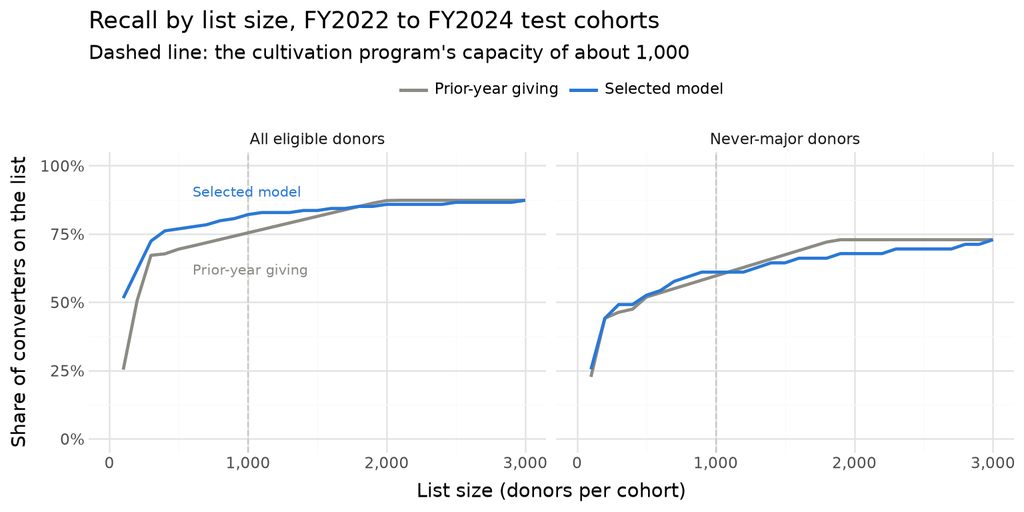

```python
def recall_at(df, col, k):
    # pooled recall at k over df's cohorts, ties at the cutoff split evenly
    hits = sum((share_on_list(w, gid, k) * w * y).sum() for _, y, w, gid in ranked(df, col))
    return hits / float((df["y"] * df["w"]).sum())

curve = pl.DataFrame([
    {"list_size": k, "group": g, "ranking": name, "recall": recall_at(df, col, k)}
    for k in range(100, 3001, 100)
    for g, df in (("All eligible donors", model_test), ("Never-major donors", model_never))
    for name, col in (("Selected model", "model_score"), ("Prior-year giving", "prior_total"))
]).to_pandas()
SERIES_COLORS = {"Selected model": "#2a78d6", "Prior-year giving": "#8b8b84"}
# direct labels in the clear space of the first panel, the model above its line and prior-year giving below
ends = curve[(curve["list_size"] == 600) & (curve["group"] == "All eligible donors")].copy()
ends["recall"] = ends["recall"] + np.where(ends["ranking"] == "Selected model", 0.13, -0.09)
(
    ggplot(curve, aes("list_size", "recall", color="ranking"))
    + geom_vline(xintercept=1000, color="#c9c8c3", linetype="dashed")
    + geom_line(size=1)
    + geom_text(aes(label="ranking"), data=ends, ha="left", size=8, show_legend=False)
    + facet_wrap("group")
    + scale_color_manual(values=SERIES_COLORS)
    + scale_x_continuous(limits=(0, 3000), breaks=[0, 1000, 2000, 3000], labels=lambda xs: [f"{x:,.0f}" for x in xs])
    + scale_y_continuous(limits=(0, 1), labels=lambda ys: [f"{100 * y:.0f}%" for y in ys])
    + labs(x="List size (donors per cohort)", y="Share of converters on the list", color="",
           title="Recall by list size, FY2022 to FY2024 test cohorts",
           subtitle="Dashed line: the cultivation program's capacity of about 1,000")
    + theme(legend_position="top", figure_size=(8, 4))
)
```

```python
assert all(sz[(k, "all eligible")]["gain_low"] > 0 for k in (250, 500, 1000))
assert sz[(2000, "all eligible")]["gain"] < 0 < sz[(2000, "all eligible")]["gain_high"]
assert sz[(2000, "never major")]["gain"] < 0
s250 = sz[(250, "all eligible")]
"list size claims hold"
```

```
'list size claims hold'
```

- **The model’s advantage is at the top of the list.** It holds 69.4% of converters in the top 250 against 63.3% for prior-year giving (6.1 points, 1.6 to 10.9), and about one donor in 8 on that list converts. The gain holds at 500 and 1,000.
- **By 2,000 the prior-year ranking catches up.** At a list of 2,000 the model is 1.4 points behind (-4.5 to 1.5), and 5.1 points behind for never-major donors. The model is best used to order a short, worked list. A longer list for annual-giving staff gains little from it, and prior-year giving serves as well.

### 5.4 Checks Reported Under R3

The checks below were set before any result (R3). They describe how far the main result travels, and none of them can change the model.

- **FY2025.** The check model scores the FY2025 cohort once. Its outcomes fall in FY2026, the year of the donor influx the group EDA found.
- **Before the program.** The FY2018 to FY2021 cohorts, each scored by a model trained on FY2014 through the year before, since FY2021 onward leaves nothing to train on. No donor in these cohorts was selected or contacted, so this is the cleanest test of ranking donors by their own giving history.
- **Without simulated contact.** The no-contact pool and the donors not selected for cultivation, from the Benchmarks section.
- **Two variants.** The FY2014 training window (decision D7) and the model refit without the contact flags (decision D11), each on the rolling test.

```python
PRE_PROGRAM = [2018, 2019, 2020, 2021]   # cohorts with no cultivation selection or contact
SENSITIVITY_START = 2014
assert not frame.filter(pl.col("t").is_between(SENSITIVITY_START, max(PRE_PROGRAM)))["selected"].any()
pre_run = cached_nested({**FINAL_SPEC, "name": f"{SELECTED}, before the program", "train_start": SENSITIVITY_START},
                        FINAL_GRID, test_cohorts=PRE_PROGRAM)
R3_VARIANTS = {
    "FY2014 training window": {**FINAL_SPEC, "name": f"{SELECTED}, FY2014 window", "train_start": SENSITIVITY_START},
    "without contact flags": {**FINAL_SPEC, "name": f"{SELECTED}, without contact flags",
                              "features": [f for f in FINAL_SPEC["features"] if f not in TRAINING_ONLY]},
}
variant_runs = {k: cached_nested(s, FINAL_GRID) for k, s in R3_VARIANTS.items()}
fy25 = scored.filter(pl.col("t") == 2025)
fy25_pred, fy25_seconds = score_with(check_model, fy25)
```

```python
r3_summary, r3_diffs, r3_boots = evaluate_models({SELECTED: FINAL_RUN[0], **{k: r[0] for k, r in variant_runs.items()}})

def pool_row(check, pool_all, pool_never):
    # the selected model in one pool, in the same columns as performance()
    s_all = r3_summary.filter((pl.col("group") == pool_all) & (pl.col("ranking") == SELECTED)).row(0, named=True)
    s_never = r3_summary.filter((pl.col("group") == pool_never) & (pl.col("ranking") == SELECTED)).row(0, named=True)
    d_all = cd_r3[(pool_all, SELECTED, "prior-year giving")]
    d_never = cd_r3[(pool_never, SELECTED, "prior-year giving")]
    bar = r3_summary.filter((pl.col("group") == pool_all) & (pl.col("ranking") == "prior-year giving"))["recall"].item()
    df = POOLS[pool_all]
    return {"check": check, "cohorts": "FY2022 to FY2024", "converters": float((df["y"] * df["w"]).sum()),
            "recall": s_all["recall"], "prior_year_recall": bar, "gain": 100 * d_all["gain"], "gain_low": 100 * d_all["low"],
            "gain_high": 100 * d_all["high"], "never_major_recall": s_never["recall"], "never_major_gain": 100 * d_never["gain"],
            "never_major_gain_low": 100 * d_never["low"], "never_major_gain_high": 100 * d_never["high"]}

cd_r3 = {(r["group"], r["model"], r["versus"]): r for r in r3_diffs.iter_rows(named=True)}
fy25_perf = performance("FY2025 check", fy25, fy25_pred)
pre_perf = performance("before the program", scored.filter(pl.col("t").is_in(PRE_PROGRAM)), pre_run[0])
R3_COLS = ["check", "cohorts", "converters", "recall", "prior_year_recall", "gain", "gain_low", "gain_high", "never_major_recall",
           "never_major_gain", "never_major_gain_low", "never_major_gain_high"]
r3_table = pl.DataFrame([
    {"check": p["setting"], **{c: p[c] for c in R3_COLS[1:]}} for p in (fy25_perf, pre_perf)
] + [pool_row("no-contact pool", "no contact", "no contact, never major"),
     pool_row("not selected for cultivation", "not selected", "not selected, never major")], schema_overrides={"converters": pl.Float64})
show(r3_table, pct_cols=["recall", "prior_year_recall", "never_major_recall"],
     fixed={c: 1 for c in R3_COLS if "gain" in c} | {"converters": 0},
     caption="R3 checks: the selected model's recall at 1,000 and paired gain over prior-year giving in points (report only)")
```

Table 19: R3 checks: the selected model's recall at 1,000 and paired gain over prior-year giving in points (report only)

| Check | Cohorts | Converters | Recall | Prior year recall | Gain | Gain low | Gain high | Never major recall | Never major gain | Never major gain low | Never major gain high |
| --- | --- | --- | --- | --- | --- | --- | --- | --- | --- | --- | --- |
| FY2025 check | FY2025 | 81 | 69.1% | 69.2% | 0.0 | -7.0 | 8.4 | 54.5% | -2.1 | -13.1 | 8.1 |
| before the program | FY2018 to FY2021 | 197 | 86.8% | 82.5% | 4.3 | 1.7 | 6.1 | 78.0% | 4.3 | 1.0 | 7.8 |
| no-contact pool | FY2022 to FY2024 | 85 | 80.1% | 72.2% | 8.0 | -2.0 | 19.7 | 55.4% | -5.6 | -15.9 | 2.0 |
| not selected for cultivation | FY2022 to FY2024 | 25 | 36.0% | 41.5% | -5.5 | -18.4 | 4.6 | 27.3% | -8.4 | -21.7 | 2.8 |

```python
variant_rows = []
for k in R3_VARIANTS:
    for g in ("all eligible", "never major"):
        d_ = paired(r3_boots[g], k, SELECTED)
        rec = r3_summary.filter((pl.col("group") == g) & (pl.col("ranking") == k))["recall"].item()
        variant_rows.append({"variant": k, "group": g, "recall": rec, "difference_from_selected": 100 * d_["gain"],
                             "low": 100 * d_["low"], "high": 100 * d_["high"]})
variants = pl.DataFrame(variant_rows)
vr = {(r["variant"], r["group"]): r for r in variants.iter_rows(named=True)}
show(variants, pct_cols=["recall"], fixed={"difference_from_selected": 1, "low": 1, "high": 1},
     caption="R3 variants on the FY2022 to FY2024 test cohorts: recall at 1,000 and the paired difference from the selected model in points")

# officer selection on the no-contact pools, an illustration only since the cultivation tables were invented
nc_model = no_contact.join(FINAL_RUN[0].rename({"score": "model_score"}), on=["constituent_id", "t"], how="left")
officer_scores = {"model": "model_score", "officer selection": "officer", "prior-year giving": "prior_total"}
b_off = bootstrap(nc_model, officer_scores)
b_off_never = bootstrap(nc_model.filter(~pl.col("former_major")), officer_scores)
off_all, off_never = paired(b_off, "model", "officer selection"), paired(b_off_never, "model", "officer selection")
```

[output not shown]

```python
r3 = {r["check"]: r for r in r3_table.iter_rows(named=True)}
fy25c, prec, ncp, nsel = r3["FY2025 check"], r3["before the program"], r3["no-contact pool"], r3["not selected for cultivation"]
assert fy25c["gain_low"] < 0 < fy25c["gain_high"] and fy25_perf["gain_vs_rule_low"] > 0
assert prec["gain_low"] > 0 and prec["never_major_gain_low"] > 0
assert ncp["gain_low"] < 0 < ncp["gain_high"] and nsel["gain_low"] < 0 < nsel["gain_high"]
assert off_all["low"] > 0 and off_never["low"] > 0
assert vr[("FY2014 training window", "all eligible")]["low"] < 0
assert abs(vr[("without contact flags", "all eligible")]["difference_from_selected"]) < 1
rate = {t: float(scored.filter(pl.col("t") == t)["y"].mean()) for t in (*TEST_COHORTS, 2025)}
assert rate[2025] > max(rate[t] for t in TEST_COHORTS)
"R3 claims hold"
```

```
'R3 claims hold'
```

- **FY2025: no gain in the influx year.** Scored once, the check model holds 69.1% of the 81 FY2025 converters, the same as prior-year giving (0.0 points, -7.0 to 8.4). It still beats the former major or $500 rule by 4.3 points (0.6 to 10.0). The FY2025 cohort converted at 0.25%, against 0.11% to 0.17% in the test cohorts, the FY2026 influx the group EDA described. When conversion jumps like this, the model’s edge over prior-year giving can disappear. This is the main risk to report with the model.
- **Before the program: a gain for never-major donors too.** On the FY2018 to FY2021 cohorts, where no donor was selected or contacted, the model holds 86.8% of 197 converters against 82.5% (4.3 points, 1.7 to 6.1). For never-major donors the gain is 4.3 points (1.0 to 7.8), the only setting where it is measurable. These cohorts train on FY2014 onward, with more converters to learn from, and simulated contact plays no part. That makes this the cleanest evidence that giving history alone adds something.
- **Without simulated contact.** On the no-contact pool the model holds 80.1% against 72.2% for prior-year giving, with an interval too wide to call (-2.0 to 19.7). Among donors officers did not select there are only 25 converters, and the model holds 36.0% against 41.5% (-18.4 to 4.6), too few to say anything.
- **Officer selection, as an illustration.** On the no-contact pool the model’s top 1,000 holds 9.4 points more converters than the donors officers chose (3.9 to 21.3), and 12.9 points more among never-major donors (3.0 to 28.2). The cultivation tables were invented, so this only shows how the comparison would work once PBS Utah records contacts (decision D13).
- **The two variants change little.** Training on FY2014 onward gives 84.3%, 2.2 points more than the selected model (-0.8 to 4.8), and 3.4 points more for never-major donors (0.0 to 8.7). Without the contact flags the ranking moves by 0.7 points. Under R3 neither changes the model, but the longer window is worth retesting once PBS Utah’s own records are in hand.

### 5.5 The Officer Rule (D23)

The amendment asks a different question from R1. R1 asked whether a model beats the sort PBS Utah uses today. D23 asks whether it beats the best list an officer could build by hand: former major donors first, then everyone else by last year’s giving, ties broken by years of giving. The table scores the selected model against that rule in every setting above, with the same paired test.

```python
def officer_rows(label, p):
    return [{"setting": label, "group": "all eligible", "converters": p["converters"], "model": p["recall"],
             "officer_rule": p["officer_rule_recall"], "prior_year": p["prior_year_recall"], "gain": p["gain_vs_officer"],
             "gain_low": p["gain_vs_officer_low"], "gain_high": p["gain_vs_officer_high"]},
            {"setting": label, "group": "never major", "converters": p["never_major_converters"], "model": p["never_major_recall"],
             "officer_rule": p["never_major_officer_rule"], "prior_year": p["never_major_prior_year"],
             "gain": p["never_major_gain_vs_officer"], "gain_low": p["never_major_gain_vs_officer_low"],
             "gain_high": p["never_major_gain_vs_officer_high"]}]

officer_table = pl.DataFrame(officer_rows("rolling test, FY2022 to FY2024", pf["rolling test"])
                             + officer_rows("FY2025 check", fy25_perf) + officer_rows("before the program, FY2018 to FY2021", pre_perf))
ot = {(r["setting"].split(",")[0], r["group"]): r for r in officer_table.iter_rows(named=True)}
officer_cands = {m: paired(cand_boots["all eligible"], m, "officer rule") for m in CANDIDATES}
officer_cands_never = {m: paired(cand_boots["never major"], m, "officer rule") for m in CANDIDATES}
officer_wins = {k: v["gain_low"] > 0 for k, v in ot.items()}
show(officer_table, pct_cols=["model", "officer_rule", "prior_year"], fixed={"gain": 1, "gain_low": 1, "gain_high": 1},
     caption="Selected model against the officer rule (D23): recall at 1,000 and the paired gain in points, with prior-year giving for reference")
```

Table 20: Selected model against the officer rule (D23): recall at 1,000 and the paired gain in points, with prior-year giving for reference

| Setting | Group | Converters | Model | Officer rule | Prior year | Gain | Gain low | Gain high |
| --- | --- | --- | --- | --- | --- | --- | --- | --- |
| rolling test, FY2022 to FY2024 | all eligible | 134 | 82.1% | 81.6% | 75.4% | 0.5 | -4.3 | 5.1 |
| rolling test, FY2022 to FY2024 | never major | 59 | 61.0% | 62.4% | 59.6% | -1.4 | -11.5 | 7.6 |
| FY2025 check | all eligible | 81 | 69.1% | 81.5% | 69.2% | -12.3 | -19.4 | -5.7 |
| FY2025 check | never major | 44 | 54.5% | 70.5% | 56.6% | -15.9 | -28.6 | -4.2 |
| before the program, FY2018 to FY2021 | all eligible | 197 | 86.8% | 85.4% | 82.5% | 1.4 | -1.7 | 3.5 |
| before the program, FY2018 to FY2021 | never major | 109 | 78.0% | 76.0% | 73.7% | 2.0 | 0.0 | 5.0 |

```python
main_vs_officer = ot[("rolling test", "all eligible")]
never_vs_officer = ot[("rolling test", "never major")]
pre_vs_officer = ot[("before the program", "all eligible")]
officer_vs_prior_gap = ba["officer rule"]["recall"] - ba["prior-year giving"]["recall"]
# the rule's gain over prior-year giving comes from former majors, who all fit on its list, and from ordering the tied block
assert officer_vs_prior_gap > 0 and officer_vs_bar_never["gain"] > 0
assert (prior_cutoff["donors_tied"] > K).all() and prior_cutoff["score_at_cutoff"].n_unique() == 1
assert (officer_cutoff["donors_tied"] < 200).all()
"officer rule claims hold"
```

```
'officer rule claims hold'
```

What this means for the recommendation is taken up in the Results section. The amendment cannot change the selected model, but it changes what PBS Utah should be told to do with it.

### 5.6 Calibration

Staff see each donor’s probability of becoming a major donor next year, so the probabilities should be about right, not just the order. R7 compares the predicted and observed number of converters, pooled over the test cohorts. If the ratio falls outside 0.8 to 1.25, the probabilities get a one-parameter intercept correction for each test cohort, estimated on that cohort’s most recent training cohort scored with the contact flags off. The correction changes the probabilities staff see but never the order of the list. Inside that range the probabilities are reported as they are.

```python
from scipy.optimize import brentq

def calibration_by_band(df, score_col):
    # predicted and observed conversion by position in the ranking, pooled over cohorts
    bands = [(1, 100), (101, 250), (251, 500), (501, 1000), (1001, 2000), (2001, 5000), (5001, None)]
    ranked_df = df.with_columns(position=pl.col(score_col).rank("ordinal", descending=True).over("t"))
    rows = []
    for lo, hi in bands:
        sel_ = ranked_df.filter(pl.col("position") >= lo) if hi is None else ranked_df.filter(pl.col("position").is_between(lo, hi))
        rows.append({"ranks": f"{lo:,} and below" if hi is None else f"{lo:,} to {hi:,}", "donor_years": sel_.height,
                     "converters": int(sel_["y"].sum()), "predicted_converters": float(sel_[score_col].sum()),
                     "mean_predicted": sel_[score_col].mean(), "observed_rate": sel_["y"].mean()})
    return pl.DataFrame(rows)

def intercept_shift(p, observed):
    # the shift on the log-odds scale that makes the probabilities add up to the observed converters
    logit = np.log(p / (1 - p))
    return brentq(lambda d: (1 / (1 + np.exp(-(logit + d)))).sum() - observed, -10, 10)

def shifted(p, d):
    return 1 / (1 + np.exp(-(np.log(p / (1 - p)) + d)))

pooled_ratio = float(model_test["model_score"].sum() / model_test["y"].sum())
NEEDS_RECALIBRATION = not (0.8 <= pooled_ratio <= 1.25)   # R7

# the correction each test cohort would get, from its latest training cohort (computed either way, applied only under R7)
shifts = {}
for T in TEST_COHORTS:
    prev = scored.filter(pl.col("t") == T - 1)
    p_prev, _ = score_with(fit_final(T - 1), prev)
    shifts[T] = intercept_shift(p_prev["score"].to_numpy(), float(prev["y"].sum()))
if NEEDS_RECALIBRATION:
    model_test = model_test.with_columns(model_score=pl.struct("model_score", "t").map_elements(
        lambda r: float(shifted(r["model_score"], shifts[r["t"]])), return_dtype=pl.Float64))
calibrated_ratio = float(model_test["model_score"].sum() / model_test["y"].sum())
cal_ratio_by_year = {t: float(d["model_score"].sum() / d["y"].sum()) for (t,), d in model_test.group_by("t")}
fy25_df = fy25.join(fy25_pred.rename({"score": "model_score"}), on=["constituent_id", "t"], how="left")
fy25_ratio = float(fy25_df["model_score"].sum() / fy25_df["y"].sum())
cal_bands = calibration_by_band(model_test, "model_score")
show(cal_bands, pct_cols=["mean_predicted", "observed_rate"], pct_digits=2, fixed={"predicted_converters": 1},
     caption="Calibration on the FY2022 to FY2024 test cohorts: predicted and observed next-year converters by position in the ranking")
```

Table 21: Calibration on the FY2022 to FY2024 test cohorts: predicted and observed next-year converters by position in the ranking

| Ranks | Donor years | Converters | Predicted converters | Mean predicted | Observed rate |
| --- | --- | --- | --- | --- | --- |
| 1 to 100 | 300 | 69 | 57.8 | 19.26% | 23.00% |
| 101 to 250 | 450 | 24 | 18.1 | 4.02% | 5.33% |
| 251 to 500 | 750 | 10 | 5.5 | 0.74% | 1.33% |
| 501 to 1,000 | 1,500 | 7 | 4.2 | 0.28% | 0.47% |
| 1,001 to 2,000 | 3,000 | 5 | 4.1 | 0.14% | 0.17% |
| 2,001 to 5,000 | 9,000 | 5 | 6.8 | 0.08% | 0.06% |
| 5,001 and below | 82,190 | 14 | 18.4 | 0.02% | 0.02% |

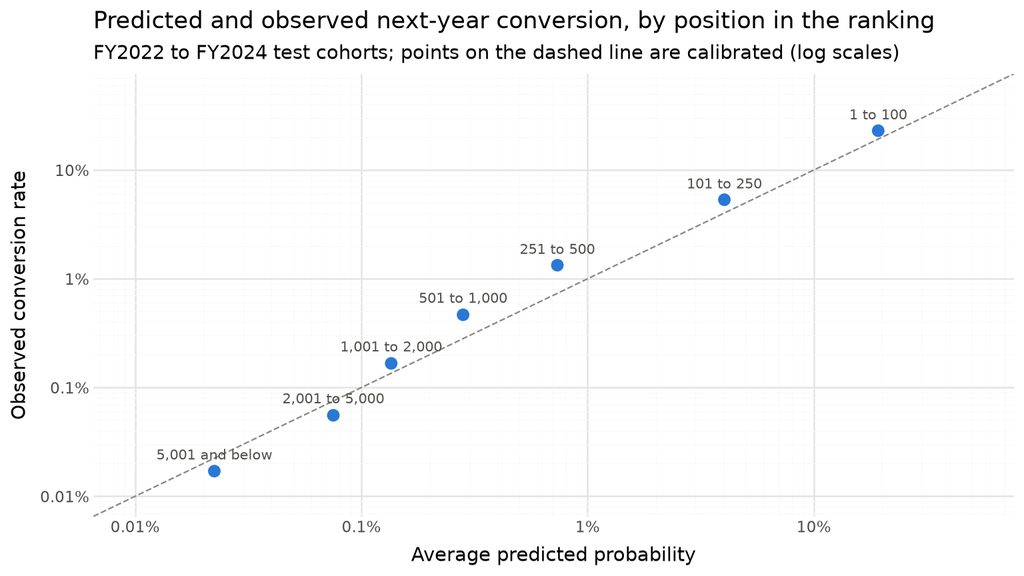

```python
cal_plot = cal_bands.with_columns(ranks=pl.col("ranks").cast(pl.Enum(cal_bands["ranks"].to_list()))).to_pandas()
lim = (1e-4, 0.5)
(
    ggplot(cal_plot, aes("mean_predicted", "observed_rate"))
    + geom_abline(intercept=0, slope=1, color="#8b8b84", linetype="dashed")
    + geom_point(color="#2a78d6", size=3)
    + geom_text(aes(label="ranks"), nudge_y=0.15, size=8, color="#52514e")
    + scale_x_log10(labels=lambda xs: [f"{100 * x:g}%" for x in xs], limits=lim)
    + scale_y_log10(labels=lambda ys: [f"{100 * y:g}%" for y in ys], limits=lim)
    + labs(x="Average predicted probability", y="Observed conversion rate",
           title="Predicted and observed next-year conversion, by position in the ranking",
           subtitle="FY2022 to FY2024 test cohorts; points on the dashed line are calibrated (log scales)")
    + theme(figure_size=(8, 4.5))
)
```

R7 also asks that staff always see a range of expected converters rather than a single number. The range comes from the probabilities on the list: if each donor converts with their predicted probability, independently, the number of converters among the top 1,000 varies from year to year by chance alone. The table compares that range with what happened in each test cohort.

```python
def converter_range(p, draws=10000, seed=SEED):
    # 95% range of the converter count when each donor converts with probability p, independently
    counts = (np.random.default_rng(seed).random((draws, len(p))) < p).sum(axis=1)
    return float(p.sum()), *np.quantile(counts, [0.025, 0.975])

range_rows = []
for t in TEST_COHORTS:
    top = model_test.filter(pl.col("t") == t).sort("model_score", descending=True).head(K)
    expected, lo, hi = converter_range(top["model_score"].to_numpy())
    range_rows.append({"cohort": t, "expected_converters": expected, "range_low": lo, "range_high": hi,
                       "observed_converters": int(top["y"].sum())})
ranges = pl.DataFrame(range_rows).with_columns(inside=pl.col("observed_converters").is_between(pl.col("range_low"), pl.col("range_high")))
show(ranges, fixed={"expected_converters": 1, "range_low": 0, "range_high": 0},
     caption="Converters among each test cohort's top 1,000: expected from the probabilities, a 95% range, and observed")
```

Table 22: Converters among each test cohort's top 1,000: expected from the probabilities, a 95% range, and observed

| Cohort | Expected converters | Range low | Range high | Observed converters | Inside |
| --- | --- | --- | --- | --- | --- |
| 2022 | 44.6 | 34 | 56 | 43 | True |
| 2023 | 27.5 | 19 | 37 | 28 | True |
| 2024 | 13.6 | 7 | 21 | 39 | False |

```python
# predicted and observed converters by cohort and contact status, the FY2025 check included
cal_cols = ["t", "contacted", "model_score", "y"]
cal_year = (
    pl.concat([model_test.select(cal_cols), fy25_df.select(cal_cols)])
    .with_columns(donors=pl.when(pl.col("contacted")).then(pl.lit("contacted")).otherwise(pl.lit("not contacted")))
    .group_by("t", "donors").agg(donor_years=pl.len(), predicted_converters=pl.col("model_score").sum(),
                                 observed_converters=pl.col("y").sum())
)
cal_year = pl.concat([
    cal_year,
    cal_year.group_by("t").agg(donors=pl.lit("all"), donor_years=pl.col("donor_years").sum(),
                               predicted_converters=pl.col("predicted_converters").sum(),
                               observed_converters=pl.col("observed_converters").sum()),
], how="diagonal_relaxed").with_columns(ratio=pl.col("predicted_converters") / pl.col("observed_converters")).sort("t", "donors")
cy = {(r["t"], r["donors"]): r for r in cal_year.iter_rows(named=True)}
show(cal_year.rename({"t": "cohort"}), fixed={"predicted_converters": 1, "ratio": 2},
     caption="Predicted and observed converters by cohort and contact status, FY2022 to FY2025 (scored with contact flags off)")
```

Table 23: Predicted and observed converters by cohort and contact status, FY2022 to FY2025 (scored with contact flags off)

| Cohort | Donors | Donor years | Predicted converters | Observed converters | Ratio |
| --- | --- | --- | --- | --- | --- |
| 2022 | all | 31,198 | 57.2 | 53 | 1.08 |
| 2022 | contacted | 752 | 24.3 | 33 | 0.74 |
| 2022 | not contacted | 30,446 | 32.9 | 20 | 1.64 |
| 2023 | all | 33,208 | 36.9 | 37 | 1.00 |
| 2023 | contacted | 752 | 14.8 | 27 | 0.55 |
| 2023 | not contacted | 32,456 | 22.2 | 10 | 2.22 |
| 2024 | all | 32,784 | 20.8 | 44 | 0.47 |
| 2024 | contacted | 752 | 7.8 | 34 | 0.23 |
| 2024 | not contacted | 32,032 | 12.9 | 10 | 1.29 |
| 2025 | all | 32,886 | 18.7 | 81 | 0.23 |
| 2025 | contacted | 751 | 8.1 | 56 | 0.14 |
| 2025 | not contacted | 32,135 | 10.6 | 25 | 0.42 |

```python
assert not NEEDS_RECALIBRATION
contacted_ratios = [cy[(t, "contacted")]["ratio"] for t in (*TEST_COHORTS, 2025)]
assert all(a > b for a, b in zip(contacted_ratios, contacted_ratios[1:]))           # contacted donors fall further behind each year
assert all(cy[(t, "not contacted")]["ratio"] > 1 for t in TEST_COHORTS) and cy[(2025, "not contacted")]["ratio"] < 1
rg = {r["cohort"]: r for r in ranges.iter_rows(named=True)}
assert rg[2022]["inside"] and rg[2023]["inside"] and not rg[2024]["inside"]
top_bands = cal_bands.head(4)   # ranks 1 to 1,000
top_pred, top_obs = top_bands["predicted_converters"].sum(), top_bands["converters"].sum()
rest_pred, rest_obs = cal_bands.tail(3)["predicted_converters"].sum(), cal_bands.tail(3)["converters"].sum()
assert cal_bands["ranks"][3] == "501 to 1,000" and top_obs > top_pred and rest_obs < rest_pred
"calibration claims hold"
```

```
'calibration claims hold'
```

- **R7 keeps the probabilities as they are.** Pooled over the test cohorts, the model predicts 0.86 converters for every one observed, inside the 0.8 to 1.25 range, so no correction is applied. By position in the ranking, the top 1,000 donors each year were predicted to produce 86 converters over the three cohorts and produced 110, while below rank 1,000 the model predicted 29 and 24 converted. The list holds more converters than its probabilities say, and the rest of the cohort fewer.
- **The pooled ratio hides two errors that offset.** By cohort the ratio is 1.08, 1.00, 0.47 for FY2022 to FY2024 and 0.23 for FY2025. Contacted donors are predicted further below what they did each year (0.74, 0.55, 0.23, 0.14). Donors are scored with the contact flags off, so their probabilities leave out the effect of contact, and in this release simulated contact steered more and more conversion toward selected donors from FY2023 on. Donors who were not contacted are predicted above what they did in FY2022 to FY2024, most likely because part of the contacted donors’ extra conversion was credited to the giving patterns officers select on. In FY2025 even donors who were not contacted converted at 2.4 times the predicted rate, the influx again.
- **Ranges for the list.** The 95% range of converters expected in the top 1,000 held what happened in FY2022 (43 converters, range 34 to 56) and FY2023 (28, range 19 to 37), but not FY2024, when 39 converted against a range of 7 to 21.

The probabilities are best read as what to expect from donors without officer contact, in a year like the ones the model was trained on. That is a fair basis for ordering the list. As a forecast of how many donors will convert, it ran low in the years when simulated contact or the influx pushed conversion up. The range shown with the FY2026 list in the last section has to carry this caveat.

### 5.7 Run Time

```python
runtime = pl.DataFrame([
    {"step": "fit the check model (FY2021 to FY2024)", "rows": check_model["training_rows"], "seconds": check_model["fit_seconds"]},
    {"step": "fit the final model (FY2021 to FY2025)", "rows": final_model["training_rows"], "seconds": final_model["fit_seconds"]},
    {"step": "score the FY2025 cohort", "rows": fy25.height, "seconds": fy25_seconds},
    {"step": "rolling test, three fits", "rows": int(FINAL_RUN[1]["training_rows"].sum()), "seconds": float(FINAL_RUN[1]["fit_seconds"].sum())},
])
show(runtime, digits=3, caption="Run time of the selected model")
```

Table 24: Run time of the selected model

| Step | Rows | Seconds |
| --- | --- | --- |
| fit the check model (FY2021 to FY2024) | 128,033 | 0.450 |
| fit the final model (FY2021 to FY2025) | 160,919 | 0.576 |
| score the FY2025 cohort | 32,886 | 0.011 |
| rolling test, three fits | 188,133 | 0.631 |

The selected model is fast at every step. The final model fits 160,919 donor-years in 0.6 seconds and scores a full cohort of 32,886 donors in 0.01 seconds. Refitting it each year after the June 30 cutoff costs PBS Utah almost nothing; most of the time in this notebook goes to the bootstrap intervals and to tuning the challengers, not to the model itself.

## 6 What the Model Finds

The model beats the prior-year ranking by about seven points for all eligible donors. This section explains where that gain comes from, so staff can see why the list differs from a sort by last year’s giving. It looks at the top 1,000 lists on the FY2022 to FY2024 test cohorts in three ways, then at what the final model weighs:

- **Who is on the list.** Erin’s list composition: how many former-major and never-major converters each list catches, and how many of its places go to each group.
- **Who the model finds that prior-year giving misses.** Kate’s breakdown of converters by prior-year giving band, split by which list found them.
- **What drives the score.** The final model’s coefficients.

Lapsed donors, who gave in one of the two years before FY t but not in FY t, are outside every list by decision D3; the last subsection reports how many of them convert.

### 6.1 Who Is on the List

```python
def with_list_share(df, col, name, k=K):
    # each row's share of a place on its cohort's top-k list by col, ties at the cutoff split evenly
    parts = []
    for d in df.partition_by("t"):
        gid = (d[col].rank("dense", descending=True) - 1).cast(pl.Int64).to_numpy()
        parts.append(d.with_columns(pl.Series(name, share_on_list(d["w"].to_numpy(), gid, k))))
    return pl.concat(parts)

lists = with_list_share(with_list_share(model_test, "model_score", "on_model"), "prior_total", "on_prior")
assert abs(lists.group_by("t").agg(pl.col("on_model").sum(), pl.col("on_prior").sum())
           .select(pl.col("on_model", "on_prior") - K).to_numpy()).max() < 1e-9   # every list has exactly 1,000 places

def composition(df, label):
    conv_ = df.filter(pl.col("y") == 1)
    return {"donors": label, "list_places_model": df["on_model"].sum() / len(TEST_COHORTS),
            "list_places_prior_year": df["on_prior"].sum() / len(TEST_COHORTS), "converters": conv_.height,
            "found_by_model": conv_["on_model"].sum(), "found_by_prior_year": conv_["on_prior"].sum()}

comp = pl.DataFrame([composition(lists.filter(pl.col("former_major")), "former major"),
                     composition(lists.filter(~pl.col("former_major")), "never major"),
                     composition(lists, "all eligible")])
cp = {r["donors"]: r for r in comp.iter_rows(named=True)}
assert abs(cp["all eligible"]["found_by_model"] / cp["all eligible"]["converters"] - sel_all["recall"]) < 1e-9
show(comp, fixed={"list_places_model": 0, "list_places_prior_year": 0, "found_by_model": 1, "found_by_prior_year": 1},
     caption="Composition of the top 1,000 lists on the FY2022 to FY2024 test cohorts: average places per year and converters found over the three cohorts")
```

Table 25: Composition of the top 1,000 lists on the FY2022 to FY2024 test cohorts: average places per year and converters found over the three cohorts

| Donors | List places model | List places prior year | Converters | Found by model | Found by prior year |
| --- | --- | --- | --- | --- | --- |
| former major | 170 | 89 | 75 | 75.0 | 66.7 |
| never major | 830 | 911 | 59 | 35.0 | 34.4 |
| all eligible | 1,000 | 1,000 | 134 | 110.0 | 101.0 |

```python
fm, nm = cp["former major"], cp["never major"]
assert fm["found_by_model"] == fm["converters"] > fm["found_by_prior_year"] and fm["list_places_model"] > 1.5 * fm["list_places_prior_year"]
assert abs(nm["found_by_model"] - nm["found_by_prior_year"]) < 1
gain_former = fm["found_by_model"] - fm["found_by_prior_year"]
gain_never = nm["found_by_model"] - nm["found_by_prior_year"]
assert gain_former > 5 * gain_never
"composition claims hold"
```

```
'composition claims hold'
```

- **The gain comes from former major donors.** The model catches 75 of the 75 former-major converters (every one of them) over the three test cohorts, against 66.7 for prior-year giving, a difference of 8.3 converters. Among never-major converters the two lists find 35.0 and 34.4, almost the same. Erin’s notebook found the same split.
- **It does this by giving former majors more places.** The model gives former major donors about 170 of the 1,000 places each year, against 89 on the prior-year list. A former major who gave less than usual in FY t falls down a sort by last year’s giving, but the model still ranks them near the top.

This is the most useful thing to tell staff about the list: it is a sort by last year’s giving that pulls former major donors back up. For donors who have never been major, it does about as well as the sort it replaces, which matches the never-major results in the last two sections.

### 6.2 Who the Model Finds That Prior-Year Giving Misses

```python
BAND_EDGES = [(0, 100, "under $100"), (100, 250, "$100 to $249"), (250, 600, "$250 to $599"), (600, 1200, "$600 to $1,199")]
band_expr = pl.when(pl.col("prior_total") < 100).then(pl.lit(BAND_EDGES[0][2]))
for lo, hi, label in BAND_EDGES[1:]:
    band_expr = band_expr.when(pl.col("prior_total").is_between(lo, hi, closed="left")).then(pl.lit(label))
lists = lists.with_columns(band=band_expr.cast(pl.Enum([b[2] for b in BAND_EDGES])),
                           both=pl.min_horizontal("on_model", "on_prior"),
                           model_only=(pl.col("on_model") - pl.col("on_prior")).clip(0, None),
                           prior_year_only=(pl.col("on_prior") - pl.col("on_model")).clip(0, None))
lists = lists.with_columns(neither=1 - pl.col("both") - pl.col("model_only") - pl.col("prior_year_only"))
band_table = (
    lists.group_by("band").agg(
        list_places_model=pl.col("on_model").sum() / len(TEST_COHORTS), list_places_prior_year=pl.col("on_prior").sum() / len(TEST_COHORTS),
        converters=(pl.col("y") == 1).sum(),
        **{c: (pl.col(c) * pl.col("y")).sum() for c in ("both", "model_only", "prior_year_only", "neither")})
    .sort("band")
)
bt = {r["band"]: r for r in band_table.iter_rows(named=True)}
model_only_total, prior_only_total = band_table["model_only"].sum(), band_table["prior_year_only"].sum()
assert abs((model_only_total - prior_only_total) / cp["all eligible"]["converters"] - gain_all[first]["gain"]) < 1e-9
show(band_table, fixed={c: 1 for c in ("both", "model_only", "prior_year_only", "neither")} | {"list_places_model": 0, "list_places_prior_year": 0},
     caption="Converters by FY t giving band and which top 1,000 list found them, FY2022 to FY2024; list places are averages per year")
```

Table 26: Converters by FY t giving band and which top 1,000 list found them, FY2022 to FY2024; list places are averages per year

| Band | List places model | List places prior year | Converters | Both | Model only | Prior year only | Neither |
| --- | --- | --- | --- | --- | --- | --- | --- |
| under $100 | 47 | 0 | 14 | 0.0 | 1.0 | 0.0 | 13.0 |
| $100 to $249 | 7 | 0 | 3 | 0.0 | 0.0 | 0.0 | 3.0 |
| $250 to $599 | 679 | 732 | 27 | 7.0 | 12.0 | 4.0 | 4.0 |
| $600 to $1,199 | 267 | 268 | 90 | 90.0 | 0.0 | 0.0 | 0.0 |

```python
def profile(weight, label):
    # weighted averages of a few use-list fields over the converters a list found alone
    c = lists.filter(pl.col("y") == 1).with_columns(wt=weight)
    tot = c["wt"].sum()
    avg = lambda e: float((c.select(e.cast(pl.Float64).fill_null(0) * pl.col("wt")).to_series().sum()) / tot)
    return {"converters": label, "count": tot, "former_major": avg(pl.col("former_major")),
            "average_prior_year_giving": avg(pl.col("prior_total")), "average_years_given_last_five": avg(pl.col("years_last5")),
            "soft_credit_before": avg(pl.col("soft_before").fill_null(False)), "sustainer": avg(pl.col("sustainer")),
            "average_largest_gift_share": avg(pl.col("largest_gift_share"))}

disc = pl.DataFrame([profile(pl.col("model_only"), "found only by the model"),
                     profile(pl.col("prior_year_only"), "found only by prior-year giving"),
                     profile(pl.col("both"), "found by both")])
dp = {r["converters"]: r for r in disc.iter_rows(named=True)}
show(disc, pct_cols=["former_major", "soft_credit_before", "sustainer"],
     fixed={"count": 1, "average_prior_year_giving": 0, "average_years_given_last_five": 1, "average_largest_gift_share": 2},
     caption="Profile of the converters each list found, FY2022 to FY2024 (weighted by each converter's share of a list place)")
```

Table 27: Profile of the converters each list found, FY2022 to FY2024 (weighted by each converter's share of a list place)

| Converters | Count | Former major | Average prior year giving | Average years given last five | Soft credit before | Sustainer | Average largest gift share |
| --- | --- | --- | --- | --- | --- | --- | --- |
| found only by the model | 13.0 | 64.2% | 234 | 4.6 | 35.9% | 40.9% | 0.76 |
| found only by prior-year giving | 4.0 | 0.0% | 262 | 3.5 | 16.9% | 83.4% | 0.52 |
| found by both | 97.0 | 68.7% | 575 | 4.6 | 68.4% | 35.8% | 0.78 |

```python
mid = bt["$250 to $599"]
assert mid["model_only"] == max(r["model_only"] for r in bt.values())
assert bt["$600 to $1,199"]["both"] == bt["$600 to $1,199"]["converters"]
low_conv = bt["under $100"]["converters"] + bt["$100 to $249"]["converters"]
low_found = bt["under $100"]["model_only"] + bt["$100 to $249"]["model_only"]
mo, po = dp["found only by the model"], dp["found only by prior-year giving"]
assert mo["former_major"] > po["former_major"] and po["sustainer"] > mo["sustainer"]
assert mo["average_years_given_last_five"] > po["average_years_given_last_five"]
top_band = lists.filter(pl.col("band") == "$600 to $1,199")
assert top_band["on_prior"].sum() / top_band.height > 0.95 and top_band["on_model"].sum() / top_band.height > 0.95
low = lists.filter(pl.col("band").is_in(["under $100", "$100 to $249"]))
low_former_share = float((low["on_model"] * low["former_major"]).sum() / low["on_model"].sum())
assert low_former_share > 0.5
tie_sizes, tie_amounts = [], []
for d in lists.partition_by("t"):
    cut = d.sort("prior_total", descending=True)["prior_total"][K - 1]
    tie_amounts.append(cut)
    tie_sizes.append(d.filter(pl.col("prior_total") == cut).height)
assert min(tie_sizes) > 1
"band claims hold"
```

```
'band claims hold'
```

- **Every converter who gave $600 or more in FY t is on both lists.** All 90 of them. Both lists give a place to nearly every donor in that band, so it cannot separate the two rankings.
- **The two lists differ in the $250 to $599 band.** Here the model finds 12.0 converters the prior-year list misses and misses 4.0 that it finds. The prior-year list’s cutoff falls inside this band: in each test cohort the 1,000th place lands on a gift amount ($250, $250, $250) shared by 1,516, 1,431, 1,512 donors, who split the last places evenly. The model ranks those donors by the rest of their history instead.
- **Converters who gave under $250 in FY t are mostly out of reach.** There were 17 of them, and the model found 1, even though it gives about 54 places a year to donors in these bands, 86% of them to former majors. Converting from under $250 to $1,200 or more in one year is rare and hard to see coming.

Who the model finds alone is just as telling. Of the 13.0 converters only the model found, 64% were former major donors. They had given in 4.6 of the last five years on average, and their largest gift was 76% of their FY t giving. Of the 4.0 that only the prior-year list found, none was a former major, 83% were sustainers, and they had given in 3.5 of the last five years. The model trades sustainers who reached the $250 to $599 range through monthly payments for donors with a past major year and one larger gift. Kate’s notebook found extra converters among $100 to $249 donors with a past major year or a long record. On the group population, the same kind of donor shows up one band higher.

### 6.3 What Drives the Score

The coefficients below come from the final model, trained on FY2021 to FY2025. Every input is standardized before fitting, so each coefficient is the change in the log-odds of converting for a one standard deviation increase, holding the other inputs fixed. Three inputs are left out of the chart. The contact flags are used in training only and are switched off for every donor scored. Age has no planted relationship with conversion in this release, so it stays in the model as a tested input but is not presented as a driver (decision D10). The third, an indicator for the FY2021 cohort, is explained below the chart.

```python
pipe = final_model["estimator"]
imputer, scaler, lr = pipe[0], pipe[1], pipe[-1]
cols = final_model["columns"]
names = list(cols) + [f"{cols[i]} (missing)" for i in imputer.indicator_.features_]
assert len(names) == lr.coef_.shape[1]

def describe(name):
    base = name.split(" (missing)")[0].split("_Female")[0].split("_Male")[0].split("_Unknown")[0]
    group, _, text = FEATURES.get(base, ("", "", ""))
    return group, text + (" is missing" if name.endswith("(missing)") else "")

drivers = pl.DataFrame({"input": names, "coefficient": lr.coef_[0]}).with_columns(
    odds_ratio_per_sd=pl.col("coefficient").exp(),
    group=pl.col("input").map_elements(lambda s: describe(s)[0], return_dtype=pl.String),
    meaning=pl.col("input").map_elements(lambda s: describe(s)[1], return_dtype=pl.String),
    shown=~pl.col("input").is_in(["contacted", "held_out", "age_at_t", "soft_before (missing)"]),
).sort(pl.col("coefficient").abs(), descending=True)
dv = {r["input"]: r for r in drivers.iter_rows(named=True)}
show(drivers.select("input", "group", "meaning", "coefficient", "odds_ratio_per_sd"), digits=2,
     caption="Final model coefficients per standard deviation of each input, largest first")
```

Table 28: Final model coefficients per standard deviation of each input, largest first

| Input | Group | Meaning | Coefficient | Odds ratio per sd |
| --- | --- | --- | --- | --- |
| prior_total | giving history | Giving in FY t: own payments, soft credits, and legacy gifts | 0.60 | 1.82 |
| soft_before (missing) | giving history | Received a soft credit before FY t (empty through FY2021) is missing | 0.53 | 1.69 |
| largest_gift_share | giving history | Largest single gift as a share of FY t giving | 0.40 | 1.49 |
| years_last5 | giving history | Fiscal years with a gift, FY t-4 to FY t | 0.30 | 1.35 |
| contacted | cultivation | Selected in FY t and contacted in FY t+1 (off when scoring) | 0.30 | 1.34 |
| monthly_amount | giving history | Average sustaining payment in FY t (empty for non-sustainers) | -0.27 | 0.76 |
| former_major | giving history | Major donor in any earlier fiscal year | 0.14 | 1.15 |
| gender_Unknown | person | Female, Male, or Unknown | -0.14 | 0.87 |
| age_at_t | person | Age at June 30 of FY t (no planted effect in this release) | 0.11 | 1.12 |
| held_out | cultivation | Selected in FY t and held out of contact (off when scoring) | 0.10 | 1.11 |
| gender_Female | person | Female, Male, or Unknown | 0.08 | 1.09 |
| years_since_first_gift | giving history | Years from the first fiscal year with a gift to FY t | 0.06 | 1.06 |
| gender_Male | person | Female, Male, or Unknown | 0.05 | 1.05 |
| legacy_years | giving history | Fiscal years with a legacy-system gift | -0.05 | 0.95 |
| soft_before | giving history | Received a soft credit before FY t (empty through FY2021) | 0.04 | 1.04 |
| change_from_last_year | giving history | FY t giving minus FY t-1 giving | -0.01 | 0.99 |
| two_years_before | giving history | Total giving in FY t-2 and FY t-1 | -0.01 | 0.99 |
| sustainer | giving history | Made a recurring or sustaining payment in FY t | -0.00 | 1.00 |
| monthly_amount (missing) | giving history | Average sustaining payment in FY t (empty for non-sustainers) is missing | 0.00 | 1.00 |

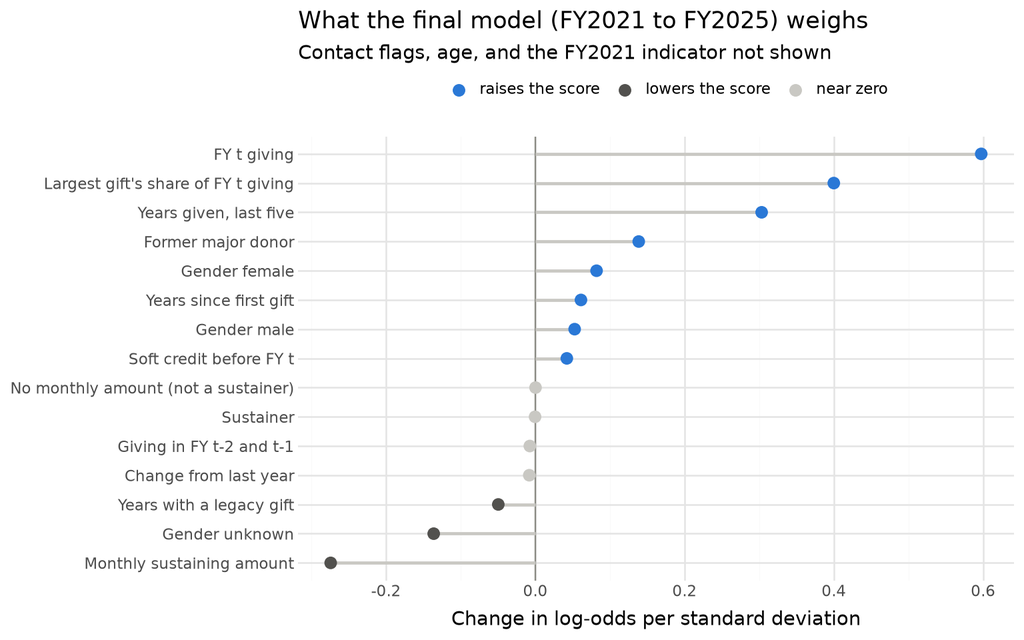

```python
dplot = drivers.filter(pl.col("shown")).with_columns(
    direction=pl.when(pl.col("coefficient").abs() < 0.02).then(pl.lit("near zero"))
    .when(pl.col("coefficient") > 0).then(pl.lit("raises the score")).otherwise(pl.lit("lowers the score"))).to_pandas()
DRIVER_LABELS = {
    "prior_total": "FY t giving", "largest_gift_share": "Largest gift's share of FY t giving", "years_last5": "Years given, last five",
    "monthly_amount": "Monthly sustaining amount", "former_major": "Former major donor", "gender_Unknown": "Gender unknown",
    "gender_Female": "Gender female", "gender_Male": "Gender male", "years_since_first_gift": "Years since first gift",
    "legacy_years": "Years with a legacy gift", "soft_before": "Soft credit before FY t", "change_from_last_year": "Change from last year",
    "two_years_before": "Giving in FY t-2 and t-1", "sustainer": "Sustainer", "monthly_amount (missing)": "No monthly amount (not a sustainer)",
}
assert set(dplot["input"]) <= set(DRIVER_LABELS)
dplot["label"] = dplot["input"].map(DRIVER_LABELS)
dplot["label"] = pd.Categorical(dplot["label"], categories=list(dplot.sort_values("coefficient")["label"]), ordered=True)
(
    ggplot(dplot, aes("coefficient", "label"))
    + geom_vline(xintercept=0, color="#8b8b84")
    + geom_segment(aes(x=0, xend="coefficient", y="label", yend="label"), color="#c9c8c3", size=1)
    + geom_point(aes(color="direction"), size=3)
    + scale_color_manual(values={"raises the score": "#2a78d6", "lowers the score": "#52514e", "near zero": "#c9c8c3"},
                         breaks=["raises the score", "lowers the score", "near zero"])
    + labs(x="Change in log-odds per standard deviation", y="", color="",
           title="What the final model (FY2021 to FY2025) weighs", subtitle="Contact flags, age, and the FY2021 indicator not shown")
    + theme(legend_position="top", figure_size=(8, 5))
)
```

```python
era = dv["soft_before (missing)"]
assert drivers.filter(pl.col("shown"))["input"][0] == "prior_total"
assert dv["largest_gift_share"]["coefficient"] > 0 and dv["years_last5"]["coefficient"] > 0 and dv["former_major"]["coefficient"] > 0
assert dv["monthly_amount"]["coefficient"] < 0
assert max(abs(dv[f]["coefficient"]) for f in ("change_from_last_year", "two_years_before")) < 0.05
soft_missing_years = sorted(frame.filter(pl.col("t").is_between(2021, 2025) & pl.col("soft_before").is_null())["t"].unique().to_list())
assert soft_missing_years == [2021]
"driver claims hold"
```

```
'driver claims hold'
```

- **FY t giving leads.** One standard deviation more giving in FY t multiplies the odds of converting by 1.82, more than any other input.
- **The shape of a donor’s giving comes next.** A larger share of FY t giving in one gift (odds ratio 1.49 per standard deviation) and more years with a gift in the last five (1.35) both raise the score. A larger monthly sustaining amount lowers it (0.76), holding FY t giving fixed. Of two donors who each gave $500, the model rates the one who gave it in a single gift above the one who reached it through monthly payments.
- **Former major status.** Its own coefficient is modest (1.15), because a past major year also shows up in the largest gift share and the years given. Together these inputs lift former majors in the ranking, as the composition table shows.
- **What adds little.** The change from last year and the giving two years before have coefficients near zero once FY t giving is in the model. This fits the 3-year total doing no better than prior-year giving in the Benchmarks section.
- **One coefficient describes the data, not donors.** The indicator for a missing “soft credit before FY t” is large (1.69), but soft credits before FY t are missing only for the FY2021 cohort, since they were not recorded before the Unite system. The indicator absorbs whatever sets that cohort apart from the later training cohorts. It is zero for every donor scored from FY2022 on, so it cannot move anyone on a list, and it is left out of the chart.

The coefficients show what the model leans on, not why donors convert. Several inputs measure related things, so the weight can shift between them from one training window to the next, and staff should read the chart as a description of the score rather than a list of causes.

### 6.4 Lapsed Donors

```python
seg = (cohorts.filter((pl.col("window") == 1) & pl.col("t").is_between(2021, 2025))
       .group_by("t", "segment").agg(donors=pl.len(), converters=pl.col("converted").sum()).sort("t", "segment"))
seg_wide = seg.pivot(on="segment", index="t", values=["donors", "converters"]).with_columns(
    lapsed_rate=pl.col("converters_lapsed") / pl.col("donors_lapsed"), active_rate=pl.col("converters_active") / pl.col("donors_active"),
    lapsed_share_of_converters=pl.col("converters_lapsed") / (pl.col("converters_lapsed") + pl.col("converters_active")))
lapsed_conv = int(seg_wide["converters_lapsed"].sum())
lapsed_share = lapsed_conv / int(seg_wide["converters_lapsed"].sum() + seg_wide["converters_active"].sum())
show(seg_wide.rename({"t": "cohort"}), pct_cols=["lapsed_rate", "active_rate", "lapsed_share_of_converters"], pct_digits=2,
     caption="Lapsed and active donors at each snapshot, FY2021 to FY2025: donors, next-year converters, and conversion rates")
```

Table 29: Lapsed and active donors at each snapshot, FY2021 to FY2025: donors, next-year converters, and conversion rates

| Cohort | Donors active | Donors lapsed | Converters active | Converters lapsed | Lapsed rate | Active rate | Lapsed share of converters |
| --- | --- | --- | --- | --- | --- | --- | --- |
| 2021 | 30,843 | 13,837 | 55 | 0 | 0.00% | 0.18% | 0.00% |
| 2022 | 31,198 | 14,581 | 53 | 3 | 0.02% | 0.17% | 5.36% |
| 2023 | 33,208 | 14,140 | 37 | 0 | 0.00% | 0.11% | 0.00% |
| 2024 | 32,784 | 13,857 | 44 | 1 | 0.01% | 0.13% | 2.22% |
| 2025 | 32,886 | 14,253 | 81 | 5 | 0.04% | 0.25% | 5.81% |

```python
assert (seg_wide["lapsed_rate"] < seg_wide["active_rate"]).all() and lapsed_share < 0.05
rate_ratio = float(seg_wide["active_rate"].mean() / seg_wide["lapsed_rate"].mean())
"lapsed claims hold"
```

```
'lapsed claims hold'
```

Lapsed donors are about 14,134 people a year, but only 9 of them became major donors the next year across the FY2021 to FY2025 snapshots, 3.2% of all next-year converters. Active donors convert about 13 times as often. Leaving them out of the main list (decision D3) costs very few converters. A lapsed-only list, as Kate built, is an optional view for reactivation campaigns, not a source of major donors.

## 7 Longer Windows and Giving Tier

### 7.1 Becoming a Major Donor Within 3 or 5 Years

The revised business problem asks for donors likely to become major donors within three to five years, for a long-term nurture list. A strictly time-based test of a longer outcome needs training cohorts whose outcome windows had closed by the test cohort’s prediction date. For the 3 year outcome, test cohort T can train only on cohorts up to T-3, and for the 5 year outcome up to T-5. That pushes training back into the legacy-system years, so these models train on cohorts from FY1999 onward and rely on giving history (decision D15). The engagement fields were not recorded then, and the contact flags are off for every pre-program cohort. One input of the 12 month model is left out: soft credits before FY t, which were not recorded before FY2021 and are missing for every training row in these test windows. A check in the code below confirms that dropping it leaves the test scores unchanged, and the Giving Tier subsection shows why keeping it would distort scores for recent donors. We report them as projections: they rank donors by the same giving history the 12 month model uses, over a longer horizon.

Test design for the longer outcomes

| Outcome | Test cohorts | Checked once (report only) | Training cohorts for the first test |
| --- | --- | --- | --- |
| Within 3 years | FY2021 and FY2022 (outcomes through FY2025) | FY2023 (its window reaches FY2026) | FY1999 to FY2018 |
| Within 5 years | FY2016 to FY2020 (outcomes through FY2025) | FY2021 (its window reaches FY2026) | FY1999 to FY2011 |

Under R4 the selected model’s family is the reported model: Erin’s untuned L2 logistic regression on the use list. An explainable boosting machine, with its default settings and no tuning, replaces it only if it passes the R1 test against it. Both are compared with the prior-year ranking and the former major or $500 rule on the same resamples.

```python
from interpret.glassbox import ExplainableBoostingClassifier

LONG_START = 1999
LONG = {
    "within 3 years": {"target": "y_3yr", "window": 3, "test": [2021, 2022], "check": 2023},
    "within 5 years": {"target": "y_5yr", "window": 5, "test": [2016, 2017, 2018, 2019, 2020], "check": 2021},
}
EBM = "explainable boosting machine"
# soft credits before FY t were not recorded before FY2021, so models trained from FY1999 leave them out
LONG_FEATURES = [f for f in FINAL_FEATURES if f != "soft_before"]
LONG_SPECS = {
    SELECTED: {**FINAL_SPEC, "features": LONG_FEATURES, "train_start": LONG_START},
    # trees handle gaps natively; a feature with no observed values in a training window is dropped first.
    # Two workers keep memory within a 16 GB laptop; each bag is seeded from random_state, so results do not depend on it
    EBM: candidate(EBM, ExplainableBoostingClassifier(random_state=SEED, n_jobs=2), features=LONG_FEATURES, scaled=False,
                   drop_empty=True, train_start=LONG_START),
}
import gc
gc.collect()   # free memory left over from earlier fits before the long ones
long_runs = {
    (o, m): cached_nested({**spec, "name": f"{m}, {o}"}, None, target=cfg["target"], window=cfg["window"], test_cohorts=cfg["test"])
    for o, cfg in LONG.items() for m, spec in LONG_SPECS.items()
}

# the same runs with soft credits before FY t kept: the input is missing in every training window of these tests,
# so leaving it out cannot change the scores
for o, cfg in LONG.items():
    for m in LONG_SPECS:
        train_rows = frame.filter(pl.col("t").is_between(LONG_START, max(cfg["test"]) - cfg["window"]) & pl.col(cfg["target"]).is_not_null())
        assert train_rows["soft_before"].null_count() == train_rows.height
# (the boosting machine drops a column with no observed values before fitting, so for it the two versions are the same
# matrix by construction; the logistic regression, which imputes and scales the column, is refit to show it)
kept_soft = {
    (o, SELECTED): cached_nested({**LONG_SPECS[SELECTED], "features": FINAL_FEATURES, "name": f"{SELECTED}, {o}"}, None,
                                 target=cfg["target"], window=cfg["window"], test_cohorts=cfg["test"])
    for o, cfg in LONG.items()
}
long_input_diff = max(
    float(np.abs(long_runs[k][0].join(kept_soft[k][0], on=["constituent_id", "t"]).select(pl.col("score") - pl.col("score_right"))
                 .to_numpy()).max())
    for k in kept_soft
)
assert long_input_diff < 1e-6
```

```python
LONG_SCORES = {"prior-year giving": "prior_total", "former major or $500": "rule_former_or_500"}

def long_frame(cfg, cohorts):
    # donor-years in the given cohorts with the longer outcome as y
    return scored.filter(pl.col("t").is_in(cohorts)).with_columns(y=pl.col(cfg["target"]), w=pl.lit(1.0))

long_rows, long_boots = [], {}
for o, cfg in LONG.items():
    df = long_frame(cfg, cfg["test"])
    for m in LONG_SPECS:
        df = df.join(long_runs[(o, m)][0].rename({"score": m}), on=["constituent_id", "t"], how="left")
    assert df.select(pl.col(list(LONG_SPECS)).null_count()).sum_horizontal().item() == 0
    scores = {**LONG_SCORES, **{m: m for m in LONG_SPECS}}
    for g, d in (("all eligible", df), ("never major", df.filter(~pl.col("former_major")))):
        b = long_boots[(o, g)] = bootstrap(d, scores)
        for r in summarize(b, "ranking").iter_rows(named=True):
            gain = paired(b, r["ranking"], "prior-year giving") if r["ranking"] != "prior-year giving" else None
            long_rows.append({"outcome": o, "group": g, "cohorts": f"FY{min(cfg['test'])} to FY{max(cfg['test'])}",
                              "converters": int(d["y"].sum()), "ranking": r["ranking"], "recall": r["recall"],
                              "recall_low": r["recall_low"], "recall_high": r["recall_high"],
                              "gain": None if gain is None else 100 * gain["gain"],
                              "gain_low": None if gain is None else 100 * gain["low"],
                              "gain_high": None if gain is None else 100 * gain["high"]})
long_table = pl.DataFrame(long_rows)
lt = {(r["outcome"], r["group"], r["ranking"]): r for r in long_table.iter_rows(named=True)}
show(long_table, pct_cols=["recall", "recall_low", "recall_high"], fixed={"gain": 1, "gain_low": 1, "gain_high": 1},
     caption="Recall at 1,000 for the longer outcomes, with the paired gain over prior-year giving in points")
```

Table 30: Recall at 1,000 for the longer outcomes, with the paired gain over prior-year giving in points

| Outcome | Group | Cohorts | Converters | Ranking | Recall | Recall low | Recall high | Gain | Gain low | Gain high |
| --- | --- | --- | --- | --- | --- | --- | --- | --- | --- | --- |
| within 3 years | all eligible | FY2021 to FY2022 | 223 | prior-year giving | 58.8% | 52.1% | 65.9% |  |  |  |
| within 3 years | all eligible | FY2021 to FY2022 | 223 | former major or $500 | 61.8% | 54.6% | 69.3% | 3.0 | -1.5 | 7.0 |
| within 3 years | all eligible | FY2021 to FY2022 | 223 | untuned L2 (Erin) | 68.2% | 61.2% | 75.5% | 9.4 | 4.8 | 13.7 |
| within 3 years | all eligible | FY2021 to FY2022 | 223 | explainable boosting machine | 67.3% | 60.1% | 74.4% | 8.5 | 3.6 | 13.1 |
| within 3 years | never major | FY2021 to FY2022 | 122 | prior-year giving | 39.8% | 31.4% | 48.7% |  |  |  |
| within 3 years | never major | FY2021 to FY2022 | 122 | former major or $500 | 30.5% | 22.1% | 39.0% | -9.3 | -14.1 | -5.1 |
| within 3 years | never major | FY2021 to FY2022 | 122 | untuned L2 (Erin) | 42.6% | 32.5% | 53.1% | 2.8 | -3.0 | 8.4 |
| within 3 years | never major | FY2021 to FY2022 | 122 | explainable boosting machine | 44.3% | 33.6% | 53.5% | 4.4 | -2.2 | 9.8 |
| within 5 years | all eligible | FY2016 to FY2020 | 708 | prior-year giving | 58.4% | 54.0% | 63.2% |  |  |  |
| within 5 years | all eligible | FY2016 to FY2020 | 708 | former major or $500 | 50.1% | 45.1% | 55.3% | -8.3 | -11.5 | -4.9 |
| within 5 years | all eligible | FY2016 to FY2020 | 708 | untuned L2 (Erin) | 62.0% | 57.0% | 67.0% | 3.6 | 0.8 | 6.2 |
| within 5 years | all eligible | FY2016 to FY2020 | 708 | explainable boosting machine | 61.6% | 56.5% | 66.3% | 3.1 | 0.6 | 5.5 |
| within 5 years | never major | FY2016 to FY2020 | 511 | prior-year giving | 48.8% | 43.4% | 54.7% |  |  |  |
| within 5 years | never major | FY2016 to FY2020 | 511 | former major or $500 | 31.3% | 26.2% | 36.8% | -17.6 | -21.1 | -14.1 |
| within 5 years | never major | FY2016 to FY2020 | 511 | untuned L2 (Erin) | 48.3% | 42.4% | 54.7% | -0.5 | -3.3 | 2.4 |
| within 5 years | never major | FY2016 to FY2020 | 511 | explainable boosting machine | 47.6% | 42.0% | 53.3% | -1.3 | -3.6 | 1.0 |

```python
# R4: the boosting machine replaces the selected family only under the R1 test
r4_rows, LONG_SELECTED = [], {}
for o in LONG:
    res, replaces = r1_compare({g: long_boots[(o, g)] for g in ("all eligible", "never major")}, EBM, SELECTED)
    LONG_SELECTED[o] = EBM if replaces else SELECTED
    r4_rows.append({"outcome": o, **{f"{k}_{g.split()[0]}": 100 * res[g][k] for g in res for k in ("gain", "low", "high")},
                    "replaces": replaces, "reported_model": LONG_SELECTED[o]})
r4_table = pl.DataFrame(r4_rows)
show(r4_table, fixed={c: 1 for c in r4_table.columns if c.split("_")[0] in ("gain", "low", "high")},
     caption="R4: the explainable boosting machine's paired gain over the selected family, in points of recall at 1,000")
```

Table 31: R4: the explainable boosting machine's paired gain over the selected family, in points of recall at 1,000

| Outcome | Gain all | Low all | High all | Gain never | Low never | High never | Replaces | Reported model |
| --- | --- | --- | --- | --- | --- | --- | --- | --- |
| within 3 years | -0.9 | -3.9 | 2.1 | 1.6 | -4.1 | 6.3 | False | untuned L2 (Erin) |
| within 5 years | -0.4 | -2.6 | 1.6 | -0.8 | -3.6 | 2.1 | False | untuned L2 (Erin) |

```python
# the labeled check cohorts, scored once by the reported model for each outcome (report only)
check_rows = []
for o, cfg in LONG.items():
    m = LONG_SELECTED[o]
    run = cached_nested({**LONG_SPECS[m], "name": f"{m}, {o}, check"}, None, target=cfg["target"], window=cfg["window"],
                        test_cohorts=[cfg["check"]])
    p = performance(f"{o}, FY{cfg['check']} check", long_frame(cfg, [cfg["check"]]), run[0])
    check_rows.append({"check": p["setting"], **{c: p[c] for c in R3_COLS[1:]}})
long_checks = pl.DataFrame(check_rows)
lc = {r["check"]: r for r in long_checks.iter_rows(named=True)}
show(long_checks, pct_cols=["recall", "prior_year_recall", "never_major_recall"],
     fixed={c: 1 for c in R3_COLS if "gain" in c},
     caption="Labeled checks for the longer outcomes, scored once: recall at 1,000 and the paired gain over prior-year giving in points")
```

Table 32: Labeled checks for the longer outcomes, scored once: recall at 1,000 and the paired gain over prior-year giving in points

| Check | Cohorts | Converters | Recall | Prior year recall | Gain | Gain low | Gain high | Never major recall | Never major gain | Never major gain low | Never major gain high |
| --- | --- | --- | --- | --- | --- | --- | --- | --- | --- | --- | --- |
| within 3 years, FY2023 check | FY2023 | 120 | 66.7% | 56.5% | 10.1 | 4.3 | 16.4 | 49.3% | 4.1 | -2.6 | 10.6 |
| within 5 years, FY2021 check | FY2021 | 169 | 55.0% | 49.0% | 6.0 | 2.2 | 11.1 | 33.6% | 2.0 | -3.1 | 7.3 |

```python
long_timing = pl.concat([r[1] for r in long_runs.values()]).group_by("model").agg(
    test_cohorts=pl.len(), training_rows=pl.col("training_rows").sum(), fit_seconds=pl.col("fit_seconds").sum(),
    predict_seconds=pl.col("predict_seconds").sum()).sort("model")
show(long_timing, digits=1, caption="Run time for the longer outcomes, summed over test cohorts")
```

Table 33: Run time for the longer outcomes, summed over test cohorts

| Model | Test cohorts | Training rows | Fit seconds | Predict seconds |
| --- | --- | --- | --- | --- |
| explainable boosting machine, within 3 years | 2 | 660,996 | 408.2 | 0.0 |
| explainable boosting machine, within 5 years | 5 | 1,135,731 | 510.9 | 0.0 |
| untuned L2 (Erin), within 3 years | 2 | 660,996 | 1.8 | 0.0 |
| untuned L2 (Erin), within 5 years | 5 | 1,135,731 | 2.9 | 0.0 |

```python
L3, L5 = "within 3 years", "within 5 years"
g3, g5 = lt[(L3, "all eligible", SELECTED)], lt[(L5, "all eligible", SELECTED)]
n3, n5 = lt[(L3, "never major", SELECTED)], lt[(L5, "never major", SELECTED)]
assert g3["gain_low"] > 0 and g5["gain_low"] > 0                       # both clear prior-year giving for all eligible
assert n3["gain_low"] < 0 < n3["gain_high"] and n5["gain_low"] < 0 < n5["gain_high"]
assert all(LONG_SELECTED[o] == SELECTED for o in LONG)
vs_rule_long = {o: paired(long_boots[(o, "all eligible")], SELECTED, "former major or $500") for o in LONG}
clears = {o: "clears" if d["low"] > 0 else "does not clear" for o, d in vs_rule_long.items()}
c3, c5 = lc[f"{L3}, FY2023 check"], lc[f"{L5}, FY2021 check"]
assert c3["gain_low"] > 0 and c5["gain_low"] > 0
ebm_minutes = long_timing.filter(pl.col("model").str.starts_with(EBM))["fit_seconds"] / 60
lr_seconds = long_timing.filter(pl.col("model").str.starts_with(SELECTED))["fit_seconds"]
"longer outcome claims hold"
```

```
'longer outcome claims hold'
```

- **Within 3 years.** The selected family holds 68.2% of the 223 converters in its top 1,000 against 58.8% for prior-year giving, a gain of 9.4 points (4.8 to 13.7). It clears the former major or $500 rule (6.4 points, 3.0 to 10.0).
- **Within 5 years.** It holds 62.0% of 708 converters against 58.4%, a smaller gain of 3.6 points (0.8 to 6.2), and it clears the former major or $500 rule (11.9 points). The further out the outcome, the closer the model comes to last year’s giving.
- **Never-major donors.** For both windows the gain is not measurable: 2.8 points within 3 years (-3.0 to 8.4) and -0.5 within 5 (-3.3 to 2.4). This is the same pattern as the 12 month model, where the composition table traced the gain to former major donors.
- **R4 keeps the selected family.** The explainable boosting machine is -0.9 and -0.4 points from it for all eligible donors, and neither difference is measurable in either group. It also took 7 to 9 minutes to fit, against 2 to 3 seconds for the logistic regression.
- **The labeled checks agree.** Scored once, the FY2023 cohort’s 3 year outcome shows a gain of 10.1 points (4.3 to 16.4), and the FY2021 cohort’s 5 year outcome 6.0 points (2.2 to 11.1). Both windows run into FY2026, so the influx that erased the 12 month gain in FY2025 did not erase the gain over these longer windows.

For the long-term nurture list, these results support ranking by the 3 to 5 year score, with a caveat staff should hear. The score beats a sort by last year’s giving for all eligible donors, but for donors who have never been major it does about as well as that sort, not better. Which of the two windows ranks the nurture list is settled with the FY2026 lists in the last section.

### 7.2 Giving Tier

For donors who do convert, the business problem asks for the tier they are likely to reach: $1,200 to $1,999, $2,000 to $4,999, or $5,000 and up. The tier is measured in the conversion year, FY t+1. Under the household rule, a couple that reaches $1,200 only together is measured on its combined giving. The revised business problem says predicted tiers will be checked against the tier each donor reached, exact or within one (decision D16). With three tiers, “within one” misses only when a $1,200 converter is predicted at $5,000 and up or the reverse, so it is close to automatic and is reported for completeness.

Two approaches are compared on the FY2022 to FY2024 test converters, each trained on converters from FY1999 through the year before the test cohort. FY2021 onward alone holds too few converters to learn three tiers.

- **Most-common-tier rule.** Predict the tier most common among earlier converters.
- **Multinomial logistic regression.** The selected family fit to the three tiers: untuned L2 with the 12 month model’s preprocessing and inputs, except soft credits before FY t (explained below).

Under R5 the rule stands unless the regression’s gain in exact accuracy has a paired 95% interval above zero. Kate’s notebook found that the only split with some signal is whether a converter reaches $2,000. So we also score her two-level indicator, $2,000 and up or not, as a labeled weak signal for the dashboard (decision D16).

```python
TIER_NAMES = ["$1,200", "$2,000", "$5,000+"]
TIER_START = 1999
conversion_giving = person_years.select(
    "constituent_id", t=pl.col("fy") - 1,
    conversion_total=pl.when(pl.col("major_combined_only")).then(pl.col("total") + pl.col("spouse_total")).otherwise(pl.col("total")),
)
converters = (
    frame.filter(pl.col("y_12m"))
    .join(conversion_giving, on=["constituent_id", "t"], how="left")
    .with_columns(tier=pl.col("conversion_total").cut([2000, 5000], labels=TIER_NAMES, left_closed=True).cast(pl.Enum(TIER_NAMES)))
    .with_columns(tier_code=pl.col("tier").to_physical().cast(pl.Int64))
)
assert converters["conversion_total"].null_count() == 0 and (converters["conversion_total"] >= 1200).all()
tier_counts = (
    converters.filter(pl.col("t").is_between(TIER_START, 2024))
    .with_columns(converters_in=pl.when(pl.col("t") < 2022).then(pl.lit("FY1999 to FY2021 (earliest training)"))
                  .otherwise(pl.lit("FY2022 to FY2024 (test)")))
    .group_by("converters_in", "tier").len().pivot(on="tier", index="converters_in", values="len")
    .select("converters_in", *TIER_NAMES).sort("converters_in")
)
show(tier_counts, caption="Tier reached in the conversion year by 12 month converters")
```

Table 34: Tier reached in the conversion year by 12 month converters

| Converters in | $1,200 | $2,000 | $5,000+ |
| --- | --- | --- | --- |
| FY1999 to FY2021 (earliest training) | 383 | 165 | 29 |
| FY2022 to FY2024 (test) | 79 | 51 | 4 |

```python
from sklearn.metrics import roc_auc_score

def modal_rule(train, test):
    return np.full(test.height, int(train["tier_code"].mode().sort()[0]))

def multinomial(train, test, features=LONG_FEATURES):
    spec = {**FINAL_SPEC, "features": features, "model": LogisticRegression(max_iter=3000)}
    X, cols = design(train, spec["features"])
    est = build(spec, cols).fit(X, train["tier_code"].to_numpy())
    X_test, _ = design(scoring_view(test), spec["features"])
    proba = est.predict_proba(X_test)
    return est.classes_[proba.argmax(axis=1)], proba

def two_level(train, test):
    # Kate's indicator: probability that a converter reaches $2,000 or more
    spec = {**FINAL_SPEC, "features": LONG_FEATURES, "model": LogisticRegression(max_iter=3000)}
    X, cols = design(train, spec["features"])
    est = build(spec, cols).fit(X, (train["tier_code"] >= 1).cast(pl.Int8).to_numpy())
    X_test, _ = design(scoring_view(test), spec["features"])
    return est.predict_proba(X_test)[:, 1]

tier_parts, era_rows = [], []
for T in TEST_COHORTS:
    train = converters.filter(pl.col("t").is_between(TIER_START, T - 1))
    test_c = converters.filter(pl.col("t") == T)
    pred, proba = multinomial(train, test_c)
    pred_kept, proba_kept = multinomial(train, test_c, FINAL_FEATURES)   # with soft credits before FY t, for comparison
    era_rows.append({"cohort": T, "training_converters_with_soft_credit_recorded": float(train["soft_before"].is_not_null().mean()),
                     "predicted_5000_share_kept": float(proba_kept[:, 2].mean()), "predicted_5000_share_dropped": float(proba[:, 2].mean()),
                     "exact_accuracy_kept": float((pred_kept == test_c["tier_code"].to_numpy()).mean()),
                     "exact_accuracy_dropped": float((pred == test_c["tier_code"].to_numpy()).mean()),
                     "observed_5000_share": float((test_c["tier_code"] == 2).mean())})
    tier_parts.append(test_c.select("constituent_id", "couple_id", "t", "tier_code", "former_major").with_columns(
        modal=pl.Series(modal_rule(train, test_c)), multinomial=pl.Series(pred).cast(pl.Int64),
        **{f"p_{name}": pl.Series(proba[:, i]) for i, name in enumerate(TIER_NAMES)},
        p_2000_or_more=pl.Series(two_level(train, test_c)), training_converters=pl.lit(train.height)))
tier_preds = pl.concat(tier_parts)
assert tier_preds.height == int(test["y"].sum())
era_check = pl.DataFrame(era_rows)
show(era_check, pct_cols=[c for c in era_check.columns if c != "cohort"],
     caption="Tier model with and without soft credits before FY t: share of training converters with the input recorded, average predicted $5,000+ share, and exact accuracy")
```

Table 35: Tier model with and without soft credits before FY t: share of training converters with the input recorded, average predicted $5,000+ share, and exact accuracy

| Cohort | Training converters with soft credit recorded | Predicted 5000 share kept | Predicted 5000 share dropped | Exact accuracy kept | Exact accuracy dropped | Observed 5000 share |
| --- | --- | --- | --- | --- | --- | --- |
| 2022 | 0.0% | 4.6% | 4.6% | 47.2% | 47.2% | 1.9% |
| 2023 | 8.4% | 32.0% | 4.6% | 40.5% | 70.3% | 0.0% |
| 2024 | 13.5% | 41.0% | 5.5% | 29.5% | 59.1% | 6.8% |

```python
def tier_bootstrap(df, cols, reps=REPS, seed=SEED):
    # exact accuracy for each prediction column, and the two-level AUC, on couple-clustered resamples (paired)
    couples = df["couple_id"].unique().sort()
    idx = couples.search_sorted(df["couple_id"]).to_numpy()
    hits = {c: (df[c] == df["tier_code"]).cast(pl.Float64).to_numpy() for c in cols}
    high, p_high = (df["tier_code"] >= 1).cast(pl.Int8).to_numpy(), df["p_2000_or_more"].to_numpy()
    rng = np.random.default_rng(seed)
    draws = {c: np.empty(reps) for c in [*cols, "auc"]}
    for r in range(reps):
        mult = np.bincount(rng.integers(0, len(couples), len(couples)), minlength=len(couples))[idx]
        for c in cols:
            draws[c][r] = (hits[c] * mult).sum() / mult.sum()
        draws["auc"][r] = roc_auc_score(high, p_high, sample_weight=mult) if 0 < (high * mult).sum() < mult.sum() else np.nan
    return {**{c: hits[c].mean() for c in cols}, "auc": roc_auc_score(high, p_high)}, draws

tier_point, tier_draws = tier_bootstrap(tier_preds, ["modal", "multinomial"])
tier_diff = tier_draws["multinomial"] - tier_draws["modal"]
tier_rows = []
for a, label in (("modal", "most-common-tier rule"), ("multinomial", "multinomial logistic regression")):
    tier_rows.append({"approach": label, "exact_accuracy": tier_point[a],
                      "accuracy_low": float(np.quantile(tier_draws[a], 0.025)), "accuracy_high": float(np.quantile(tier_draws[a], 0.975)),
                      "within_one_tier": float(((tier_preds[a] - tier_preds["tier_code"]).abs() <= 1).mean()),
                      "predicted_2000_or_more": float((tier_preds[a] >= 1).mean())})
tier_table = pl.DataFrame(tier_rows)
tt = {r["approach"]: r for r in tier_table.iter_rows(named=True)}
tier_gain = {"gain": 100 * (tier_point["multinomial"] - tier_point["modal"]),
             "low": 100 * float(np.quantile(tier_diff, 0.025)), "high": 100 * float(np.quantile(tier_diff, 0.975))}
TIER_CHOICE = "multinomial logistic regression" if tier_gain["low"] > 0 else "most-common-tier rule"   # R5
auc_low, auc_high = np.nanquantile(tier_draws["auc"], [0.025, 0.975])
show(tier_table, pct_cols=["exact_accuracy", "accuracy_low", "accuracy_high", "within_one_tier", "predicted_2000_or_more"],
     caption="Tier predictions for the FY2022 to FY2024 test converters")
```

Table 36: Tier predictions for the FY2022 to FY2024 test converters

| Approach | Exact accuracy | Accuracy low | Accuracy high | Within one tier | Predicted 2000 or more |
| --- | --- | --- | --- | --- | --- |
| most-common-tier rule | 59.0% | 50.7% | 67.6% | 97.0% | 0.0% |
| multinomial logistic regression | 57.5% | 49.3% | 66.4% | 97.0% | 1.5% |

```python
# the expected mix: observed shares among converters, and the multinomial model's average predicted shares
tier_mix = pl.DataFrame([
    {"tier": name,
     "share_of_earlier_converters": float((converters.filter(pl.col("t").is_between(TIER_START, 2021))["tier"] == name).mean()),
     "share_of_test_converters": float((tier_preds["tier_code"] == i).mean()),
     "model_average_predicted_share": float(tier_preds[f"p_{name}"].mean())}
    for i, name in enumerate(TIER_NAMES)
])
tm = {r["tier"]: r for r in tier_mix.iter_rows(named=True)}
show(tier_mix, pct_cols=["share_of_earlier_converters", "share_of_test_converters", "model_average_predicted_share"],
     caption="Expected tier mix: shares among FY1999 to FY2021 and FY2022 to FY2024 converters, and the model's average predicted share")
```

Table 37: Expected tier mix: shares among FY1999 to FY2021 and FY2022 to FY2024 converters, and the model's average predicted share

| Tier | Share of earlier converters | Share of test converters | Model average predicted share |
| --- | --- | --- | --- |
| $1,200 | 66.4% | 59.0% | 72.4% |
| $2,000 | 28.6% | 38.1% | 22.7% |
| $5,000+ | 5.0% | 3.0% | 4.9% |

```python
assert TIER_CHOICE == "most-common-tier rule" and tier_gain["low"] < 0
rule, multi = tt["most-common-tier rule"], tt["multinomial logistic regression"]
assert abs(rule["exact_accuracy"] - tm["$1,200"]["share_of_test_converters"]) < 1e-12   # the rule names $1,200 for everyone
assert auc_low > 0.5 and tier_point["auc"] < 0.7
assert tm["$2,000"]["share_of_test_converters"] > tm["$2,000"]["share_of_earlier_converters"]
ec = {r["cohort"]: r for r in era_check.iter_rows(named=True)}
assert all(ec[t]["predicted_5000_share_kept"] > 0.3 > 0.06 > ec[t]["predicted_5000_share_dropped"] for t in (2023, 2024))
n_by_year = dict(tier_preds.group_by("t").len().iter_rows())
kept_acc = sum(ec[t]["exact_accuracy_kept"] * n_by_year[t] for t in TEST_COHORTS) / sum(n_by_year.values())
"tier claims hold"
```

```
'tier claims hold'
```

- **The tier cannot be predicted better than by naming the most common one.** In every training window most converters landed at $1,200 to $1,999, so the rule predicts that tier for everyone and is right 59.0% of the time (50.7% to 67.6%). The regression is right 57.5% of the time, 1.5 points less (-3.8 to 0.0), and names a higher tier for only 1.5% of converters. Under R5 the rule stands.
- **Within one tier is close to automatic.** Both approaches are within one tier for 97% of converters, because only the 4 test converters who reached $5,000 or more can be two tiers from a $1,200 prediction.
- **Kate’s two-level indicator carries a weak signal.** Ranking converters by the model’s probability of reaching $2,000 or more gives an AUC of 0.63 (0.53 to 0.71). A randomly chosen converter who reached $2,000 outranks one who stopped at $1,200 about 63% of the time, better than a coin flip but far from reliable. It belongs in the dashboard only as a labeled weak signal, as decision D16 set.
- **Recent converters give more.** Among the FY1999 to FY2021 converters, 29% reached $2,000 to $4,999; among the FY2022 to FY2024 test converters, 38% did. The regression’s average predicted mix (72% / 23% / 5%) follows the older converters. The mix among recent converters (59% / 38% / 3% for the three tiers) is the better guide for the expected mix shown with the list.

**Why soft credits before FY t are left out of these models.** The tier models train on converters from FY1999, but soft credits before FY t were recorded only from FY2021. When the input was kept, 8% and 13% of the training converters had it recorded for the FY2023 and FY2024 tests, but every test converter did. The model then extrapolated: its average predicted $5,000+ share rose to 32% and 41%, against observed shares of 0% and 7%, and its exact accuracy over the three test cohorts fell to 39.6%. Without the input, the predicted share is 5% and 6%. We found this after the first run and dropped the input from every model trained from FY1999: the tier models and the 3 and 5 year models. R5’s decision is the same either way, and the 3 and 5 year test scores are unchanged (they differ by at most 3e-14), because the input was missing in every one of their training windows. It matters for the FY2026 scores in the last section, whose training windows reach into FY2021 and later. The 12 month model keeps the input, since there it only marks the FY2021 cohort (see What Drives the Score).

The practical reading is that whether a new major donor gives $1,200 or $2,000 is barely visible in the giving history before conversion. It may depend on things these data do not record, such as the size of the ask or the donor’s relationship with an officer. For the working queue, the tier is best shown as an expected mix, with Kate’s indicator as a weak hint about who might give more.

## 8 Major Donor Retention

The setup mirrors the 12 month model:

- **Who and what.** Each row is a major donor at the end of FY t, under the household rule. The outcome is falling below $1,200 in FY t+1.
- **Model.** The selected family, an untuned L2 logistic regression, on the giving-history use list without the contact flags, since the cultivation program selected non-major donors.
- **Training window.** FY2021 onward, as for the 12 month model (decision D7). Drops were much rarer in the legacy years, so older cohorts would describe a different pattern.
- **Test.** A rolling test on FY2022 to FY2024, with FY2025 scored once as a report-only check.
- **Benchmarks.** Ranking the lowest givers first, the donors closest to the $1,200 line, is the benchmark in R6. Samantha’s decline-and-recency score (the share of giving lost since the year before, plus years since the last gift) is reported alongside it.
- **The rule (R6).** Officers can work only so many major donors closely, so Samantha measured each ranking at capacities of 25 and 50 donors a year. The model is recommended only if its top 25 each year holds more donors who dropped than the lowest-givers-first list, with a paired 95% interval above zero. The top 50 and ROC AUC are reported alongside.
- **The amendment (D24).** Added after the results: first-time major donors first, then the lowest givers, the stewardship list an officer could build by hand once told that first-time major donors drop most often. The model is scored against it with the same paired test. If the model does not measurably beat it at the top 25, the rule is the recommended ordering, in the spirit of R1.

```python
next_year = person_years.select("constituent_id", t=(pl.col("fy") - 1).cast(pl.Int32), next_total="total", next_major="major")
major_fys = person_years.filter(pl.col("major")).select("constituent_id", major_fy=pl.col("fy").cast(pl.Int32))
major_rows = person_years.filter(pl.col("major") & pl.col("fy").is_between(MAIN_START, 2025)).select(
    "constituent_id", "couple_id", t=pl.col("fy").cast(pl.Int32), prior_total="total")
major_rows = major_rows.with_columns(former_major=pl.struct("constituent_id", "t").is_in(
    major_rows.select("constituent_id", "t").join(major_fys, on="constituent_id").filter(pl.col("major_fy") < pl.col("t"))
    .select(pl.struct("constituent_id", "t")).to_series().implode()))
raw_days = bp.giving_features(major_rows, person_years, bp.individual_gifts(clean)).select(
    "constituent_id", "t", raw_days="days_since_last_gift")
retention = (
    build_features(major_rows, clean, person_years)
    .join(next_year, on=["constituent_id", "t"], how="left")
    .join(raw_days, on=["constituent_id", "t"], how="left")
    .with_columns(next_total=pl.col("next_total").fill_null(0.0), next_major=pl.col("next_major").fill_null(False))
    .with_columns(
        y_drop=~pl.col("next_major"),
        decline=pl.max_horizontal(pl.col("prior_total") - pl.col("next_total"), pl.lit(0.0)),
        lowest_first=-pl.col("prior_total"),   # R6 benchmark: the lowest givers among major donors first
        # D24: first-time major donors first, then the lowest givers (within each group, lowest first)
        first_time_rule=(pl.col("major_years_before") == 0).cast(pl.Float64) * 1e9 - pl.col("prior_total"),
        # Samantha's benchmark: share of giving lost since FY t-1, plus years since the last gift
        decline_recency=(pl.when(pl.col("prev_total") > 0)
                         .then(pl.max_horizontal(pl.col("prev_total") - pl.col("prior_total"), pl.lit(0.0)) / pl.col("prev_total"))
                         .otherwise(0.0) + pl.col("raw_days").fill_null(0) / 365))
    .with_columns(y=pl.col("y_drop"), w=pl.lit(1.0))
    .sort("t", "constituent_id")
)
assert retention.select("constituent_id", "t").is_unique().all() and (retention["prior_total"] >= 0).all()
assert not retention["contacted"].any() and not retention["held_out"].any()   # the program selected non-major donors

ret_counts = retention.group_by("t").agg(
    major_donors=pl.len(), dropped=pl.col("y_drop").sum(),
    dropped_but_still_gave=(pl.col("y_drop") & (pl.col("next_total") > 0)).sum(),
    gave_exactly_1200=(pl.col("prior_total") == 1200).sum(),
    giving=pl.col("prior_total").sum(), decline=pl.col("decline").sum()).sort("t")
show(ret_counts.rename({"t": "cohort"}), fixed={"giving": 0, "decline": 0},
     caption="Major donors at each snapshot, how many fell below $1,200 the next year, and the dollars they gave and lost")
```

Table 38: Major donors at each snapshot, how many fell below $1,200 the next year, and the dollars they gave and lost

| Cohort | Major donors | Dropped | Dropped but still gave | Gave exactly 1200 | Giving | Decline |
| --- | --- | --- | --- | --- | --- | --- |
| 2021 | 118 | 73 | 50 | 60 | 314,424 | 221,736 |
| 2022 | 102 | 50 | 41 | 60 | 172,901 | 77,217 |
| 2023 | 114 | 73 | 51 | 52 | 244,129 | 158,533 |
| 2024 | 83 | 46 | 38 | 53 | 162,372 | 88,108 |
| 2025 | 86 | 45 | 39 | 46 | 231,345 | 149,149 |

```python
RETENTION_FEATURES = [f for f in USE_LIST if f not in TRAINING_ONLY]
RETENTION_SPEC = {**CANDIDATES[SELECTED][0], "name": "major donor retention, untuned L2", "features": RETENTION_FEATURES,
                  "train_start": MAIN_START}
retention_run = cached_nested(RETENTION_SPEC, None, data=retention, target="y_drop")
retention_check = cached_nested(RETENTION_SPEC, None, data=retention, target="y_drop", test_cohorts=[2025])
RET_SCORES = {"model": "model", "lowest giving first": "lowest_first", "decline and recency (Samantha)": "decline_recency",
              "first-time majors first (D24)": "first_time_rule"}
RET_RULE = "first-time majors first (D24)"

def retention_frame(run, cohorts):
    return retention.filter(pl.col("t").is_in(cohorts)).join(run[0].rename({"score": "model"}), on=["constituent_id", "t"], how="left")

def retention_auc(df, reps=REPS, seed=SEED):
    # ROC AUC for each ranking on couple-clustered resamples, paired across rankings
    couples = df["couple_id"].unique().sort()
    idx = couples.search_sorted(df["couple_id"]).to_numpy()
    y = df["y"].cast(pl.Int8).to_numpy()
    s = {k: df[c].cast(pl.Float64).to_numpy() for k, c in RET_SCORES.items()}
    rng = np.random.default_rng(seed)
    draws = {k: np.empty(reps) for k in s}
    for r in range(reps):
        mult = np.bincount(rng.integers(0, len(couples), len(couples)), minlength=len(couples))[idx].astype(float)
        for k in s:
            draws[k][r] = roc_auc_score(y, s[k], sample_weight=mult)
    return {k: roc_auc_score(y, s[k]) for k in s}, draws

def exposed(df, col, k):
    # average per year of FY t giving, and of the next year's decline, among the top k by col (ties split evenly)
    d = with_list_share(df, col, "on_list", k)
    years = df["t"].n_unique()
    return float((d["on_list"] * d["prior_total"]).sum() / years), float((d["on_list"] * d["decline"]).sum() / years)

def retention_results(run, cohorts):
    df = retention_frame(run, cohorts)
    assert df["model"].null_count() == 0
    auc_point, auc_draws = retention_auc(df)
    rows, boots = [], {}
    for cap in (25, 50):
        b = boots[cap] = bootstrap(df, RET_SCORES, k=cap)
        for name, col in RET_SCORES.items():
            lo, hi = np.quantile(b["draws"][name][:, 0], [0.025, 0.975])
            d_ = paired(b, name, "lowest giving first") if name != "lowest giving first" else None
            give, lost = exposed(df, col, cap)
            rows.append({"capacity": cap, "ranking": name, "droppers_found": b["point"][name][0] * float(df["y"].sum()),
                         "share_of_droppers": b["point"][name][0], "share_low": lo, "share_high": hi,
                         "precision": b["point"][name][0] * float(df["y"].sum()) / (cap * df["t"].n_unique()),
                         "gain": None if d_ is None else 100 * d_["gain"], "gain_low": None if d_ is None else 100 * d_["low"],
                         "gain_high": None if d_ is None else 100 * d_["high"],
                         "giving_exposed_per_year": give, "decline_per_year": lost})
    auc_rows = []
    for name in RET_SCORES:
        diff = auc_draws[name] - auc_draws["lowest giving first"]
        auc_rows.append({"ranking": name, "auc": auc_point[name], "auc_low": float(np.quantile(auc_draws[name], 0.025)),
                         "auc_high": float(np.quantile(auc_draws[name], 0.975)),
                         "gain_vs_lowest_first": auc_point[name] - auc_point["lowest giving first"],
                         "gain_low": float(np.quantile(diff, 0.025)), "gain_high": float(np.quantile(diff, 0.975))})
    return pl.DataFrame(rows), pl.DataFrame(auc_rows), boots

ret_caps, ret_aucs, ret_boots = retention_results(retention_run, TEST_COHORTS)
r25 = paired(ret_boots[25], "model", "lowest giving first")
RETENTION_RECOMMENDED = r25["low"] > 0   # R6
# D24: the model against the first-time rule at both capacities, and the rule against the R6 benchmark
r25_rule, r50_rule = paired(ret_boots[25], "model", RET_RULE), paired(ret_boots[50], "model", RET_RULE)
MODEL_BEATS_RULE = r25_rule["low"] > 0
rc_ = {(r["capacity"], r["ranking"]): r for r in ret_caps.iter_rows(named=True)}
ra_ = {r["ranking"]: r for r in ret_aucs.iter_rows(named=True)}
show(ret_caps, pct_cols=["share_of_droppers", "share_low", "share_high", "precision"],
     fixed={"droppers_found": 1, "gain": 1, "gain_low": 1, "gain_high": 1, "giving_exposed_per_year": 0, "decline_per_year": 0},
     caption="Major donors who dropped below $1,200, found in each year's top 25 and top 50, FY2022 to FY2024; gains in points of the share found, paired against lowest giving first")
```

Table 39: Major donors who dropped below $1,200, found in each year's top 25 and top 50, FY2022 to FY2024; gains in points of the share found, paired against lowest giving first

| Capacity | Ranking | Droppers found | Share of droppers | Share low | Share high | Precision | Gain | Gain low | Gain high | Giving exposed per year | Decline per year |
| --- | --- | --- | --- | --- | --- | --- | --- | --- | --- | --- | --- |
| 25 | model | 54.0 | 32.0% | 28.6% | 37.1% | 72.0% | 3.5 | 0.1 | 8.9 | 40,199 | 25,085 |
| 25 | lowest giving first | 48.1 | 28.5% | 25.7% | 31.5% | 64.1% |  |  |  | 30,000 | 14,181 |
| 25 | decline and recency (Samantha) | 39.0 | 23.1% | 19.2% | 27.8% | 52.0% | -5.4 | -10.4 | 0.1 | 51,695 | 28,997 |
| 25 | first-time majors first (D24) | 58.6 | 34.7% | 30.3% | 38.5% | 78.1% | 6.2 | 2.5 | 9.6 | 34,703 | 22,947 |
| 50 | model | 97.0 | 57.4% | 51.8% | 62.6% | 64.7% | 0.5 | -4.3 | 6.1 | 78,279 | 44,165 |
| 50 | lowest giving first | 96.2 | 56.9% | 51.4% | 62.6% | 64.1% |  |  |  | 60,000 | 28,363 |
| 50 | decline and recency (Samantha) | 80.0 | 47.3% | 42.7% | 53.8% | 53.3% | -9.6 | -15.6 | -1.5 | 96,010 | 52,067 |
| 50 | first-time majors first (D24) | 102.4 | 60.6% | 56.0% | 65.8% | 68.3% | 3.7 | 1.3 | 7.4 | 69,665 | 40,052 |

```python
show(ret_aucs, digits=3, caption="ROC AUC for ranking major donors by risk of dropping, FY2022 to FY2024, with the paired gain over lowest giving first")
```

Table 40: ROC AUC for ranking major donors by risk of dropping, FY2022 to FY2024, with the paired gain over lowest giving first

| Ranking | AUC | AUC low | AUC high | Gain vs lowest first | Gain low | Gain high |
| --- | --- | --- | --- | --- | --- | --- |
| model | 0.586 | 0.521 | 0.654 | 0.000 | -0.066 | 0.068 |
| lowest giving first | 0.586 | 0.523 | 0.651 | 0.000 | 0.000 | 0.000 |
| decline and recency (Samantha) | 0.480 | 0.420 | 0.543 | -0.106 | -0.198 | -0.015 |
| first-time majors first (D24) | 0.661 | 0.596 | 0.723 | 0.075 | 0.036 | 0.117 |

```python
chk_caps, chk_aucs, chk_boots = retention_results(retention_check, [2025])
ck_ = {(r["capacity"], r["ranking"]): r for r in chk_caps.iter_rows(named=True)}
cka = {r["ranking"]: r for r in chk_aucs.iter_rows(named=True)}
show(chk_caps.filter(pl.col("capacity") == 25).join(chk_aucs.select("ranking", "auc"), on="ranking"),
     pct_cols=["share_of_droppers", "share_low", "share_high", "precision"],
     fixed={"droppers_found": 1, "gain": 1, "gain_low": 1, "gain_high": 1, "giving_exposed_per_year": 0, "decline_per_year": 0, "auc": 3},
     caption="FY2025 check, scored once (report only): the top 25 and ROC AUC")
```

Table 41: FY2025 check, scored once (report only): the top 25 and ROC AUC

| Capacity | Ranking | Droppers found | Share of droppers | Share low | Share high | Precision | Gain | Gain low | Gain high | Giving exposed per year | Decline per year | AUC |
| --- | --- | --- | --- | --- | --- | --- | --- | --- | --- | --- | --- | --- |
| 25 | model | 21.0 | 46.7% | 36.4% | 56.4% | 84.0% | 15.3 | 5.5 | 25.2 | 36,841 | 24,140 | 0.753 |
| 25 | lowest giving first | 14.1 | 31.4% | 26.1% | 38.0% | 56.5% |  |  |  | 30,000 | 10,239 | 0.552 |
| 25 | decline and recency (Samantha) | 9.0 | 20.0% | 12.2% | 32.6% | 36.0% | -11.4 | -21.0 | 1.8 | 44,933 | 12,445 | 0.427 |
| 25 | first-time majors first (D24) | 18.4 | 40.9% | 32.9% | 49.1% | 73.7% | 9.5 | 2.5 | 17.9 | 34,441 | 19,515 | 0.648 |

```python
ret_years = ret_counts.filter(pl.col("t").is_between(2021, 2025))
drop_rate = float(ret_years["dropped"].sum() / ret_years["major_donors"].sum())
still_gave = float(ret_years["dropped_but_still_gave"].sum() / ret_years["dropped"].sum())
at_1200 = float(ret_years["gave_exactly_1200"].sum() / ret_years["major_donors"].sum())
m25, l25, s25 = rc_[(25, "model")], rc_[(25, "lowest giving first")], rc_[(25, "decline and recency (Samantha)")]
m50 = rc_[(50, "model")]
assert RETENTION_RECOMMENDED and r25["low"] < 0.01                  # clears R6, but only just
assert m50["gain_low"] < 0 < m50["gain_high"]                      # no measurable gain at 50
assert ra_["model"]["gain_low"] < 0 < ra_["model"]["gain_high"]    # nor in AUC
assert s25["gain"] < 0 and ra_["decline and recency (Samantha)"]["auc_low"] < 0.5 < ra_["decline and recency (Samantha)"]["auc_high"]
assert m25["decline_per_year"] > l25["decline_per_year"]
c25 = ck_[(25, "model")]
assert c25["gain_low"] > 0 and cka["model"]["gain_low"] > 0
# D24: the first-time rule at both capacities, on the test cohorts and the FY2025 check
f25, f50 = rc_[(25, RET_RULE)], rc_[(50, RET_RULE)]
c25_rule = paired(chk_boots[25], "model", RET_RULE)
cf25 = ck_[(25, RET_RULE)]
assert f25["gain"] > 0   # the rule is ahead of lowest giving first at the top 25, as the drop rates by tenure imply
"retention claims hold"
```

```
'retention claims hold'
```

- **Dropping is common.** Of the major donors in FY2021 to FY2025, 57% fell below $1,200 the following year, and 76% of those kept giving at a lower level rather than stopping. 54% of major donors gave exactly $1,200, so “lowest giving first” is mostly a tie among them, split evenly.
- **R6 recommends the model, by a narrow margin.** In each year’s top 25, the model found 54 of the donors who dropped over the three test cohorts, against 48.1 for lowest giving first. That is 32.0% of droppers against 28.5%, a paired gain of 3.5 points (0.1 to 8.9). About 72% of the donors on the model’s top 25 dropped, against 64% on the benchmark’s.
- **The gain does not extend beyond the top of the list.** At 50 donors a year the two rankings find nearly the same droppers (0.5 points, -4.3 to 6.1), and their ROC AUCs are the same (0.59 and 0.59). The model’s advantage is in choosing the first two dozen names, and the interval barely clears zero.
- **The model’s top 25 covers more dollars.** It holds about $40,199 of FY t giving a year, against $30,000 for 25 donors at the $1,200 line, and about $25,085 of the next year’s decline, against $14,181. These are dollars exposed to the risk of dropping, not dollars outreach could recover.
- **Samantha’s decline-and-recency score is weaker on the group population.** Its AUC is 0.48 (0.42 to 0.54), no better than chance. In her notebook it was the benchmark her ridge model beat. Here, simply ranking the lowest givers first is the harder bar.
- **The FY2025 check, scored once, is stronger.** The model’s top 25 held 21 of the 45 donors who dropped after FY2025, a gain of 15.3 points over lowest giving first (5.5 to 25.2), and its AUC was 0.75 against 0.55. As a report-only check it cannot change anything, but it points the same way.
- **The first-time rule (D24).** Putting first-time major donors first, then the lowest givers, finds 58.6 droppers in each year’s top 25 over the test cohorts, 34.7% of them, which is 6.2 points above lowest giving first (2.5 to 9.6). Against that rule the model’s paired difference is -2.7 points at the top 25 (-4.9 to 1.3) and -3.2 points at the top 50 (-7.2 to 1.0). The two cannot be told apart on this release. The rule’s ROC AUC is 0.66 against the model’s 0.59. On the FY2025 check the rule’s top 25 held 18 droppers against the model’s 21, so there the model is 5.7 points ahead (0.0 to 13.1), an interval that touches zero.

The model meets R6, the rule we set in advance, but it does not measurably beat the stronger rule added afterwards (D24). Under the amendment the first-time rule is the recommended ordering for stewardship, and the model’s contribution is the drop probability behind each donor’s dollars at risk. The FY2026 risk list in the last section carries both orderings. The evidence here is thinner than for the prospect list. The test gain over lowest giving first is narrow and only at the top 25, and there are only about 100 major donors a year to learn from. We would present it to PBS Utah as a test: work the top of the list, record the stewardship touchpoints with a holdout group, and measure whether those donors stay major more often.

## 9 Business Validation and FY2026 Lists

The model beats the bars set before the results and ties the officer rule added after them (D23). This section asks what that is worth to PBS Utah and builds what staff would work from. It covers three things:

- **What the list adds,** in converters and dollars, on the test cohorts.
- **The FY2026 lists:** the immediate-priority list, the long-term nurture list, and the retention risk list (decisions D18, D19, D22).
- **Two safeguards:** the saved, reload-tested models (decision D21) and Kate’s coverage audit of who is on the list.

The release is synthetic, and in the test cohorts simulated contact steered conversion toward donors officers selected. So the dollar figures show how the method would be valued on PBS Utah’s records, not money it would raise (decision D14).

### 9.1 What the List Adds

```python
conv_value = lists.filter(pl.col("y") == 1).join(converters.select("constituent_id", "t", "conversion_total"), on=["constituent_id", "t"], how="left")
assert conv_value["conversion_total"].null_count() == 0
yrs = len(TEST_COHORTS)
value = pl.DataFrame([
    {"list": name, "converters_per_year": float(conv_value[col].sum() / yrs),
     "never_major_converters_per_year": float(conv_value.filter(~pl.col("former_major"))[col].sum() / yrs),
     "conversion_year_giving_per_year": float((conv_value[col] * conv_value["conversion_total"]).sum() / yrs)}
    for name, col in (("selected model", "on_model"), ("prior-year giving", "on_prior"))
])
bv = {r["list"]: r for r in value.iter_rows(named=True)}
extra_conv = bv["selected model"]["converters_per_year"] - bv["prior-year giving"]["converters_per_year"]
extra_dollars = bv["selected model"]["conversion_year_giving_per_year"] - bv["prior-year giving"]["conversion_year_giving_per_year"]
# context: what major donors who drop lose and what new major donors give, FY2021 to FY2025
# context, measured the same way on both sides: what new major donors added over their own prior year, and the net change
# in giving of donors who were already major, FY2021 to FY2025 snapshots (the money moves in FY2022 to FY2026)
conv_2125 = converters.filter(pl.col("t").is_between(2021, 2025))
new_major_increment = float((conv_2125["conversion_total"] - conv_2125["prior_total"]).sum() / 5)
major_net_change = float(retention.filter(pl.col("t").is_between(2021, 2025)).select((pl.col("next_total") - pl.col("prior_total")).sum()).item() / 5)
major_gross_decline = float(retention.filter(pl.col("t").is_between(2021, 2025))["decline"].sum() / 5)
show(value, fixed={"converters_per_year": 1, "never_major_converters_per_year": 1, "conversion_year_giving_per_year": 0},
     caption="Converters on each top 1,000 list and their giving in the conversion year, averaged over FY2022 to FY2024")
```

Table 42: Converters on each top 1,000 list and their giving in the conversion year, averaged over FY2022 to FY2024

| List | Converters per year | Never major converters per year | Conversion year giving per year |
| --- | --- | --- | --- |
| selected model | 36.7 | 11.7 | 83,618 |
| prior-year giving | 33.7 | 11.5 | 78,431 |

```python
bm, bp_ = bv["selected model"], bv["prior-year giving"]
assert 2 < extra_conv < 4 and extra_dollars > 0
assert abs(bm["never_major_converters_per_year"] - bp_["never_major_converters_per_year"]) < 1
assert major_net_change < 0 and abs(new_major_increment + major_net_change) / new_major_increment < 0.05
"value claims hold"
```

```
'value claims hold'
```

- **About three more converters a year.** On the test cohorts the model’s top 1,000 held 36.7 converters a year, against 33.7 for prior-year giving, about 3 more. Nearly all of the difference is former major donors: never-major converters on the two lists are 11.7 and 11.5 a year.
- **A few thousand dollars in the first year.** Those converters gave $83,618 a year in their conversion year, against $78,431, a difference of about $5,186. That is small, and it counts only the first year of giving, but it is the honest size of the gain on this release.
- **Retention matters as much as conversion.** Measured the same way on both sides, over the FY2021 to FY2025 snapshots: new major donors gave $111,440 a year more in their conversion year than they had the year before, and the donors who were already major donors gave a net $112,601 a year less the next year, their gains and losses together (their gross decline alone was $138,949). For every dollar new major donors added, the existing ones gave about a dollar less. Keeping the major donors PBS Utah already has is worth about as much as finding new ones.

### 9.2 Ranking by Expected Giving (D25)

The lists above order donors by their probability of crossing $1,200, which treats a donor who would give $1,200 and one who would give $5,000 the same. The amendment asks for the ordering an officer would actually want: expected dollars, the probability of converting times what the donor would be expected to give if they did. The expected amount comes from past converters in the same prior-year giving band, estimated from the cohorts before the one being scored, because the tier model found nothing finer to predict. Two versions are compared with the probability ranking:

- **Expected increase.** Probability times the expected giving minus what the donor already gives: the new money a conversion would bring.
- **Expected total.** Probability times the expected giving: the major-gift revenue the business problem counts.

```python
BAND_EDGES = [100, 250, 600, 1200]
BAND_NAMES = ["under $100", "$100 to $249", "$250 to $599", "$600 to $1,199", "$1,200 and over"]

def giving_band(col="prior_total"):
    return pl.col(col).cut(BAND_EDGES, labels=BAND_NAMES, left_closed=True).cast(pl.Utf8).cast(pl.Enum(BAND_NAMES))

conv_amounts = converters.select("constituent_id", "t", "prior_total", "conversion_total").with_columns(band=giving_band())

def expected_amounts(last_cohort):
    # mean conversion-year giving of converters from MAIN_START through last_cohort, by band, with the overall mean as the fallback
    d = conv_amounts.filter(pl.col("t").is_between(MAIN_START, last_cohort))
    by_band = d.group_by("band").agg(converters=pl.len(), expected_giving=pl.col("conversion_total").mean()).sort("band")
    return by_band, float(d["conversion_total"].mean())

def with_expected(df, last_cohort, prob="model_score"):
    by_band, overall = expected_amounts(last_cohort)
    return (df.with_columns(band=giving_band()).join(by_band.select("band", "expected_giving"), on="band", how="left")
            .with_columns(expected_giving=pl.col("expected_giving").fill_null(overall))
            .with_columns(expected_increase=pl.col(prob) * (pl.col("expected_giving") - pl.col("prior_total")),
                          expected_total=pl.col(prob) * pl.col("expected_giving")))

# rolling: each test cohort's expected amounts come from the cohorts before it
exp_test = pl.concat([with_expected(model_test.filter(pl.col("t") == T), T - 1) for T in TEST_COHORTS])
assert exp_test.height == model_test.height and exp_test["expected_giving"].null_count() == 0
band_table, overall_2025 = expected_amounts(2025)
show(band_table, fixed={"expected_giving": 0},
     caption="Expected conversion-year giving by prior-year giving band, from the FY2021 to FY2025 converters (the estimate the FY2026 list uses)")
```

Table 43: Expected conversion-year giving by prior-year giving band, from the FY2021 to FY2025 converters (the estimate the FY2026 list uses)

| Band | Converters | Expected giving |
| --- | --- | --- |
| under $100 | 29 | 1,764 |
| $100 to $249 | 7 | 1,606 |
| $250 to $599 | 63 | 1,648 |
| $600 to $1,199 | 171 | 2,994 |

```python
EXP_SCORES = {"model probability": "model_score", "expected increase": "expected_increase", "expected total": "expected_total",
              "officer rule": "rule_officer", "prior-year giving": "prior_total"}
amounts_test = (exp_test.join(converters.select("constituent_id", "t", "conversion_total"), on=["constituent_id", "t"], how="left")
                .with_columns(conversion_total=pl.col("conversion_total").fill_null(0.0)))
assert (amounts_test.filter(pl.col("y"))["conversion_total"] >= 1200).all() and (amounts_test.filter(~pl.col("y"))["conversion_total"] == 0).all()
yf = pl.col("y").cast(pl.Float64)
MEASURES = {
    "converters": amounts_test,
    "conversion-year dollars": amounts_test.with_columns(y=pl.col("conversion_total")),
    "increase over the prior year": amounts_test.with_columns(y=(pl.col("conversion_total") - pl.col("prior_total")).clip(lower_bound=0) * yf),
}
exp_boots = {m: bootstrap(df, EXP_SCORES) for m, df in MEASURES.items()}
exp_totals = {m: float((df["y"].cast(pl.Float64) * df["w"]).sum()) / len(TEST_COHORTS) for m, df in MEASURES.items()}

def overlap(df, a, b, k=K):
    # average share of list places the two rankings have in common, over df's cohorts
    d = with_list_share(with_list_share(df, a, "on_a", k), b, "on_b", k)
    return float(d.select(pl.min_horizontal("on_a", "on_b").sum()).item() / (k * d["t"].n_unique()))

exp_rows = []
for m, b in exp_boots.items():
    for name in EXP_SCORES:
        lo, hi = np.quantile(b["draws"][name][:, 0], [0.025, 0.975])
        d_ = paired(b, name, "model probability") if name != "model probability" else None
        exp_rows.append({"measure": m, "ranking": name, "share_on_list": b["point"][name][0], "share_low": lo, "share_high": hi,
                         "per_year": b["point"][name][0] * exp_totals[m],
                         "gain_vs_probability": None if d_ is None else 100 * d_["gain"],
                         "gain_low": None if d_ is None else 100 * d_["low"], "gain_high": None if d_ is None else 100 * d_["high"],
                         "places_shared_with_probability": overlap(amounts_test, EXP_SCORES[name], "model_score")})
exp_table = pl.DataFrame(exp_rows)
ex = {(r["measure"], r["ranking"]): r for r in exp_table.iter_rows(named=True)}
show(exp_table, pct_cols=["share_on_list", "share_low", "share_high", "places_shared_with_probability"],
     fixed={"per_year": 0, "gain_vs_probability": 1, "gain_low": 1, "gain_high": 1},
     caption="Five orderings at a list of 1,000, FY2022 to FY2024: share of each year's converters, conversion-year dollars, and increase on the list, with the paired gain over the probability ranking in points")
```

Table 44: Five orderings at a list of 1,000, FY2022 to FY2024: share of each year's converters, conversion-year dollars, and increase on the list, with the paired gain over the probability ranking in points

| Measure | Ranking | Share on list | Share low | Share high | Per year | Gain vs probability | Gain low | Gain high | Places shared with probability |
| --- | --- | --- | --- | --- | --- | --- | --- | --- | --- |
| converters | model probability | 82.1% | 75.3% | 88.2% | 37 |  |  |  | 100.0% |
| converters | expected increase | 81.3% | 74.6% | 87.6% | 36 | -0.7 | -2.9 | 0.0 | 98.2% |
| converters | expected total | 81.3% | 74.2% | 87.6% | 36 | -0.7 | -2.5 | 0.0 | 99.6% |
| converters | officer rule | 81.6% | 75.3% | 87.8% | 36 | -0.5 | -5.1 | 4.3 | 63.4% |
| converters | prior-year giving | 75.4% | 68.4% | 81.4% | 34 | -6.7 | -11.4 | -2.2 | 55.9% |
| conversion-year dollars | model probability | 86.9% | 78.4% | 92.8% | 83,618 |  |  |  | 100.0% |
| conversion-year dollars | expected increase | 86.2% | 77.4% | 92.4% | 82,951 | -0.7 | -2.2 | 0.0 | 98.2% |
| conversion-year dollars | expected total | 86.2% | 77.2% | 92.2% | 82,951 | -0.7 | -2.4 | 0.0 | 99.6% |
| conversion-year dollars | officer rule | 85.8% | 78.2% | 91.6% | 82,537 | -1.1 | -4.3 | 2.2 | 63.4% |
| conversion-year dollars | prior-year giving | 81.5% | 71.5% | 88.4% | 78,431 | -5.4 | -9.6 | -2.3 | 55.9% |
| increase over the prior year | model probability | 84.7% | 73.0% | 92.0% | 64,018 |  |  |  | 100.0% |
| increase over the prior year | expected increase | 83.9% | 72.0% | 91.5% | 63,366 | -0.9 | -2.8 | 0.0 | 98.2% |
| increase over the prior year | expected total | 83.9% | 71.8% | 91.3% | 63,366 | -0.9 | -3.2 | 0.0 | 99.6% |
| increase over the prior year | officer rule | 83.4% | 72.6% | 90.8% | 62,979 | -1.4 | -4.8 | 2.2 | 63.4% |
| increase over the prior year | prior-year giving | 78.8% | 65.6% | 87.3% | 59,493 | -6.0 | -11.2 | -2.6 | 55.9% |